# Исследование рынка российского кинопроката

## Описание проекта

Нужно изучить рынок российского кинопроката и выявить текущие тренды. Уделить внимание фильмам, которые получили государственную поддержку.Будем работать с данными, опубликованными на портале открытых данных Министерства культуры. Набор данных содержит информацию о прокатных удостоверениях, сборах и государственной поддержке фильмов, а также информацию с сайта КиноПоиск.

**Заказчик:** Министерство культуры РФ  
**Цель:** Выявить тренды россйского кинопроката  
**Гипотеза:** Фильмы с государственной поддержкой интересны российскому зрителю

О качестве данных ничего не известно, поэтому перед подтверждением гипотезы потребуется обзор данных. Мы проверим данные на ошибки и оценим их влияние на исследование. Затем, на этапе предобработки мы поищем возможность исправить самые критичные ошибки данных. Затем проведем исследовательский анализ и закончим все выводами, полученными в ходе исследования.  
Таким образом исследование пройдет в три этапа:

1. Изучение данных
2. Предобработка данных
3. Исследовательский анализ

## 1. Изучение данных

### 1.1. Прочитаем файлы, произведем первичную оценку полученных данных

```python
import pandas as pd
import numpy as np
import matplotlib.pyplot as plt
```

```python
import warnings
warnings.filterwarnings('ignore')
```

```python
pd.set_option('display.max_columns', None)
```

```python
try:
    data_m = pd.read_csv('/datasets/mkrf_movies.csv')
    data_s = pd.read_csv('/datasets/mkrf_shows.csv')
except:
    data_m = pd.read_csv('mkrf_movies.csv')
    data_s = pd.read_csv('mkrf_shows.csv')
```

```python
data_m.head()
```

|  | title | puNumber | show_start_date | type | film_studio | production_country | director | producer | age_restriction | refundable_support | nonrefundable_support | budget | financing_source | ratings | genres |
| --- | --- | --- | --- | --- | --- | --- | --- | --- | --- | --- | --- | --- | --- | --- | --- |
| 0 | Открытый простор | 221048915 | 2015-11-27T12:00:00.000Z | Художественный | Тачстоун Пикчерз, Кобальт Пикчерз, Бикон Пикче... | США | Кевин Костнер | Дэвид Валдес, Кевин Костнер, Джейк Эбертс | «18+» - запрещено для детей | NaN | NaN | NaN | NaN | 7.2 | боевик,драма,мелодрама |
| 1 | Особо важное задание | 111013716 | 2016-09-13T12:00:00.000Z | Художественный | Киностудия "Мосфильм" | СССР | Е.Матвеев | NaN | «6+» - для детей старше 6 лет | NaN | NaN | NaN | NaN | 6.6 | драма,военный |
| 2 | Особо опасен | 221038416 | 2016-10-10T12:00:00.000Z | Художественный | Юниверсал Пикчерз, Кикстарт Продакшнз, Марк Пл... | США | Тимур Бекмамбетов | Джим Лемли, Джейсон Нетер, Марк Е.Платт, Яйн Смит | «18+» - запрещено для детей | NaN | NaN | NaN | NaN | 6.8 | фантастика,боевик,триллер |
| 3 | Особо опасен | 221026916 | 2016-06-10T12:00:00.000Z | Художественный | Юниверсал Пикчерз, Кикстарт Продакшнз, Марк Пл... | США | Тимур Бекмамбетов | Джим Лемли, Джейсон Нетер, Марк Е.Платт, Яйн Смит | «18+» - запрещено для детей | NaN | NaN | NaN | NaN | 6.8 | фантастика,боевик,триллер |
| 4 | Особо опасен | 221030815 | 2015-07-29T12:00:00.000Z | Художественный | Юниверсал Пикчерз, Кикстарт Продакшнз, Марк Пл... | США | Тимур Бекмамбетов | Джим Лемли, Джейсон Нетер, Марк Е.Платт, Яйн Смит | «18+» - запрещено для детей | NaN | NaN | NaN | NaN | 6.8 | фантастика,боевик,триллер |

```python
data_s.head()
```

|  | puNumber | box_office |
| --- | --- | --- |
| 0 | 111000113 | 2.450000e+03 |
| 1 | 111000115 | 6.104000e+04 |
| 2 | 111000116 | 1.530300e+08 |
| 3 | 111000117 | 1.226096e+07 |
| 4 | 111000118 | 1.636841e+08 |

```python
data_m.info()
```

```
<class 'pandas.core.frame.DataFrame'>
RangeIndex: 7486 entries, 0 to 7485
Data columns (total 15 columns):
 #   Column                 Non-Null Count  Dtype
---  ------                 --------------  -----
 0   title                  7486 non-null   object
 1   puNumber               7486 non-null   object
 2   show_start_date        7486 non-null   object
 3   type                   7486 non-null   object
 4   film_studio            7468 non-null   object
 5   production_country     7484 non-null   object
 6   director               7477 non-null   object
 7   producer               6918 non-null   object
 8   age_restriction        7486 non-null   object
 9   refundable_support     332 non-null    float64
 10  nonrefundable_support  332 non-null    float64
 11  budget                 332 non-null    float64
 12  financing_source       332 non-null    object
 13  ratings                6519 non-null   object
 14  genres                 6510 non-null   object
dtypes: float64(3), object(12)
memory usage: 877.4+ KB
```

Как мы видим в датафрейме часть данных пропущена, в столбцах: producer, refundable_support, nonrefundable_support, budget, financing_source, ratings, genres.  
Также часть столбцов необходимо сконвертировать в другие типы данных: show_start_date -> dayetime; refundable_support, nonrefundable_support, budget -> int; rating -> float.

Посмотрим на данные в следующем датафрейме:

```python
data_s.info()
```

```
<class 'pandas.core.frame.DataFrame'>
RangeIndex: 3158 entries, 0 to 3157
Data columns (total 2 columns):
 #   Column      Non-Null Count  Dtype
---  ------      --------------  -----
 0   puNumber    3158 non-null   int64
 1   box_office  3158 non-null   float64
dtypes: float64(1), int64(1)
memory usage: 49.5 KB
```

Пропусков данных нет, столбец 'box_office' можно конвертировать в int, т.к. сборы в ру,лях, а копейками не пользуются

### 1.2. Посмотрим на расспределение данных в датафреймах

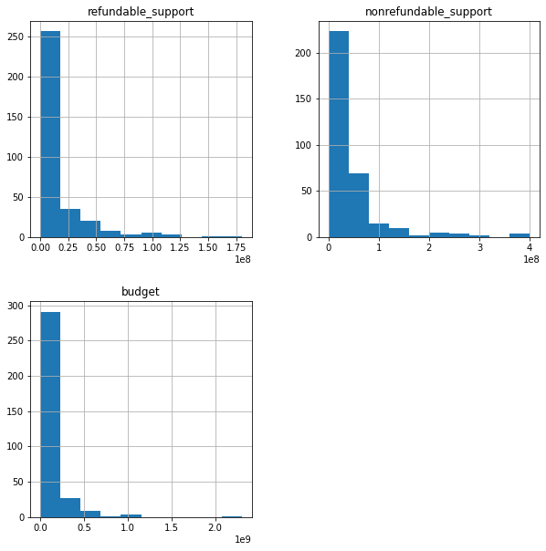

```python
data_m.hist(figsize=(10,10));
```

Во всех случаях имеем Пуассоновское распределение данных

### 1.3. Объеденим два датафрейма в один

Для объединения будем использоввать столбец 'puNumber', но если мы присмотримся внимательно к этому столбцу в датафреймах, то обнаружим что в одном датафрейме он имеет тип object, а в другом тип int. Поэетому необхомимо его сначала привести к единому типу int и затем объединять датафреймы:

Напишем функцию, которая получает строковое значение на входе и возвращает целое число если значение можно конвертировать и NaN, если значение конвертировать нельзя:

```python
def int_or_str(cell_data):
    try:
        return int(cell_data)
    except:
        return np.NaN
```

Применим вышенаписанную функцию к каждому значению в столбце 'puNumber'

```python
data_m['puNumber'] = data_m['puNumber'].apply(int_or_str)
```

Посмотрим сколько строк со значением NaN:

```python
data_m[data_m['puNumber'].isna()]
```

|  | title | puNumber | show_start_date | type | film_studio | production_country | director | producer | age_restriction | refundable_support | nonrefundable_support | budget | financing_source | ratings | genres |
| --- | --- | --- | --- | --- | --- | --- | --- | --- | --- | --- | --- | --- | --- | --- | --- |
| 1797 | Курбан-роман. (История с жертвой) | NaN | 2014-05-15T12:00:00.000Z | Художественный | ФОНД "ИННОВАЦИЯ" | Россия | С.Юзеев | М.Галицкая | «12+» - для детей старше 12 лет | NaN | NaN | NaN | NaN | NaN | NaN |

Строку можно удалить так как у фильма нет прокатного удостоверения, других финансовых данных, как нет и рейтинга.

```python
data_m.drop(1797, axis=0, inplace=True)
```

```python
data_m[data_m['puNumber'].isna()]
```

|  | title | puNumber | show_start_date | type | film_studio | production_country | director | producer | age_restriction | refundable_support | nonrefundable_support | budget | financing_source | ratings | genres |
| --- | --- | --- | --- | --- | --- | --- | --- | --- | --- | --- | --- | --- | --- | --- | --- |

Фильм удален

Теперь конвертируем столбец 'puNumber' в тип int64

```python
data_m['puNumber'] = data_m['puNumber'].astype('int64')
```

```python
data_m.dtypes
```

```
title                     object
puNumber                   int64
show_start_date           object
type                      object
film_studio               object
production_country        object
director                  object
producer                  object
age_restriction           object
refundable_support       float64
nonrefundable_support    float64
budget                   float64
financing_source          object
ratings                   object
genres                    object
dtype: object
```

Теперь можно произвести объединение двух датафреймов в один:

```python
data = data_m.merge(data_s, how='left', on='puNumber', validate='many_to_one')
data
```

|  | title | puNumber | show_start_date | type | film_studio | production_country | director | producer | age_restriction | refundable_support | nonrefundable_support | budget | financing_source | ratings | genres | box_office |
| --- | --- | --- | --- | --- | --- | --- | --- | --- | --- | --- | --- | --- | --- | --- | --- | --- |
| 0 | Открытый простор | 221048915 | 2015-11-27T12:00:00.000Z | Художественный | Тачстоун Пикчерз, Кобальт Пикчерз, Бикон Пикче... | США | Кевин Костнер | Дэвид Валдес, Кевин Костнер, Джейк Эбертс | «18+» - запрещено для детей | NaN | NaN | NaN | NaN | 7.2 | боевик,драма,мелодрама | NaN |
| 1 | Особо важное задание | 111013716 | 2016-09-13T12:00:00.000Z | Художественный | Киностудия "Мосфильм" | СССР | Е.Матвеев | NaN | «6+» - для детей старше 6 лет | NaN | NaN | NaN | NaN | 6.6 | драма,военный | NaN |
| 2 | Особо опасен | 221038416 | 2016-10-10T12:00:00.000Z | Художественный | Юниверсал Пикчерз, Кикстарт Продакшнз, Марк Пл... | США | Тимур Бекмамбетов | Джим Лемли, Джейсон Нетер, Марк Е.Платт, Яйн Смит | «18+» - запрещено для детей | NaN | NaN | NaN | NaN | 6.8 | фантастика,боевик,триллер | NaN |
| 3 | Особо опасен | 221026916 | 2016-06-10T12:00:00.000Z | Художественный | Юниверсал Пикчерз, Кикстарт Продакшнз, Марк Пл... | США | Тимур Бекмамбетов | Джим Лемли, Джейсон Нетер, Марк Е.Платт, Яйн Смит | «18+» - запрещено для детей | NaN | NaN | NaN | NaN | 6.8 | фантастика,боевик,триллер | NaN |
| 4 | Особо опасен | 221030815 | 2015-07-29T12:00:00.000Z | Художественный | Юниверсал Пикчерз, Кикстарт Продакшнз, Марк Пл... | США | Тимур Бекмамбетов | Джим Лемли, Джейсон Нетер, Марк Е.Платт, Яйн Смит | «18+» - запрещено для детей | NaN | NaN | NaN | NaN | 6.8 | фантастика,боевик,триллер | NaN |
| ... | ... | ... | ... | ... | ... | ... | ... | ... | ... | ... | ... | ... | ... | ... | ... | ... |
| 7480 | Сад художника: Американский импрессионизм | 126008019 | 2019-12-23T12:00:00.000Z | Прочие | Севен Артс Продакшнз | Великобритания | Фил Грабски | Фил Грабски | «12+» - для детей старше 12 лет | NaN | NaN | NaN | NaN | NaN | NaN | NaN |
| 7481 | Звериная ярость | 121037819 | 2019-12-24T12:00:00.000Z | Художественный | Дэниел Гродник Продакшнз, Вандерфилм Медиа Кор... | США | Ник Пауэлл | Джефф Боулер, Дэниэл Гродник, Луильо Руис, Брэ... | «16+» - для детей старше 16 лет | NaN | NaN | NaN | NaN | 5.4 | боевик,триллер | NaN |
| 7482 | Щенячий патруль: Скорей спешим на помощь! | 124010819 | 2019-12-28T12:00:00.000Z | Художественный | Никелодеон Анимейшн Студиос, Спин Мастер | США - Канада | Чарльз Е.Бастьен | Дженнифер Додж | «0+» - для любой зрительской аудитории | NaN | NaN | NaN | NaN | NaN | NaN | NaN |
| 7483 | Машины песенки. Серия "Испанские мотивы" | 124010619 | 2019-12-30T12:00:00.000Z | Анимационный | Анимаккорд Лтд., ООО Студия "АНИМАККОРД" | Республика Кипр, Россия | А.Беляев | Д.Ловейко | «0+» - для любой зрительской аудитории | NaN | NaN | NaN | NaN | NaN | NaN | NaN |
| 7484 | Машины песенки. Серия "Когда цветут кактусы" | 124010719 | 2019-12-30T12:00:00.000Z | Анимационный | Анимаккорд Лтд., ООО Студия "АНИМАККОРД" | Республика Кипр, Россия | И.Трусов | Д.Ловейко | «0+» - для любой зрительской аудитории | NaN | NaN | NaN | NaN | 6.3 | комедия,вестерн | NaN |

7485 rows × 16 columns

```python
data.describe(include='all')
```

|  | title | puNumber | show_start_date | type | film_studio | production_country | director | producer | age_restriction | refundable_support | nonrefundable_support | budget | financing_source | ratings | genres | box_office |
| --- | --- | --- | --- | --- | --- | --- | --- | --- | --- | --- | --- | --- | --- | --- | --- | --- |
| count | 7485 | 7.485000e+03 | 7485 | 7485 | 7467 | 7483 | 7476 | 6917 | 7485 | 3.320000e+02 | 3.320000e+02 | 3.320000e+02 | 332 | 6519 | 6510 | 3.158000e+03 |
| unique | 6771 | NaN | 1964 | 8 | 5490 | 950 | 4811 | 5349 | 5 | NaN | NaN | NaN | 3 | 94 | 742 | NaN |
| top | День святого Валентина_ | NaN | 2010-12-17T12:00:00.000Z | Художественный | Киностудия "Мосфильм" | США | О.Семёнова | П.Смирнов | «16+» - для детей старше 16 лет | NaN | NaN | NaN | Министерство культуры | 6.6 | драма | NaN |
| freq | 5 | NaN | 96 | 4519 | 341 | 2172 | 47 | 67 | 2851 | NaN | NaN | NaN | 164 | 312 | 476 | NaN |
| mean | NaN | 1.351966e+08 | NaN | NaN | NaN | NaN | NaN | NaN | NaN | 1.186446e+07 | 4.898099e+07 | 1.272297e+08 | NaN | NaN | NaN | 7.647870e+07 |
| std | NaN | 3.835292e+07 | NaN | NaN | NaN | NaN | NaN | NaN | NaN | 2.491656e+07 | 5.998012e+07 | 1.885883e+08 | NaN | NaN | NaN | 2.403531e+08 |
| min | NaN | 1.811096e+06 | NaN | NaN | NaN | NaN | NaN | NaN | NaN | 0.000000e+00 | 0.000000e+00 | 0.000000e+00 | NaN | NaN | NaN | 0.000000e+00 |
| 25% | NaN | 1.120251e+08 | NaN | NaN | NaN | NaN | NaN | NaN | NaN | 0.000000e+00 | 2.500000e+07 | 4.200000e+07 | NaN | NaN | NaN | 8.623900e+04 |
| 50% | NaN | 1.210155e+08 | NaN | NaN | NaN | NaN | NaN | NaN | NaN | 0.000000e+00 | 3.000000e+07 | 6.864992e+07 | NaN | NaN | NaN | 2.327988e+06 |
| 75% | NaN | 1.240033e+08 | NaN | NaN | NaN | NaN | NaN | NaN | NaN | 1.500000e+07 | 4.037500e+07 | 1.419853e+08 | NaN | NaN | NaN | 2.397967e+07 |
| max | NaN | 2.310011e+08 | NaN | NaN | NaN | NaN | NaN | NaN | NaN | 1.800000e+08 | 4.000000e+08 | 2.305074e+09 | NaN | NaN | NaN | 3.073569e+09 |

### 1.4. Посмотрим на наличие дубликатов в датафрейме

```python
data.duplicated().sum()
```

```
0
```

в датафрейме data дубликаты отсутствуют, но при этом визуальное ознакомление показыевает наличие дубликатов по столбцам. разберемся с этим позже

## 2. Предобработка данных

### 2.1. Заполним пропуски в данных

Посмотрим сколько пропущенных значений по столбцам

```python
pd.DataFrame(round(data.isna().mean()*100)).style.background_gradient('coolwarm')
```

|  | 0 |
| --- | --- |
| title | 0.000000 |
| puNumber | 0.000000 |
| show_start_date | 0.000000 |
| type | 0.000000 |
| film_studio | 0.000000 |
| production_country | 0.000000 |
| director | 0.000000 |
| producer | 8.000000 |
| age_restriction | 0.000000 |
| refundable_support | 96.000000 |
| nonrefundable_support | 96.000000 |
| budget | 96.000000 |
| financing_source | 96.000000 |
| ratings | 13.000000 |
| genres | 13.000000 |
| box_office | 58.000000 |

#### 2.1.1 Столбец 'producer'

Найдем кол-во пропущенных значений

```python
data['producer'].isna().sum()
```

```
568
```

Посмотрим на строки датафрейма, содержащие пропуски в столбце 'producer':

```python
data[data['producer'].isna()]
```

|  | title | puNumber | show_start_date | type | film_studio | production_country | director | producer | age_restriction | refundable_support | nonrefundable_support | budget | financing_source | ratings | genres | box_office |
| --- | --- | --- | --- | --- | --- | --- | --- | --- | --- | --- | --- | --- | --- | --- | --- | --- |
| 1 | Особо важное задание | 111013716 | 2016-09-13T12:00:00.000Z | Художественный | Киностудия "Мосфильм" | СССР | Е.Матвеев | NaN | «6+» - для детей старше 6 лет | NaN | NaN | NaN | NaN | 6.6 | драма,военный | NaN |
| 5 | Остановился поезд | 111013816 | 2016-09-13T12:00:00.000Z | Художественный | Киностудия "Мосфильм" | СССР | В.Абдрашитов | NaN | «6+» - для детей старше 6 лет | NaN | NaN | NaN | NaN | 7.7 | драма | NaN |
| 6 | Любовь и голуби | 111007013 | 2013-10-18T12:00:00.000Z | Художественный | Киностудия "Мосфильм" | СССР | В.Меньшов | NaN | «12+» - для детей старше 12 лет | NaN | NaN | NaN | NaN | 8.3 | мелодрама,комедия | 2700.0 |
| 9 | Отпуск за свой счет | 111019114 | 2014-12-01T12:00:00.000Z | Художественный | Киностудия "Мосфильм", Телевидение ВНР | СССР, Венгрия | В.Титов | NaN | «12+» - для детей старше 12 лет | NaN | NaN | NaN | NaN | 7.8 | мелодрама,комедия | NaN |
| 11 | Ответный ход | 111019014 | 2014-12-01T12:00:00.000Z | Художественный | Киностудия "Мосфильм" | СССР | М.Туманишвили | NaN | «12+» - для детей старше 12 лет | NaN | NaN | NaN | NaN | 7.8 | боевик,драма,приключения | NaN |
| ... | ... | ... | ... | ... | ... | ... | ... | ... | ... | ... | ... | ... | ... | ... | ... | ... |
| 7404 | Отряд специального назначения | 111020419 | 2019-12-01T12:00:00.000Z | Художественный | Свердловская киностудия | СССР | Г.Кузнецов | NaN | «6+» - для детей старше 6 лет | NaN | NaN | NaN | NaN | 7.0 | приключения,военный | NaN |
| 7405 | Назначаешься внучкой | 111020519 | 2019-12-01T12:00:00.000Z | Художественный | Свердловская киностудия | СССР | Я.Лапшин | NaN | «12+» - для детей старше 12 лет | NaN | NaN | NaN | NaN | 7.0 | военный | NaN |
| 7406 | Перед рассветом | 111020619 | 2019-12-01T12:00:00.000Z | Художественный | Свердловская киностудия | СССР | Я.Лапшин | NaN | «16+» - для детей старше 16 лет | NaN | NaN | NaN | NaN | 7.9 | драма,мелодрама | NaN |
| 7407 | Ты помнишь | 111020719 | 2019-12-01T12:00:00.000Z | Художественный | Свердловская киностудия | СССР | О.Николаевский | NaN | «12+» - для детей старше 12 лет | NaN | NaN | NaN | NaN | 7.0 | драма,мелодрама,военный | NaN |
| 7408 | Здесь твой фронт | 111020819 | 2019-12-01T12:00:00.000Z | Художественный | Свердловская киностудия | СССР | Э.Гаврилов | NaN | «16+» - для детей старше 16 лет | NaN | NaN | NaN | NaN | 5.8 | драма,военный | NaN |

568 rows × 16 columns

Информации по продюсерам нет, заменим пропуски значением "нет данных"

```python
data['producer'] = data['producer'].fillna('нет данных')
```

```python
data['producer'].isna().sum()
```

```
0
```

#### 2.1.2 Столбцы 'refundable_support', 'nonrefundable_support', 'budget', 'financing_source'

Сколько пропущенных значений в столбце 'financing_source'

```python
data[data['financing_source'].isna()]
```

|  | title | puNumber | show_start_date | type | film_studio | production_country | director | producer | age_restriction | refundable_support | nonrefundable_support | budget | financing_source | ratings | genres | box_office |
| --- | --- | --- | --- | --- | --- | --- | --- | --- | --- | --- | --- | --- | --- | --- | --- | --- |
| 0 | Открытый простор | 221048915 | 2015-11-27T12:00:00.000Z | Художественный | Тачстоун Пикчерз, Кобальт Пикчерз, Бикон Пикче... | США | Кевин Костнер | Дэвид Валдес, Кевин Костнер, Джейк Эбертс | «18+» - запрещено для детей | NaN | NaN | NaN | NaN | 7.2 | боевик,драма,мелодрама | NaN |
| 1 | Особо важное задание | 111013716 | 2016-09-13T12:00:00.000Z | Художественный | Киностудия "Мосфильм" | СССР | Е.Матвеев | нет данных | «6+» - для детей старше 6 лет | NaN | NaN | NaN | NaN | 6.6 | драма,военный | NaN |
| 2 | Особо опасен | 221038416 | 2016-10-10T12:00:00.000Z | Художественный | Юниверсал Пикчерз, Кикстарт Продакшнз, Марк Пл... | США | Тимур Бекмамбетов | Джим Лемли, Джейсон Нетер, Марк Е.Платт, Яйн Смит | «18+» - запрещено для детей | NaN | NaN | NaN | NaN | 6.8 | фантастика,боевик,триллер | NaN |
| 3 | Особо опасен | 221026916 | 2016-06-10T12:00:00.000Z | Художественный | Юниверсал Пикчерз, Кикстарт Продакшнз, Марк Пл... | США | Тимур Бекмамбетов | Джим Лемли, Джейсон Нетер, Марк Е.Платт, Яйн Смит | «18+» - запрещено для детей | NaN | NaN | NaN | NaN | 6.8 | фантастика,боевик,триллер | NaN |
| 4 | Особо опасен | 221030815 | 2015-07-29T12:00:00.000Z | Художественный | Юниверсал Пикчерз, Кикстарт Продакшнз, Марк Пл... | США | Тимур Бекмамбетов | Джим Лемли, Джейсон Нетер, Марк Е.Платт, Яйн Смит | «18+» - запрещено для детей | NaN | NaN | NaN | NaN | 6.8 | фантастика,боевик,триллер | NaN |
| ... | ... | ... | ... | ... | ... | ... | ... | ... | ... | ... | ... | ... | ... | ... | ... | ... |
| 7480 | Сад художника: Американский импрессионизм | 126008019 | 2019-12-23T12:00:00.000Z | Прочие | Севен Артс Продакшнз | Великобритания | Фил Грабски | Фил Грабски | «12+» - для детей старше 12 лет | NaN | NaN | NaN | NaN | NaN | NaN | NaN |
| 7481 | Звериная ярость | 121037819 | 2019-12-24T12:00:00.000Z | Художественный | Дэниел Гродник Продакшнз, Вандерфилм Медиа Кор... | США | Ник Пауэлл | Джефф Боулер, Дэниэл Гродник, Луильо Руис, Брэ... | «16+» - для детей старше 16 лет | NaN | NaN | NaN | NaN | 5.4 | боевик,триллер | NaN |
| 7482 | Щенячий патруль: Скорей спешим на помощь! | 124010819 | 2019-12-28T12:00:00.000Z | Художественный | Никелодеон Анимейшн Студиос, Спин Мастер | США - Канада | Чарльз Е.Бастьен | Дженнифер Додж | «0+» - для любой зрительской аудитории | NaN | NaN | NaN | NaN | NaN | NaN | NaN |
| 7483 | Машины песенки. Серия "Испанские мотивы" | 124010619 | 2019-12-30T12:00:00.000Z | Анимационный | Анимаккорд Лтд., ООО Студия "АНИМАККОРД" | Республика Кипр, Россия | А.Беляев | Д.Ловейко | «0+» - для любой зрительской аудитории | NaN | NaN | NaN | NaN | NaN | NaN | NaN |
| 7484 | Машины песенки. Серия "Когда цветут кактусы" | 124010719 | 2019-12-30T12:00:00.000Z | Анимационный | Анимаккорд Лтд., ООО Студия "АНИМАККОРД" | Республика Кипр, Россия | И.Трусов | Д.Ловейко | «0+» - для любой зрительской аудитории | NaN | NaN | NaN | NaN | 6.3 | комедия,вестерн | NaN |

7153 rows × 16 columns

Для удобства конвертации в int (копейки не используются), заменим все пропуски в столбцах 'refundable_support', 'nonrefundable_support', 'budget' значением -1, оно не повлияет на дальнейший анализ:

```python
cols = ['refundable_support', 'nonrefundable_support', 'budget']
for col in cols:
    data[col] = data[col].fillna(-1)
```

```python
cols = ['refundable_support', 'nonrefundable_support', 'budget']
for col in cols:
    print(f'Столбец {col} пропусков {data[col].isna().sum()}')
```

```
Столбец refundable_support пропусков 0
Столбец nonrefundable_support пропусков 0
Столбец budget пропусков 0
```

Конвертируем столбцы в int:

```python
cols = ['refundable_support', 'nonrefundable_support', 'budget']
for col in cols:
    data[col] = data[col].astype(int)
    print(f'Столбец {col} имеет тип {data[col].dtypes}')
```

```
Столбец refundable_support имеет тип int64
Столбец nonrefundable_support имеет тип int64
Столбец budget имеет тип int64
```

В столбце 'financing_source' заменим значения NaN на 'нет данных' - столбец категориальный и в нем должны быть категории. 'нет данных' - будет одной из них.

```python
data['financing_source'] = data['financing_source'].fillna('нет данных')
```

```python
data['financing_source'].isna().sum()
```

```
0
```

Пропусков в столбце 'financing_source' нет

#### 2.1.3 Столбец 'ratings'

Сколько пропущенных значений в столбце:

```python
data['ratings'].isna().sum()
```

```
966
```

Рейтинг фильма лежит в пределах от 0 до 10, где 0 минимальное значение, 10 - макисмальное. При отсутствии рейтинга его можно заменить на нулевое значение. Затем мы сможем сконвертировать столбец в float тип, что более правильно будет отражать его сущность.

```python
data['ratings'] = data['ratings'].fillna(0)
```

```python
data['ratings'].isna().sum()
```

```
0
```

Преобразуем 'ratings' в тип float

```python
data['ratings'].unique()
```

```
array(['7.2', '6.6', '6.8', '7.7', '8.3', '8.0', '7.8', '8.1', '7.1',
       '6.0', '7.4', '5.8', '8.7', '6.3', '6.9', '5.0', '4.3', '7.3',
       '7.0', '6.4', 0, '8.2', '7.5', '6.7', '7.9', '5.9', '6.2', '5.6',
       '6.5', '2.4', '7.6', '6.1', '8.6', '8.5', '8.8', '5.5', '5.1',
       '5.7', '5.4', '99%', '4.4', '4.5', '5.3', '4.1', '8.4', '2.6',
       '3.8', '4.6', '4.8', '4.0', '3.0', '1.6', '4.2', '5.2', '4.7',
       '4.9', '3.9', '2.7', '3.3', '2.9', '28%', '3.7', '1.4', '3.1',
       '97%', '3.5', '3.2', '2.8', '1.5', '2.1', '2.5', '9.2', '3.4',
       '1.1', '3.6', '83%', '64%', '91%', '94%', '62%', '79%', '90%',
       '19%', '88%', '1.0', '89%', '1.3', '1.9', '1.8', '1.2', '1.7',
       '9.0', '98%', '8.9', '9.1'], dtype=object)
```

Мы видим, что среди значений столбца присутствуют "странные" значения с %. Посмотрим на них поближе:

```python
data[data['ratings'].str.contains('%', regex=True, na=False)]
```

|  | title | puNumber | show_start_date | type | film_studio | production_country | director | producer | age_restriction | refundable_support | nonrefundable_support | budget | financing_source | ratings | genres | box_office |
| --- | --- | --- | --- | --- | --- | --- | --- | --- | --- | --- | --- | --- | --- | --- | --- | --- |
| 259 | Прошлое | 221030715 | 2015-07-29T12:00:00.000Z | Художественный | 20 Сенчюри Фокс де Архентина, Чемо, ЭйчБи Филм... | Аргентина - Бразилия | Эктор Бабенко | Эктор Бабенко, Оскар Крамер, Хуго Сидмэн | «16+» - для детей старше 16 лет | -1 | -1 | -1 | нет данных | 99% | ужасы,триллер,драма | NaN |
| 811 | От винта! | 114000212 | 2012-08-06T12:00:00.000Z | Анимационный | ЗАО "Продюсерский центр "Парадиз" | Россия | О.Лопато | Г.Нерсисян, А.Манасарян, А.Нерсесян | «12+» - для детей старше 12 лет | -1 | -1 | -1 | нет данных | 28% | детский,приключения,комедия | 1.740000e+03 |
| 1053 | Песочный человек | 121029212 | 2012-11-29T12:00:00.000Z | Художественный | Спотлайт Медиа Продакшн | Швейцария | Питер Луизи | Дэвид Луизи, Питер Луизи | «16+» - для детей старше 16 лет | -1 | -1 | -1 | нет данных | 97% | ужасы,фантастика,фэнтези | NaN |
| 1341 | Сказка о добре и Вре | 111008913 | 2013-11-15T12:00:00.000Z | Художественный | НП "Студия игрового кино "Лик" | Россия | Е.Шиляева | К.Терещенко | «6+» - для детей старше 6 лет | -1 | -1 | -1 | нет данных | 99% | триллер,драма,детектив | NaN |
| 1804 | Спираль. | 111001014 | 2014-01-30T12:00:00.000Z | Художественный | ООО "Компания Питон" | Россия | А.Волгин | Е.Ковалева | «12+» - для детей старше 12 лет | -1 | -1 | -1 | нет данных | 99% | аниме,мультфильм,ужасы | 4.295000e+03 |
| 1873 | Короткие истории о любви 2 | 121002615 | 2015-02-13T12:00:00.000Z | Художественный | Кавиар, Курт 13, СтритЛайт Филмз, Нэйер Дойче ... | Нидерланды - США - Германия - Канада - Франция... | Мэтью Аувро, Лео Брайдл, Бен Бренд, Ден Кларк,... | Мэри Пэт Бентел, Бен Бренд, Сиара Гиллан, Джор... | «18+» - запрещено для детей | -1 | -1 | -1 | нет данных | 83% | NaN | 1.429859e+06 |
| 1898 | Золушка /По сказке Шарля Перро/. Холодное торж... | 121003615 | 2015-02-27T12:00:00.000Z | Художественный | Женр Филмз, Уолт Дисней Пикчерз | США | Кеннет Брана | Дэвид Бэррон, Саймон Кинберг, Эллисон Ширмур | «6+» - для детей старше 6 лет | -1 | -1 | -1 | нет данных | 64% | мюзикл,фэнтези,мелодрама | 5.287326e+08 |
| 2125 | Поездка к матери | 111002015 | 2015-03-02T12:00:00.000Z | Художественный | ЗАО "Киностудия "М"-Фильм" | Россия | М.Косырев-Нестеров | М.Косырев-Нестеров | «16+» - для детей старше 16 лет | -1 | -1 | -1 | нет данных | 91% | драма,семейный | 0.000000e+00 |
| 2145 | Главный | 111003415 | 2015-03-27T12:00:00.000Z | Художественный | ООО "Киностудия "МАСТЕР" | Россия | Ю.Кара | Ю.Кара | «6+» - для детей старше 6 лет | 0 | 10000000 | 40000000 | Министерство культуры | 94% | фантастика,боевик,комедия | 3.347500e+05 |
| 2437 | Самый рыжий Лис | 111012715 | 2015-07-30T12:00:00.000Z | Художественный | ООО "Продюсерский центр "Ленфильм" | Россия | А.Стреляная | А.Котелевский, Э.Пичугин | «6+» - для детей старше 6 лет | -1 | -1 | -1 | нет данных | 62% | фэнтези,семейный | NaN |
| 2679 | Год Белого Слона | 111003915 | 2015-04-08T12:00:00.000Z | Художественный | ООО "Творческое объединение ЮГ" | Россия | Ю.Грымов | П.Поляков | «6+» - для детей старше 6 лет | -1 | -1 | -1 | нет данных | 79% | семейный | NaN |
| 3138 | Я умею вязать | 111019615 | 2015-11-27T12:00:00.000Z | Художественный | ООО "Белое Зеркало" | Россия | Н.Степанова при участии С.Иванова | С.Кикнавелидзе, Д.Улюкаев | «16+» - для детей старше 16 лет | 0 | 4700000 | 14462464 | Министерство культуры | 90% | драма | 8.013700e+05 |
| 3430 | Наурыз | 131000217 | 2017-03-09T12:00:00.000Z | Художественный | Эс Джи | Республика Казахстан | Аскар Бисембин | Олег Головашкин, Алмас Султангазин | «12+» - для детей старше 12 лет | -1 | -1 | -1 | нет данных | 19% | комедия | 3.796000e+04 |
| 3438 | Семь диких историй | 126005916 | 2016-11-28T12:00:00.000Z | Прочие | Макс Бэйкер, Джон Е.Брайан, Пьер-Луи Гарнон, ... | США - Пуэрто-Рико - Франция | М.Бэйкер, Д.Е.Брайант, Д.Рондот, Я.Серсар, Д.С... | М.Бэйкер, Д.Е.Брайан, П.-Л.Гарнон, М.Х.Дельгад... | «18+» - запрещено для детей | -1 | -1 | -1 | нет данных | 88% | NaN | 1.025937e+06 |
| 3445 | Короткие истории о любви - 4 | 126006316 | 2016-12-30T12:00:00.000Z | Прочие | Нетворг Айлэнд Телевижн, Магнетфильм, Шорткатс... | Великобритания - Аргентина - США - Франция - Р... | Д.Адар, П.Антохин, М.Биасин, А.Бурунова, К.Кол... | Д.Адар, Д.Амсон, П.Антохин, А.Армстронг, С.Бил... | «18+» - запрещено для детей | -1 | -1 | -1 | нет данных | 83% | NaN | 2.266408e+06 |
| 3513 | Чужой дом | 111015516 | 2016-09-14T12:00:00.000Z | Художественный | ООО "Лига Продакшн" | Россия, Грузия, Хорватия, Испания | Р.Глурджидзе | З.Магалашвили, К.Гечмен-Вальдек, Н.Горшкова | «12+» - для детей старше 12 лет | -1 | -1 | -1 | нет данных | 91% | драма | NaN |
| 3584 | Машины Страшилки. Серия "Жутчайшая повесть о п... | 114003916 | 2016-12-09T12:00:00.000Z | Анимационный | ООО Студия "АНИМАККОРД", АНИМАККОРД ЛТД. | Россия, Республика Кипр | Д.Червяцов | Д.Ловейко, О.Кузовков | «0+» - для любой зрительской аудитории | -1 | -1 | -1 | нет данных | 97% | мультфильм,ужасы,фэнтези | NaN |
| 3785 | Охотники | 111017816 | 2016-02-06T12:00:00.000Z | Художественный | Селиверстов Александр Александрович | Россия | А.Селиверстов | Е.Тарковская, Т.Лагода, Д.Степанян | «16+» - для детей старше 16 лет | -1 | -1 | -1 | нет данных | 89% | фантастика,комедия,боевик | 8.284000e+04 |
| 3947 | Круиз. | 211038210 | 2010-09-03T12:00:00.000Z | Художественный | ООО "ЮНАЙТЕД МУЛЬТИМЕДИА ПРОДЖЕКТС" | Россия | И.Ромащенко | Р.Атамалибеков | «16+» - для детей старше 16 лет | -1 | -1 | -1 | нет данных | 97% | приключения,комедия,фэнтези | NaN |
| 5331 | Добыча. | 121009411 | 2011-06-15T12:00:00.000Z | Художественный | Афтер Дарк Филмз | США | Патрик Сиверсен | Закари Ти Брайан, Кристофер | «18+» - запрещено для детей | -1 | -1 | -1 | нет данных | 88% | фантастика,боевик,триллер | NaN |
| 5454 | Вечный холод | 111006417 | 2017-08-28T12:00:00.000Z | Художественный | ЗАО "Производственный комплекс "ГЛАВКИНО", ООО... | Россия | А.Мигачев | И.Бачурин | «18+» - запрещено для детей | -1 | -1 | -1 | нет данных | 83% | фэнтези,боевик,триллер | NaN |
| 5820 | Свинья | 121007018 | 2018-04-11T12:00:00.000Z | Художественный | Дарк Прекёрсор Продакшен, Филмиран, Хедейт Филм | Иран | Мани Хагиги | Мани Хагиги | «18+» - запрещено для детей | -1 | -1 | -1 | нет данных | 94% | триллер,драма | 1.587222e+06 |
| 5909 | Мира | 112000118 | 2018-06-04T12:00:00.000Z | Документальный | ООО "Компания "Новые люди" | Россия | Д.Шабаев | Н.Мокрицкая | «18+» - запрещено для детей | -1 | -1 | -1 | нет данных | 94% | драма | NaN |
| 6425 | Памятные даты России. Партизаны и подпольщики | 112013018 | 2018-11-28T12:00:00.000Z | Документальный | ООО Кинокомпания "Вектор" | Россия | Н.Иванова, А.Кузнецова | В.Коханович | «12+» - для детей старше 12 лет | -1 | -1 | -1 | нет данных | 91% | драма,биография | NaN |
| 6615 | ОТ ВОЙНЫ ДО НАШИХ ДНЕЙ | 111026518 | 2019-01-21T12:00:00.000Z | Художественный | ИП Вайсман Анатолий Александрович | Россия | А.Сазонов, Е.Климович, А.Коломеец, С.Черникова... | Д.Руюежин, Л.Пятницкая, Д.Колеров, Э.Ким, А.Хомич | «12+» - для детей старше 12 лет | -1 | -1 | -1 | нет данных | 98% | фантастика,боевик | NaN |
| 6736 | Колесо времени | 111003219 | 2019-03-01T12:00:00.000Z | Художественный | ООО "БестМедиа" | Россия | Б.Куломзин | Б.Куломзин | «6+» - для детей старше 6 лет | -1 | -1 | -1 | нет данных | 98% | фэнтези,приключения | 3.499200e+04 |
| 6881 | Животные рядом со Святыми | 112003719 | 2019-05-03T12:00:00.000Z | Документальный | ООО "Кинопрограмма "XXI век" | Россия | Т.Мирошник | В.Есинов, Е.Калинина | «0+» - для любой зрительской аудитории | -1 | -1 | -1 | нет данных | 99% | криминал,драма | NaN |
| 7158 | Анна Каренина. Интимный дневник | 111013919 | 2019-10-23T12:00:00.000Z | Художественный | ООО "РТВ" | Россия | Ю.Грымов | Ю.Грымов | «16+» - для детей старше 16 лет | -1 | -1 | -1 | нет данных | 79% | драма | 1.828825e+05 |
| 7276 | Добыча | 121028319 | 2019-10-03T12:00:00.000Z | Художественный | Блумхаус Продакшнз, Хайд Парк Интертейнмент, Т... | США | Франк Халфун | Ашок Амритрадж, Джейсон Блум, Трэвис Клафф | «16+» - для детей старше 16 лет | -1 | -1 | -1 | нет данных | 88% | фантастика,боевик,триллер | 4.416590e+06 |

Никакой связи между цифрами со знаком процента и самими фильмами нет(я проверил рейтинг нескольких фильмов на кинопоиске), можем преобразовать это значение в 0

Напишем функцию, которая принимает строку на вход и возвращает 0, если в строке был обнаружен знак '%', в противном случае возвращает просто саму строку:

```python
def percent_in_string(string):
    if isinstance(string, int):
        return string
    if string.find('%') > 0:
        return 0
    else:
        return string
```

Применим ее к столбцу

```python
data['ratings'] = data['ratings'].apply(percent_in_string)
```

Теперь нам ничто не мешает преобразовать столбец в числовой:

```python
data['ratings'] = pd.to_numeric(data['ratings'])
```

```python
data['ratings'].dtypes
```

```
dtype('float64')
```

#### 2.1.4 Столбец 'genres'

Посмотрим на пропущенные значения:

```python
data[data['genres'].isna()]
```

|  | title | puNumber | show_start_date | type | film_studio | production_country | director | producer | age_restriction | refundable_support | nonrefundable_support | budget | financing_source | ratings | genres | box_office |
| --- | --- | --- | --- | --- | --- | --- | --- | --- | --- | --- | --- | --- | --- | --- | --- | --- |
| 43 | Мемуары гейши (по роману Артура Голдена) | 121000606 | 2012-12-14T12:00:00.000Z | Художественный | Коламбия Пикчерз Корпорейшн, ДримУоркс ЭсКейДж... | США | Роб Маршалл | Стивен Спилберг, Люси Фишер, Дуглас Уик, Джон ... | «12+» - для детей старше 12 лет | -1 | -1 | -1 | нет данных | 0.0 | NaN | NaN |
| 150 | Жди меня | 111013615 | 2015-08-25T12:00:00.000Z | Художественный | Киностудия "Мосфильм" | СССР | А.Столпер, Б.Иванов | нет данных | «6+» - для детей старше 6 лет | -1 | -1 | -1 | нет данных | 0.0 | NaN | NaN |
| 154 | Дом из песка и тумана (по книге Андре Дюбуи III) | 221037813 | 2013-10-25T12:00:00.000Z | Художественный | Кобальт Пикчерз | США | Вадим Перельман | Майкл Лондон | «16+» - для детей старше 16 лет | -1 | -1 | -1 | нет данных | 0.0 | NaN | NaN |
| 159 | Жемчужная девушка | 224011014 | 2014-08-28T12:00:00.000Z | Художественный | Чешское телевидение,Студия "Три брата" агентск... | Чехия | Владимир Дрга | нет данных | «0+» - для любой зрительской аудитории | -1 | -1 | -1 | нет данных | 0.0 | NaN | NaN |
| 227 | Полустанок | 111026714 | 2014-12-24T12:00:00.000Z | Художественный | Киностудия "Мосфильм" | СССР | Б.Барнет | нет данных | «12+» - для детей старше 12 лет | -1 | -1 | -1 | нет данных | 0.0 | NaN | NaN |
| ... | ... | ... | ... | ... | ... | ... | ... | ... | ... | ... | ... | ... | ... | ... | ... | ... |
| 7478 | Эколав | 111023219 | 2019-12-26T12:00:00.000Z | Художественный | ВГИК | Россия | Д.Григорьев | ВГИК | «18+» - запрещено для детей | -1 | -1 | -1 | нет данных | 0.0 | NaN | NaN |
| 7479 | Акрам Хан: Родом из Карри Хауса | 126007919 | 2019-12-23T12:00:00.000Z | Прочие | Свон Филмз | Великобритания | Ник Пойнц | Поппи Бегум, Ник Пойнц | «12+» - для детей старше 12 лет | -1 | -1 | -1 | нет данных | 0.0 | NaN | 219569.0 |
| 7480 | Сад художника: Американский импрессионизм | 126008019 | 2019-12-23T12:00:00.000Z | Прочие | Севен Артс Продакшнз | Великобритания | Фил Грабски | Фил Грабски | «12+» - для детей старше 12 лет | -1 | -1 | -1 | нет данных | 0.0 | NaN | NaN |
| 7482 | Щенячий патруль: Скорей спешим на помощь! | 124010819 | 2019-12-28T12:00:00.000Z | Художественный | Никелодеон Анимейшн Студиос, Спин Мастер | США - Канада | Чарльз Е.Бастьен | Дженнифер Додж | «0+» - для любой зрительской аудитории | -1 | -1 | -1 | нет данных | 0.0 | NaN | NaN |
| 7483 | Машины песенки. Серия "Испанские мотивы" | 124010619 | 2019-12-30T12:00:00.000Z | Анимационный | Анимаккорд Лтд., ООО Студия "АНИМАККОРД" | Республика Кипр, Россия | А.Беляев | Д.Ловейко | «0+» - для любой зрительской аудитории | -1 | -1 | -1 | нет данных | 0.0 | NaN | NaN |

975 rows × 16 columns

Наиболее часто появляющееся значение в столбце 'genres':

```python
data.mode()['genres']
```

```
0    драма
1      NaN
Name: genres, dtype: object
```

Заполним пропуски наиболее повторяющимся значением(драма):

```python
most = data.mode()['genres'][0]
data.fillna({'genres': most}, inplace=True)
```

```python
data['genres'].isna().sum()
```

```
0
```

Пропуски отсутствуют

#### 2.1.5 Столбец 'box_office'

Посмотрим на данные поближе:

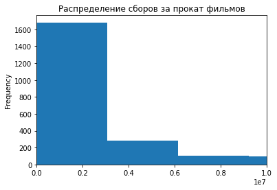

```python
data['box_office'].plot(kind='hist', bins=1000, xlim=(0, 1e7), title='Распределение сборов за прокат фильмов');
```

Узнаем кол-во пропусков:

```python
data['box_office'].isna().sum()
```

```
4327
```

Для преобразования столбца 'box_office' в int (копейки не используются), необходимо заменить пропуски значением, которое бы было int и не влияло на дальнейший анализ, примем за это значение -1:

```python
data['box_office'] = data['box_office'].fillna(-1)
```

```python
data['box_office'].isna().sum()
```

```
0
```

Конвертируем в int

```python
data['box_office'] = data['box_office'].astype(int)
```

```python
data.dtypes
```

```
title                     object
puNumber                   int64
show_start_date           object
type                      object
film_studio               object
production_country        object
director                  object
producer                  object
age_restriction           object
refundable_support         int64
nonrefundable_support      int64
budget                     int64
financing_source          object
ratings                  float64
genres                    object
box_office                 int64
dtype: object
```

Посмотрим есть ли еще пропуски

```python
pd.DataFrame(round(data.isna().mean()*100)).style.background_gradient('coolwarm')
```

|  | 0 |
| --- | --- |
| title | 0.000000 |
| puNumber | 0.000000 |
| show_start_date | 0.000000 |
| type | 0.000000 |
| film_studio | 0.000000 |
| production_country | 0.000000 |
| director | 0.000000 |
| producer | 0.000000 |
| age_restriction | 0.000000 |
| refundable_support | 0.000000 |
| nonrefundable_support | 0.000000 |
| budget | 0.000000 |
| financing_source | 0.000000 |
| ratings | 0.000000 |
| genres | 0.000000 |
| box_office | 0.000000 |

### 2.2. Подготовка данных для анализа

#### 2.2.1 Конвертация столбца 'show_start_date'

```python
data['show_start_date'][0:5]
```

```
0    2015-11-27T12:00:00.000Z
1    2016-09-13T12:00:00.000Z
2    2016-10-10T12:00:00.000Z
3    2016-06-10T12:00:00.000Z
4    2015-07-29T12:00:00.000Z
Name: show_start_date, dtype: object
```

```python
data['show_start_date'] = pd.to_datetime(data['show_start_date'], format='%Y-%m-%d')
```

```python
data['show_start_date'].dtypes
```

```
datetime64[ns, UTC]
```

```python
data.head()
```

|  | title | puNumber | show_start_date | type | film_studio | production_country | director | producer | age_restriction | refundable_support | nonrefundable_support | budget | financing_source | ratings | genres | box_office |
| --- | --- | --- | --- | --- | --- | --- | --- | --- | --- | --- | --- | --- | --- | --- | --- | --- |
| 0 | Открытый простор | 221048915 | 2015-11-27 12:00:00+00:00 | Художественный | Тачстоун Пикчерз, Кобальт Пикчерз, Бикон Пикче... | США | Кевин Костнер | Дэвид Валдес, Кевин Костнер, Джейк Эбертс | «18+» - запрещено для детей | -1 | -1 | -1 | нет данных | 7.2 | боевик,драма,мелодрама | -1 |
| 1 | Особо важное задание | 111013716 | 2016-09-13 12:00:00+00:00 | Художественный | Киностудия "Мосфильм" | СССР | Е.Матвеев | нет данных | «6+» - для детей старше 6 лет | -1 | -1 | -1 | нет данных | 6.6 | драма,военный | -1 |
| 2 | Особо опасен | 221038416 | 2016-10-10 12:00:00+00:00 | Художественный | Юниверсал Пикчерз, Кикстарт Продакшнз, Марк Пл... | США | Тимур Бекмамбетов | Джим Лемли, Джейсон Нетер, Марк Е.Платт, Яйн Смит | «18+» - запрещено для детей | -1 | -1 | -1 | нет данных | 6.8 | фантастика,боевик,триллер | -1 |
| 3 | Особо опасен | 221026916 | 2016-06-10 12:00:00+00:00 | Художественный | Юниверсал Пикчерз, Кикстарт Продакшнз, Марк Пл... | США | Тимур Бекмамбетов | Джим Лемли, Джейсон Нетер, Марк Е.Платт, Яйн Смит | «18+» - запрещено для детей | -1 | -1 | -1 | нет данных | 6.8 | фантастика,боевик,триллер | -1 |
| 4 | Особо опасен | 221030815 | 2015-07-29 12:00:00+00:00 | Художественный | Юниверсал Пикчерз, Кикстарт Продакшнз, Марк Пл... | США | Тимур Бекмамбетов | Джим Лемли, Джейсон Нетер, Марк Е.Платт, Яйн Смит | «18+» - запрещено для детей | -1 | -1 | -1 | нет данных | 6.8 | фантастика,боевик,триллер | -1 |

#### 2.2.2 Столбец 'type'

Посмотрим какие уникальные значения входят в столбец

```python
data['type'].unique()
```

```
array(['Художественный', 'Анимационный', 'Прочие', 'Документальный',
       'Научно-популярный', ' Художественный', ' Анимационный',
       'Музыкально-развлекательный'], dtype=object)
```

Мы видим, что некоторые категории повторяются и разница в повторяющихся - пробелы, уберем их:

```python
data['type'] = data['type'].str.strip()
```

```python
data['type'].unique()
```

```
array(['Художественный', 'Анимационный', 'Прочие', 'Документальный',
       'Научно-популярный', 'Музыкально-развлекательный'], dtype=object)
```

Повторяющихся категорий нет

#### 2.2.3 Столбец 'production_country'

Проверим на пропуски

```python
data['production_country'].isna().sum()
```

```
2
```

```python
data[data['production_country'].isna()]
```

|  | title | puNumber | show_start_date | type | film_studio | production_country | director | producer | age_restriction | refundable_support | nonrefundable_support | budget | financing_source | ratings | genres | box_office |
| --- | --- | --- | --- | --- | --- | --- | --- | --- | --- | --- | --- | --- | --- | --- | --- | --- |
| 3185 | Детский юмористический киножурнал "Ералаш. Ну ... | 111001216 | 2016-02-09 12:00:00+00:00 | Художественный | ООО "Продюсерский центр ЕРАЛАШ" | NaN | Р.Светлов, И.Магитон, А.Арутюнян, Л.Мирский, А... | ООО "Продюсерский центр ЕРАЛАШ" | «0+» - для любой зрительской аудитории | -1 | -1 | -1 | нет данных | 7.2 | детский,комедия | 194527 |
| 4440 | Мульт личности. Выпуск 5 | 214000410 | 2010-01-25 12:00:00+00:00 | Художественный | NaN | NaN | NaN | нет данных | «0+» - для любой зрительской аудитории | -1 | -1 | -1 | нет данных | 4.0 | мультфильм,комедия | -1 |

Заменим пропущенные значения на 'Россия', оба мультфильма произведены в России:

```python
data['production_country'] = data['production_country'].fillna('Россия')
```

```python
data['production_country'].isna().sum()
```

```
0
```

```python
 len(data['production_country'].unique())
```

```
950
```

```python
data['production_country'] = data['production_country'].str.strip()
```

```python
len(data['production_country'].unique())
```

```
934
```

```python
data['production_country'].unique()
```

```
array(['США', 'СССР', 'Франция', 'СССР, Венгрия',
       'Германия-Великобритания', 'Великобритания - Италия',
       'Чехословакия', 'США - Франция - Турция', 'Новая Зеландия',
       'Канада - Франция - Испания', 'США-Германия',
       'США - Великобритания', 'Великобритания', 'США - Германия',
       'Франция - Мексика - США', 'Россия, Казахстан, США',
       'СССР, Швеция', 'СССР, Франция, Англия, Куба, ГДР', 'Германия',
       'Великобритания-США-Германия-КНР',
       'СССР, ЧССР, Западный Берлин, ПНР', 'СССР, Италия', 'Гонконг, КНР',
       'США - Франция', 'США - Япония - Франция - Великобритания',
       'Гонконг - Сингапур - Таиланд - Великобритания', 'США-Канада',
       'Франция - Италия - Великобритания - США', 'Франция - США',
       'Ирландия-Великобритания-Германия', 'Чехия', 'США-Австралия',
       'СССР, Финляндия', 'США-Франция-Великобритания-Австрия',
       'США - Бельгия', 'США - Ирландия - Великобритания',
       'Великобритания - США',
       'Люксембург - Нидерланды - Испания - Великобритания - США - Италия',
       'Великобритания - Франция - США', 'Новая Зеландия - США',
       'США - Великобритания - Чехия',
       'Канада - Франция - Великобритания', 'Ирландия',
       'Великобритания - Германия - США',
       'США - Франция - Великобритания', 'Япония', 'СССР, Польша',
       'Франция - Испания', 'Канада-Франция', 'Германия - Италия - США',
       'Аргентина - Бразилия', 'Дания - Швейцария - Бельгия - Франция',
       'США - Испания', 'Германия - США',
       'Франция - Австрия - Германия - Италия - США', 'Австрия',
       'США - Канада - Германия', 'США - Канада',
       'СССР - Швейцария - Франция', 'Россия - Казахстан', 'Гонконг',
       'Италия', 'США - ОАЭ', 'Россия',
       'США - Франция - Испания - Великобритания',
       'Великобритания - Франция', 'США-Италия-Испания-Аргентина',
       'Франция-Великобритания', 'КНР - Гонконг',
       'Франция - Италия - Швейцария', 'США - Новая Зеландия',
       'Франция - Бельгия', 'КНР', 'Германия - Великобритания - Австрия',
       'Великобритания - Израиль - Франция - Япония - США', 'Швеция',
       'Испания', 'Дания', 'Франция - Бельгия - Люксембург',
       'США - Индия - ОАЭ',
       'Германия-Канада-Великобритания-Швейцария-Франция',
       'Мексика - Чили', 'Аргентина', 'Бразилия', 'Чили', 'Австралия',
       'Португалия - Франция', 'США - ЮАР', 'Исландия-Ирландия-Германия',
```

[output cut: 470 more lines]

```
       'Франция - Финляндия', 'Колумбия - США',
       'Великобритания, Франция, Бельгия', 'Норвегия - Нидерланды',
       'Великобритания, Канада, США', 'Япония, Великобритания',
       'Италия - Бельгия - Франция', 'Россия, Бельгия, Финляндия',
       'США, Украина', 'Франция, Норвегия',
       'Великобритания, Южная Корея, Канада, США, Индия, Китай, Япония',
       'Канада - Норвегия', 'Республика Кипр-Россия', 'Германия, Россия',
       'Польша - Франция - Испания - Бразилия - Швеция',
       'Австрия, Великобритания, Германия', 'Франция - Сенегал - Бельгия',
       'Франция, Бельгия, Люксембург', 'Финляндия, Латвия', 'Пакистан',
       'Германия, Франция, США', 'Германия - Великобритания - США',
       'КНР - Франция', 'Дания, Норвегия, Швеция, Исландия',
       'Республика Кипр, США, Россия', 'Новая Зеландия - КНР',
       'Дания - Канада - Швеция - Франция - Германия - Великобритания - США'],
      dtype=object)
```

Мы видим, что есть повторения: разное написание стран, разные разделители, наличие или отстутсвие пробелов. Произведем замены всех двойников и получим единое написание:

```python
repl_list = [(' -', ','), ('-', ','), (' ', ''), ('Чехословакия', 'ЧССР'), ('ПНР', 'Польша'), ('Германия','ФРГ'), ('ЧешскаяРеспублика', 'Чехия'), ('РеспубликаКипр','Кипр'), ('КНР','Китай')]
for rep in repl_list:
    data['production_country'] = data['production_country'].str.replace(rep[0], rep[1])
```

```python
data['production_country'].unique()
```

```
array(['США', 'СССР', 'Франция', 'СССР,Венгрия', 'ФРГ,Великобритания',
       'Великобритания,Италия', 'ЧССР', 'США,Франция,Турция',
       'НоваяЗеландия', 'Канада,Франция,Испания', 'США,ФРГ',
       'США,Великобритания', 'Великобритания', 'Франция,Мексика,США',
       'Россия,Казахстан,США', 'СССР,Швеция',
       'СССР,Франция,Англия,Куба,ГДР', 'ФРГ',
       'Великобритания,США,ФРГ,Китай', 'СССР,ЧССР,ЗападныйБерлин,Польша',
       'СССР,Италия', 'Гонконг,Китай', 'США,Франция',
       'США,Япония,Франция,Великобритания',
       'Гонконг,Сингапур,Таиланд,Великобритания', 'США,Канада',
       'Франция,Италия,Великобритания,США', 'Франция,США',
       'Ирландия,Великобритания,ФРГ', 'Чехия', 'США,Австралия',
       'СССР,Финляндия', 'США,Франция,Великобритания,Австрия',
       'США,Бельгия', 'США,Ирландия,Великобритания', 'Великобритания,США',
       'Люксембург,Нидерланды,Испания,Великобритания,США,Италия',
       'Великобритания,Франция,США', 'НоваяЗеландия,США',
       'США,Великобритания,Чехия', 'Канада,Франция,Великобритания',
       'Ирландия', 'Великобритания,ФРГ,США', 'США,Франция,Великобритания',
       'Япония', 'СССР,Польша', 'Франция,Испания', 'Канада,Франция',
       'ФРГ,Италия,США', 'Аргентина,Бразилия',
       'Дания,Швейцария,Бельгия,Франция', 'США,Испания', 'ФРГ,США',
       'Франция,Австрия,ФРГ,Италия,США', 'Австрия', 'США,Канада,ФРГ',
       'СССР,Швейцария,Франция', 'Россия,Казахстан', 'Гонконг', 'Италия',
       'США,ОАЭ', 'Россия', 'США,Франция,Испания,Великобритания',
       'Великобритания,Франция', 'США,Италия,Испания,Аргентина',
       'Франция,Великобритания', 'Китай,Гонконг',
       'Франция,Италия,Швейцария', 'США,НоваяЗеландия', 'Франция,Бельгия',
       'Китай', 'ФРГ,Великобритания,Австрия',
       'Великобритания,Израиль,Франция,Япония,США', 'Швеция', 'Испания',
       'Дания', 'Франция,Бельгия,Люксембург', 'США,Индия,ОАЭ',
       'ФРГ,Канада,Великобритания,Швейцария,Франция', 'Мексика,Чили',
       'Аргентина', 'Бразилия', 'Чили', 'Австралия', 'Португалия,Франция',
       'США,ЮАР', 'Исландия,Ирландия,ФРГ', 'США,Индонезия', 'ЮжнаяКорея',
       'Мексика,Испания,Дания,США', 'Франция,Италия',
       'США,Венгрия,Великобритания', 'Бельгия,Франция,Италия',
       'Чехия,ФРГ', 'ФРГ,Франция', 'США,Нидерланды', 'Украина',
       'Великобритания,ФРГ', 'США,Франция,Испания', 'Италия,Франция',
       'Канада', 'Швеция,Франция,Дания', 'ФРГ,Франция,Польша',
       'Франция,Великобритания,ФРГ',
       'США,Бразилия,Франция,Австралия,Великобритания,ФРГ', 'ФРГ,Австрия',
```

[output cut: 347 more lines]

```
       'Франция,НоваяЗеландия', 'Канада,США,Норвегия', 'Италия,Испания',
       'Испания,ФРГ,Нидерланды', 'Бразилия,США,Китай',
       'Великобритания,ФРГ,Дания,США', '2019',
       'Италия,Фрация,Бразилия,ФРГ', 'Норвегия,Швеция,Россия',
       'Сша,Канада', 'Бельгия,Канада', 'Франция,Финляндия',
       'Колумбия,США', 'Норвегия,Нидерланды', 'Италия,Бельгия,Франция',
       'Россия,Бельгия,Финляндия', 'Франция,Норвегия',
       'Великобритания,ЮжнаяКорея,Канада,США,Индия,Китай,Япония',
       'Канада,Норвегия', 'Польша,Франция,Испания,Бразилия,Швеция',
       'Австрия,Великобритания,ФРГ', 'Франция,Сенегал,Бельгия',
       'Финляндия,Латвия', 'Пакистан', 'ФРГ,Франция,США',
       'ФРГ,Великобритания,США', 'Китай,Франция',
       'Дания,Норвегия,Швеция,Исландия', 'Кипр,США,Россия',
       'НоваяЗеландия,Китай',
       'Дания,Канада,Швеция,Франция,ФРГ,Великобритания,США'], dtype=object)
```

Отсортируем страны в каждом элементе по алфавиту, возможно таким образом мы уберем повторяющиеся элементы:

```python
def sort_countries(strg):
    if isinstance(strg, str):
        return ', '.join(sorted(strg.split(',')))
    else:
        print(strg)
        return strg
```

```python
data['production_country'] = data['production_country'].apply(sort_countries)
```

```python
len(data['production_country'].unique())
```

```
668
```

```python
data['production_country'].isna().sum()
```

```
0
```

#### 2.2.4 Столбец 'director'

```python
len(data['director'].unique())
```

```
4812
```

```python
data['director'].isna().sum()
```

```
9
```

```python
data[data['director'].isna()]
```

|  | title | puNumber | show_start_date | type | film_studio | production_country | director | producer | age_restriction | refundable_support | nonrefundable_support | budget | financing_source | ratings | genres | box_office |
| --- | --- | --- | --- | --- | --- | --- | --- | --- | --- | --- | --- | --- | --- | --- | --- | --- |
| 764 | Три звезды. Концерт в Waldbuhne Theater, Берли... | 126003512 | 2012-12-04 12:00:00+00:00 | Прочие | Райзинг Алтернатив | Великобритания | NaN | Вальдбюне Театр | «0+» - для любой зрительской аудитории | -1 | -1 | -1 | нет данных | 0.0 | драма | 44350 |
| 1735 | Помпеи. Британский музей | 126003413 | 2013-09-11 12:00:00+00:00 | Прочие | МортуСкрин, Британский музей | Великобритания | NaN | Британский музей | «0+» - для любой зрительской аудитории | -1 | -1 | -1 | нет данных | 0.0 | драма | -1 |
| 3839 | Зур концерт (Большой концерт). | 217027010 | 2010-06-24 12:00:00+00:00 | Художественный | ООО "Барс Рекордс" | Россия | NaN | нет данных | «12+» - для детей старше 12 лет | -1 | -1 | -1 | нет данных | 0.0 | драма | -1 |
| 4051 | Ганс Сэйфуллин "Авылым чишмэлэре. Ганс Сэйфулл... | 217017310 | 2010-04-22 12:00:00+00:00 | Художественный | ООО "Барс-Рекордс" | Россия | NaN | нет данных | «0+» - для любой зрительской аудитории | -1 | -1 | -1 | нет данных | 0.0 | драма | -1 |
| 4297 | Изге Вэли (Святой Валентин) | 217020610 | 2010-05-20 12:00:00+00:00 | Художественный | ООО "Барс Рекордс" | Россия | NaN | нет данных | «12+» - для детей старше 12 лет | -1 | -1 | -1 | нет данных | 0.0 | драма | -1 |
| 4414 | Bon Jovi. The Circle Tour | 126001710 | 2010-11-11 12:00:00+00:00 | Прочие | Эншутц Интертейнмент Груп | США | NaN | Эншутц Интертейнмент Груп | «0+» - для любой зрительской аудитории | -1 | -1 | -1 | нет данных | 7.9 | концерт,музыка | -1 |
| 4440 | Мульт личности. Выпуск 5 | 214000410 | 2010-01-25 12:00:00+00:00 | Художественный | NaN | Россия | NaN | нет данных | «0+» - для любой зрительской аудитории | -1 | -1 | -1 | нет данных | 4.0 | мультфильм,комедия | -1 |
| 4922 | Георг Фридрих Гендель. Мессия. Оратория. Корол... | 126001111 | 2011-04-25 12:00:00+00:00 | Прочие | Опус Арт | Великобритания | NaN | Короевский колледж Кембриджа | «0+» - для любой зрительской аудитории | -1 | -1 | -1 | нет данных | 0.0 | драма | -1 |
| 4941 | Питер Гэбриэл и New Blood Orchestra 3D | 126002711 | 2011-11-11 12:00:00+00:00 | Прочие | Омниверс Визион | Великобритания | NaN | Омниверс Визион | «0+» - для любой зрительской аудитории | -1 | -1 | -1 | нет данных | 6.7 | концерт,музыка | -1 |

Так как 'director' это категориальный столбец и мы не знаем, кто может быть директором этих фильмов, заменим пропуск в столбце значением 'нет данных'

```python
data['director'] = data['director'].fillna('нет данных')
```

```python
data.director.isna().sum()
```

```
0
```

Сколько всего уникальных элементов в столбце director?

```python
len(data.director.unique())
```

```
4812
```

Функция сортировки директоров по алфавиту внутри одной строки:

```python
def sort_directors(strg):
    if isinstance(strg, str):
        return ', '.join(sorted(strg.split(',')))
    else:
        print(strg)
        return strg
```

Применим ее к к столбцу 'director'

```python
data['director'] = data['director'].apply(sort_directors)
```

посмотрим, изменилось ли что-нибудь?

```python
len(data.director.unique())
```

```
4812
```

Ничего не изменилось, считаем, что все значения уникальны

```python
print(data.director.unique())
```

```
['Кевин Костнер' 'Е.Матвеев' 'Тимур Бекмамбетов' ... 'Ник Пауэлл'
 'А.Беляев' 'И.Трусов']
```

```python
data[data['director'].str.contains('Бекмамбетов', regex=False)]
```

|  | title | puNumber | show_start_date | type | film_studio | production_country | director | producer | age_restriction | refundable_support | nonrefundable_support | budget | financing_source | ratings | genres | box_office |
| --- | --- | --- | --- | --- | --- | --- | --- | --- | --- | --- | --- | --- | --- | --- | --- | --- |
| 2 | Особо опасен | 221038416 | 2016-10-10 12:00:00+00:00 | Художественный | Юниверсал Пикчерз, Кикстарт Продакшнз, Марк Пл... | США | Тимур Бекмамбетов | Джим Лемли, Джейсон Нетер, Марк Е.Платт, Яйн Смит | «18+» - запрещено для детей | -1 | -1 | -1 | нет данных | 6.8 | фантастика,боевик,триллер | -1 |
| 3 | Особо опасен | 221026916 | 2016-06-10 12:00:00+00:00 | Художественный | Юниверсал Пикчерз, Кикстарт Продакшнз, Марк Пл... | США | Тимур Бекмамбетов | Джим Лемли, Джейсон Нетер, Марк Е.Платт, Яйн Смит | «18+» - запрещено для детей | -1 | -1 | -1 | нет данных | 6.8 | фантастика,боевик,триллер | -1 |
| 4 | Особо опасен | 221030815 | 2015-07-29 12:00:00+00:00 | Художественный | Юниверсал Пикчерз, Кикстарт Продакшнз, Марк Пл... | США | Тимур Бекмамбетов | Джим Лемли, Джейсон Нетер, Марк Е.Платт, Яйн Смит | «18+» - запрещено для детей | -1 | -1 | -1 | нет данных | 6.8 | фантастика,боевик,триллер | -1 |
| 417 | Президент Линкольн: Охотник на вампиров | 121013812 | 2012-06-07 12:00:00+00:00 | Художественный | Абрахам Продакшнз, Базелевс Продакшн, Тим Берт... | США | Тимур Бекмамбетов | Тимур Бекмамбетов, Тим Бертон, Джим Лемли | «16+» - для детей старше 16 лет | -1 | -1 | -1 | нет данных | 5.9 | ужасы,фэнтези,боевик | -1 |
| 1985 | Ёлки 1914 | 111023014 | 2014-12-10 12:00:00+00:00 | Художественный | ООО "ТаББаК" | Россия | А.Кавун, А.Карпиловский, А.Котт, Д.Киселев... | Т.Бекмамбетов, С.Агеев | «6+» - для детей старше 6 лет | -1 | -1 | -1 | нет данных | 5.7 | семейный,комедия,драма | 425970499 |
| 3609 | Ёлки 5 | 111018016 | 2016-12-15 12:00:00+00:00 | Художественный | ООО "ТаББаК" | Россия | А.Котт, А.Шавкеро, В.Перельман, И.Джендуба... | Т.Бекмамбетов, И.Стромилова, М.Затуловская | «6+» - для детей старше 6 лет | 0 | 150000000 | 215162287 | Фонд кино | 4.8 | семейный,комедия | 308401482 |
| 3712 | Бен-Гур (2016) | 221042816 | 2016-11-25 12:00:00+00:00 | Художественный | Дезерт Вулф Продакшн, Майкл Грандаж Компмни, Р... | США | Тимур Бекмамбетов | Марк Барнетт, Шон Дэниэл, Джони Левин, Дункан ... | «16+» - для детей старше 16 лет | -1 | -1 | -1 | нет данных | 5.9 | боевик,драма,приключения | -1 |
| 3713 | Бен-Гур (2016) | 121024416 | 2016-09-05 12:00:00+00:00 | Художественный | Дезерт Вулф Продакшн, Майкл Грандаж Компмни, Р... | США | Тимур Бекмамбетов | Марк Барнетт, Шон Дэниэл, Джони Левин, Дункан ... | «16+» - для детей старше 16 лет | -1 | -1 | -1 | нет данных | 5.9 | боевик,драма,приключения | 259506847 |
| 4528 | Ёлки | 111010710 | 2010-12-08 12:00:00+00:00 | Художественный | ООО "ТаББаК" | Россия | А.Войтинский, Д.Киселев, Я.Чеважевский, Т.Б... | С.Муазен, А.Ремизова | «12+» - для детей старше 12 лет | -1 | -1 | -1 | нет данных | 6.9 | комедия | 125 |
| 4957 | Ирония судьбы. Продолжение. | 111005911 | 2011-09-05 12:00:00+00:00 | Художественный | ООО "Базелевс" | Россия | Т.Бекмамбетов | А.Максимов, К.Эрнст, Т.Бекмамбетов | «12+» - для детей старше 12 лет | -1 | -1 | -1 | нет данных | 5.1 | мелодрама,комедия | 1996 |
| 6081 | Чик-Чирик | 114003818 | 2018-08-14 12:00:00+00:00 | Анимационный | ООО "Си-Джи-Фэктори" | Россия | Ж.Бекмамбетова | Т.Бекмамбетов, А.Горохов, Ж.Бекмамбетова | «12+» - для детей старше 12 лет | -1 | -1 | -1 | нет данных | 7.8 | мультфильм,короткометражка | -1 |
| 6302 | Учитель | 111019518 | 2018-10-17 12:00:00+00:00 | Художественный | ООО "ТаББаК" | Россия | Т.Бекмамбетов | Т.Бекмамбетов | «6+» - для детей старше 6 лет | -1 | -1 | -1 | нет данных | 6.7 | драма | -1 |
| 6508 | Ёлки Последние | 111023918 | 2018-12-10 12:00:00+00:00 | Художественный | ООО "ТаББаК" | Россия | А.Котт, А.Пармас, А.Першин (псевдоним Ж.Кры... | Т.Бекмамбетов, Г.Стрижевская | «6+» - для детей старше 6 лет | 75000000 | 25000000 | 179708770 | Фонд кино | 6.9 | комедия | 701507030 |

Тем не менее, при ближайшем рассмотрении мы видим, что фио одного и того же режисера могут быть написаны по разному, надо это привести к одному виду. Напишем функцию , которая получает на вход строку, анализирует ее и возвращает нужный формат - И.Фамилия:

```python
def cut_name(el_col_strng):
    el_col_str = el_col_strng.strip().rstrip('.')                  #  Убираем пробелы справа и слева и точки в конце строки
    s = ''                                                         #  Итициализируем пустую строку для дальнейшей работы
    if el_col_str.find(',') > 0:                                   # Если в строке есть запятые,
        lst = sorted(el_col_str.split(','))                        # то производим преобразование строки в список с делением по запятым, и сортируем
        for i, val in enumerate(lst):                              # иткррируем список по элементно
            val = val.strip()                                      # у элемента списка удаляем пробелы справа и слева
            if val.find(' ') > 0:                                  # если в элементе списка присутствует пробел(Имя Фамилия),
                names = val.split()                                # чистим от пробелов по краям
                s += names[0][0] + '.' + names[1]                  # присваиваем новой строке первую букву имети,разделительную толчку и фамилию
            else:                                                  # если пробелов нет (имеет нужный формат: И.Фамилия)
                s += val                                           # просто присваиваем новой строке данный элемент списка
            if i < len(lst) - 1:                                   # если при этом номер текщего элемента не последний
                s += ", "                                          # добавляем разделительную запятую между элементами
        return s                                                   # возвращаем строку со всеми обработанными элементами списка
    elif el_col_str.find(' ') >= 0:                                # если в строке нет запятых, но есть пробелы
        el_col_str = el_col_str.strip().rstrip('.')                # уберем пробелы по краям и уберем точку в конце строки
        names = el_col_str.split()                                 # преобразуем строку в список, с разелением по пробелам
        s += names[0][0] + '.' + names[1]                          # и присвоим новой строке первую букву имети,разделительную толчку и фамилию
        return s                                                   # возвращаем отформатированную строку
    else:                                                          # если в строке нет ни пробелов, ни запятых, значит имеем нужный формат строки
        return el_col_str                                          # возвращаем эту строку
```

Применим функцию к столбцу 'director' и отформатируем его в едином стиле:

```python
data.director = data.director.apply(cut_name)
```

```python
len(data.director.unique())
```

```
4613
```

Таким образом мы обрали почти 200 повторений и привели все значения столбца к единому формату

#### 2.2.5 Столбец 'age_restriction'

```python
data['age_restriction'].unique()
```

```
array(['«18+» - запрещено для детей', '«6+» - для детей старше 6 лет',
       '«12+» - для детей старше 12 лет',
       '«16+» - для детей старше 16 лет',
       '«0+» - для любой зрительской аудитории'], dtype=object)
```

#### 2.2.6 Столбец 'producer'

Посмотрим на кол-во уникальных значенией в столбце 'producer':

```python
len(data.producer.unique())
```

```
5350
```

Применим функцию , которую мы применяли для форматирования столбца 'director' к столбцу 'producer':

```python
data.producer = data.producer.apply(cut_name)
```

```python
len(data.producer.unique())
```

```
5281
```

Так как функция cut_name() форматировала строку, значит форматированию подверглись и значения 'нет данных', вернем их обратно

```python
data.producer = data.producer.str.replace('н.данных', 'нет данных')
```

Мы видим, что работа функции позволила удалить чаcть повторющихся значений - 69

```python
data.producer.isna().sum()
```

```
0
```

#### 2.2.7 Столбец 'film_studio'

Проверим наличие пропущенных значений:

```python
data['film_studio'].isna().sum()
```

```
18
```

```python
data[data['film_studio'].isna()]
```

|  | title | puNumber | show_start_date | type | film_studio | production_country | director | producer | age_restriction | refundable_support | nonrefundable_support | budget | financing_source | ratings | genres | box_office |
| --- | --- | --- | --- | --- | --- | --- | --- | --- | --- | --- | --- | --- | --- | --- | --- | --- |
| 1293 | Stars in Shorts | 121011114 | 2014-06-03 12:00:00+00:00 | Художественный | NaN | Великобритания, США | Д.Камен, К.Фоггин, Н.Лабут, Р.Френд, Р.Фестинг... | Б.Грейсон, Д.Бриджетвотер, К.Кроучер, Р.Мунро,... | «16+» - для детей старше 16 лет | -1 | -1 | -1 | нет данных | 7.3 | комедия | -1 |
| 4440 | Мульт личности. Выпуск 5 | 214000410 | 2010-01-25 12:00:00+00:00 | Художественный | NaN | Россия | н.данных | нет данных | «0+» - для любой зрительской аудитории | -1 | -1 | -1 | нет данных | 4.0 | мультфильм,комедия | -1 |
| 6104 | Значит любит | 111013818 | 2018-08-10 12:00:00+00:00 | Художественный | NaN | Россия | А.Краевский | Е.Щербакова | «18+» - запрещено для детей | -1 | -1 | -1 | нет данных | 0.0 | драма | -1 |
| 6180 | Несейка. Младшая дочь | 112007018 | 2018-09-01 12:00:00+00:00 | Документальный | NaN | Россия | В.Марин | О.Филонова, Ф.Абрютин, Д.Якунин | «6+» - для детей старше 6 лет | -1 | -1 | -1 | нет данных | 0.0 | драма | -1 |
| 6378 | Ян Антонышев | 112011818 | 2018-11-15 12:00:00+00:00 | Документальный | NaN | Россия | Е.Окопная | Е.Герасимов | «12+» - для детей старше 12 лет | -1 | -1 | -1 | нет данных | 0.0 | драма | -1 |
| 6379 | Ян Антонышев | 112011918 | 2018-11-15 12:00:00+00:00 | Документальный | NaN | Россия | Е.Окопная | Е.Герасимов | «12+» - для детей старше 12 лет | -1 | -1 | -1 | нет данных | 0.0 | драма | -1 |
| 6398 | Доживем до каникул?.. | 111021918 | 2018-11-15 12:00:00+00:00 | Художественный | NaN | Россия | Я.(псевдоним | Я.(псевдоним | «12+» - для детей старше 12 лет | -1 | -1 | -1 | нет данных | 0.0 | драма | 41225 |
| 6484 | До и После | 112014418 | 2018-12-05 12:00:00+00:00 | Документальный | NaN | Россия | А.Новокреповская | А.Новокреповская | «6+» - для детей старше 6 лет | -1 | -1 | -1 | нет данных | 6.9 | драма,криминал,детектив | -1 |
| 6493 | Калмыцкий геше Нгаванг Вангьял | 113002018 | 2018-12-05 12:00:00+00:00 | Научно-популярный | NaN | Россия | И.Долгина | И.Долгина | «12+» - для детей старше 12 лет | -1 | -1 | -1 | нет данных | 0.0 | драма | -1 |
| 6496 | Мой папа Чингисхан | 112014918 | 2018-12-06 12:00:00+00:00 | Документальный | NaN | Россия | А.Сайфуллина | А.Сайфуллина | «12+» - для детей старше 12 лет | -1 | -1 | -1 | нет данных | 0.0 | драма | -1 |
| 6497 | В плену города грёз | 112014818 | 2018-12-06 12:00:00+00:00 | Документальный | NaN | Россия | В.Витовцев | О.Мичи | «18+» - запрещено для детей | -1 | -1 | -1 | нет данных | 7.9 | фантастика,боевик,триллер | -1 |
| 6498 | Последнее фото | 112014518 | 2018-12-06 12:00:00+00:00 | Документальный | NaN | Россия | Е.Севастьянов | Е.Севастьянов | «18+» - запрещено для детей | -1 | -1 | -1 | нет данных | 0.0 | драма | -1 |
| 6506 | Мой селфхарм | 113001918 | 2018-12-06 12:00:00+00:00 | Научно-популярный | NaN | Россия | Я.(псевдоним | Я.(псевдоним | «18+» - запрещено для детей | -1 | -1 | -1 | нет данных | 0.0 | драма | -1 |
| 6510 | Обстоятельства места и времени | 112015018 | 2018-12-12 12:00:00+00:00 | Документальный | NaN | Россия | Д.Кабаков | Д.Кабаков | «12+» - для детей старше 12 лет | -1 | -1 | -1 | нет данных | 0.0 | драма | -1 |
| 6637 | Эрик Булатов. Моя Третьяковка, серии 1-2 | 113000319 | 2019-01-28 12:00:00+00:00 | Научно-популярный | NaN | Россия | С.Гарькавый | Т.Пинская | «6+» - для детей старше 6 лет | -1 | -1 | -1 | нет данных | 0.0 | драма | -1 |
| 6638 | Брови | 111000719 | 2019-03-01 12:00:00+00:00 | Художественный | NaN | Россия | О.Штром | В.Степанов, Г.Киракосян, О.Штром, В.Максимов | «16+» - для детей старше 16 лет | -1 | -1 | -1 | нет данных | 0.0 | драма | -1 |
| 6661 | Топливо | 111001419 | 2019-02-12 12:00:00+00:00 | Художественный | NaN | Россия | М.Архипов | М.Архипов | «12+» - для детей старше 12 лет | -1 | -1 | -1 | нет данных | 6.1 | короткометражка,фантастика | -1 |
| 6721 | Путешествие в Париж | 111002919 | 2019-03-01 12:00:00+00:00 | Художественный | NaN | Россия | М.(псевдоним | Н.Савко | «16+» - для детей старше 16 лет | -1 | -1 | -1 | нет данных | 0.0 | драма | -1 |

Заменим пропуски значением "нет данных" - самое подходящее значение

```python
data['film_studio'] = data['film_studio'].fillna('нет данных')
```

```python
data['film_studio'].isna().sum()
```

```
0
```

```python
len(data['film_studio'].unique())
```

```
5491
```

Напишем функцию сортировки каждого значения столбца 'film_studio', уберем ненужные пробелы, после этого проверим изменилось ли кол-во уникальных значений:

```python
def sort_studious(strng):
    s = ''
    if strng.find(',') > 0:
        new_list = sorted(strng.split(','))
        for i, el in enumerate(new_list):
            el = el.strip()
            s += el
            if i < len(new_list) - 1:
                s += ', '
        return s
    else:
        return strng.strip()
```

```python
data['film_studio'] = data['film_studio'].apply(sort_studious)
```

```python
len(data['film_studio'].unique())
```

```
5462
```

Убрали 30 дубликатов

#### 2.2.8 Столбец 'genres'

Сколько уникальных значений в столбце 'genres'

```python
len(data.genres.unique())
```

```
742
```

Напишем функцию форматирования и сортировки значений столбца 'genres':

```python
def sort_genres(strng):
    s = ''
    if strng.find(',') > 0:
        new_list = sorted(strng.split(','))
        for i, el in enumerate(new_list):
            el = el.strip().lower()
            s += el
            if i < len(new_list) - 1:
                s += ', '
        return s
    else:
        return strng.strip()
```

```python
data.genres = data.genres.apply(sort_genres)
```

```python
len(data.genres.unique())
```

```
473
```

Убрали 269 дубликатов

#### 2.2.9 Столбец 'financing_source'

Сколько уникальных элементов в столбце 'financing_source'

```python
len(data['financing_source'].unique())
```

```
4
```

```python
data['financing_source'].unique()
```

```
array(['нет данных', 'Министерство культуры', 'Фонд кино',
       'Министерство культуры, Фонд кино'], dtype=object)
```

дубликатов нет

#### 2.2.10 Столбец 'title'

Сколько уникальных элементов?

```python
len(data.title.unique())
```

```
6771
```

Проверим на пропуски:

```python
data.title.isna().sum()
```

```
0
```

Отформатируем значения столбца 'title':

```python
data.title = data.title.apply(lambda x: x.strip().rstrip('.'))
```

```python
len(data.title.unique())
```

```
6722
```

В итоге удалили 49 дубликатов

#### 2.2.11 Столбцы 'refundable_support', 'nonrefundable_support', 'budget', 'box_office'

Для упрощения работы выделим количественные столбцы в отдельный датафрейм:

```python
cols = ['refundable_support','nonrefundable_support','budget','box_office']
data_q = data[cols]
```

```python
data_q.describe()
```

|  | refundable_support | nonrefundable_support | budget | box_office |
| --- | --- | --- | --- | --- |
| count | 7.485000e+03 | 7.485000e+03 | 7.485000e+03 | 7.485000e+03 |
| mean | 5.262515e+05 | 2.172569e+06 | 5.643321e+06 | 3.226716e+07 |
| std | 5.781491e+06 | 1.614999e+07 | 4.753131e+07 | 1.606111e+08 |
| min | -1.000000e+00 | -1.000000e+00 | -1.000000e+00 | -1.000000e+00 |
| 25% | -1.000000e+00 | -1.000000e+00 | -1.000000e+00 | -1.000000e+00 |
| 50% | -1.000000e+00 | -1.000000e+00 | -1.000000e+00 | -1.000000e+00 |
| 75% | -1.000000e+00 | -1.000000e+00 | -1.000000e+00 | 1.081445e+06 |
| max | 1.800000e+08 | 4.000000e+08 | 2.305074e+09 | 3.073569e+09 |

Выберем только значения не совпадающие с -1(отсутствие данных):

```python
data_qm = data_q[data_q['budget'] != -1]
```

Посмотрим на распределения значений в столбцах:

```python
data_qm.describe()
```

|  | refundable_support | nonrefundable_support | budget | box_office |
| --- | --- | --- | --- | --- |
| count | 3.320000e+02 | 3.320000e+02 | 3.320000e+02 | 3.320000e+02 |
| mean | 1.186446e+07 | 4.898099e+07 | 1.272297e+08 | 1.268479e+08 |
| std | 2.491656e+07 | 5.998012e+07 | 1.885883e+08 | 3.287626e+08 |
| min | 0.000000e+00 | 0.000000e+00 | 0.000000e+00 | -1.000000e+00 |
| 25% | 0.000000e+00 | 2.500000e+07 | 4.200000e+07 | 9.094312e+05 |
| 50% | 0.000000e+00 | 3.000000e+07 | 6.864992e+07 | 1.214419e+07 |
| 75% | 1.500000e+07 | 4.037500e+07 | 1.419853e+08 | 1.031074e+08 |
| max | 1.800000e+08 | 4.000000e+08 | 2.305074e+09 | 3.073569e+09 |

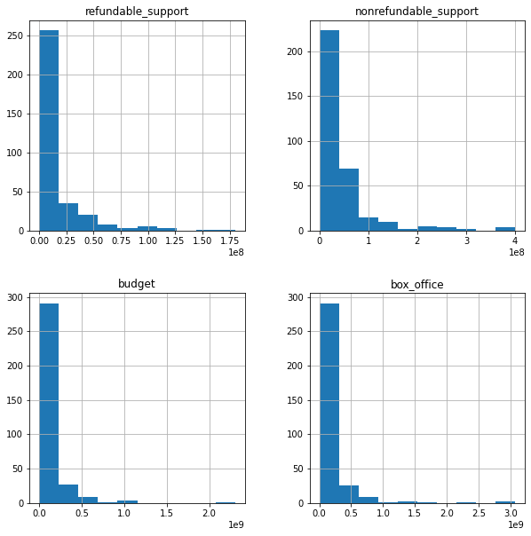

```python
data_qm.hist(figsize=(10,10));
```

Никаких особенностей в данных нет

#### 2.2.12 Добавим столбцы: 'show_year', 'movie_director', 'movie_genre', 'state_support_share'

##### 2.2.10.1 Столбец 'show_year' - год проката

```python
data['show_year'] = data['show_start_date'].dt.year
```

```python
data['movie_director'] = data['director'].apply(lambda x: x.split(',')[0])
```

##### 2.2.10.3 Столбец 'movie_genre' - жанр фильма

```python
data['movie_genre'] = data['genres'].apply(lambda x: x.split(',')[0])
```

##### 2.2.10.4 Столбец 'state_support_share' - доля гос. поддержки

```python
data['state_support_share'] = (
data.apply(lambda row: round((row['refundable_support'] + row['nonrefundable_support']) / row.budget * 100, 2) if ((row['refundable_support'] + row['nonrefundable_support']) > 0) & (row.budget > 0) else -1, axis=1)
)
```

## 3. Исследовательский анализ данных

### 3.1. Сколько фильмов выходило в прокат каждый год

```python
d_pvt = pd.pivot_table(data, index='show_year', values='title', aggfunc='count')
d_pvt.columns = ['movie_qty']
d_pvt = d_pvt.reset_index()
d_pvt
```

|  | show_year | movie_qty |
| --- | --- | --- |
| 0 | 2010 | 985 |
| 1 | 2011 | 622 |
| 2 | 2012 | 593 |
| 3 | 2013 | 630 |
| 4 | 2014 | 806 |
| 5 | 2015 | 705 |
| 6 | 2016 | 818 |
| 7 | 2017 | 505 |
| 8 | 2018 | 891 |
| 9 | 2019 | 930 |

Построим график:

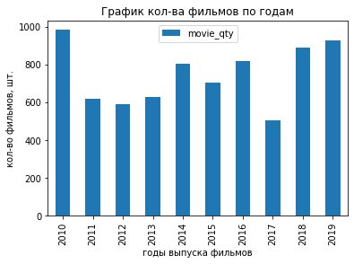

```python
d_pvt.plot(kind='bar', x='show_year', y='movie_qty', xlabel='годы выпуска фильмов', ylabel='кол-во фильмов, шт.', title='График кол-ва фильмов по годам');
```

### 3.2. Доля фильмов с указанием прокатных сборов от всех вышедших фильмов

```python
t_qty = data['title'].count()
bo_qty = data.query('box_office != -1')['title'].count()
total_share = round(bo_qty / t_qty, 4) * 100
total_share
```

```
42.19
```

Доля фильмов с указанием прокатных сборов по всем годам составляет 42.19%

### 3.3. Доля фильмов с указанием прокатных сборов от всех вышедших фильмов по годам

Получим общее число фильмов вышедших в прокат по годам

```python
data_all = pd.pivot_table(data, index='show_year', values='title', aggfunc='count').reset_index().rename(columns={'title':'q-ty'})
```

Получим число фильмов с указанием прокатных сборов

```python
data_bo = data[data['box_office'] != -1].pivot_table(values='title', index='show_year', aggfunc='count').reset_index().rename(columns={'title': 'bo_q-ty'})
```

Объеденим два датафрейма и расчитаем какую долю составляют фильмы с указанием прокатных сборов от общего числа фильмов, по годам выпуска

```python
data_merged = data_all.merge(data_bo, on='show_year', how='left')
data_merged['bo_share'] = round(data_merged['bo_q-ty'] / data_merged['q-ty'],3) * 100
data_merged
```

|  | show_year | q-ty | bo_q-ty | bo_share |
| --- | --- | --- | --- | --- |
| 0 | 2010 | 985 | 105 | 10.7 |
| 1 | 2011 | 622 | 109 | 17.5 |
| 2 | 2012 | 593 | 128 | 21.6 |
| 3 | 2013 | 630 | 184 | 29.2 |
| 4 | 2014 | 806 | 279 | 34.6 |
| 5 | 2015 | 705 | 465 | 66.0 |
| 6 | 2016 | 818 | 526 | 64.3 |
| 7 | 2017 | 505 | 357 | 70.7 |
| 8 | 2018 | 891 | 475 | 53.3 |
| 9 | 2019 | 930 | 530 | 57.0 |

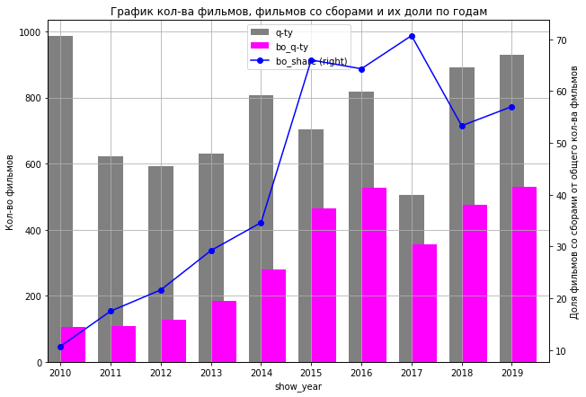

```python
ax = data_merged.plot(kind='bar', x='show_year', y='q-ty', title='График кол-ва фильмов, фильмов со сборами и их доли по годам', color='grey' ,ylabel='Кол-во фильмов', figsize=(10,7));
data_merged.plot(kind='bar', x='show_year', y='bo_q-ty', ax=ax,color='magenta', position=0)
data_merged.plot(c='blue', x='show_year', y='bo_share', ax=ax, secondary_y=True, xlabel='Годы выпуска фильмов', use_index=False, style='o-', grid=True)
ax.right_ax.set_ylabel('Доля фильмов со сборами от общего кол-ва фмльмов');
```

Из графика мы видим, что с 2010 по 2014 доля фильмов со сборами не высокая - информация по сборам фильмов в данный период манимальна. В то время как с 2015 по 2017 можно наблюдать значительный рост доли фильмов со сборами. После него идет снижение в 2018-2019 годах, при этом даже сниженное значение остается выше значений 2010-2014 годов. Таким образом можно сказать, что весь период 2010-2019 поделитлся на две части с низкой долей фильмов со сборами и высокой долей фильмов со сборами. При этом среднее значение доли в период 2010-2014 равно:

```python
data_merged.query('show_year < 2015')['bo_share'].mean()
```

```
22.72
```

В то время как среднее за период с 2015 по 2019 равно:

```python
round(data_merged.query('show_year > 2014')['bo_share'].mean(),2)
```

```
62.26
```

Видно, что 2015-2019 годы более полно представлены с точки зрения информации о сборах фильмов в прокате, чем 2010-2014 годы. Естестевенно, что минимальное значение находится в периоде 2010-2014 годов и соответсвует 2010 году, в то время как макисимальное значение находится в периоде 2015-2019 и соответствует 2017 году.

### 3.4. Сборы от показа фильмов - среднее, медиана, изменения по годам

Почистим значения в столбце 'box_office': заменим большие минусовые значения (чего быть не должно) на -1(нет инфо)

```python
data.loc[data['box_office']== -2147483648, 'box_office'] = data.query('box_office == -2147483648').replace(-2147483648, -1)
```

Выберем данные по сборам в отдельный датафрейм:

```python
data_box_off = data.query('box_office != -1').pivot_table(index='show_year', values='box_office', aggfunc=['min','max','mean', 'median']).reset_index()
```

```python
data_box_off
```

|  | show_year | min box_office | max box_office | mean box_office | median box_office |
| --- | --- | --- | --- | --- | --- |
| 0 | 2010 | 0 | 1446400 | 2.313004e+04 | 1700.0 |
| 1 | 2011 | 125 | 11618085 | 1.293832e+05 | 3000.0 |
| 2 | 2012 | 0 | 2311220 | 5.433924e+04 | 5660.0 |
| 3 | 2013 | 0 | 19957031 | 1.619549e+05 | 3522.5 |
| 4 | 2014 | 0 | 1016410635 | 2.668442e+07 | 18160.0 |
| 5 | 2015 | 0 | 1658861425 | 8.494057e+07 | 4920933.0 |
| 6 | 2016 | 0 | 2048126108 | 9.100057e+07 | 3846679.0 |
| 7 | 2017 | 7900 | 2779686144 | 1.360328e+08 | 9968340.0 |
| 8 | 2018 | 41225 | 2271754004 | 1.045651e+08 | 8891102.0 |
| 9 | 2019 | 4398 | 3073568690 | 9.136926e+07 | 4627798.0 |

Переименуем колонки для удобства пользования:

```python
data_box_off.columns = ['show_year','box_office_min', 'box_office_max', 'box_office_mean', 'box_office_median']
```

```python
data_box_off
```

|  | show_year | box_office_min | box_office_max | box_office_mean | box_office_median |
| --- | --- | --- | --- | --- | --- |
| 0 | 2010 | 0 | 1446400 | 2.313004e+04 | 1700.0 |
| 1 | 2011 | 125 | 11618085 | 1.293832e+05 | 3000.0 |
| 2 | 2012 | 0 | 2311220 | 5.433924e+04 | 5660.0 |
| 3 | 2013 | 0 | 19957031 | 1.619549e+05 | 3522.5 |
| 4 | 2014 | 0 | 1016410635 | 2.668442e+07 | 18160.0 |
| 5 | 2015 | 0 | 1658861425 | 8.494057e+07 | 4920933.0 |
| 6 | 2016 | 0 | 2048126108 | 9.100057e+07 | 3846679.0 |
| 7 | 2017 | 7900 | 2779686144 | 1.360328e+08 | 9968340.0 |
| 8 | 2018 | 41225 | 2271754004 | 1.045651e+08 | 8891102.0 |
| 9 | 2019 | 4398 | 3073568690 | 9.136926e+07 | 4627798.0 |

Подготовим график изменения среднего, медианы и максимального значения сборов от показа фильмов, по годам:

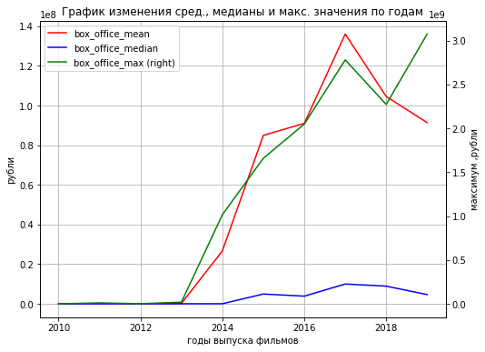

```python
ax = data_box_off.plot(kind='line', c='r', x='show_year', y='box_office_mean', figsize=(8,6))
data_box_off.plot(kind='line', ax=ax, c='b', x='show_year', y='box_office_median', title='График изменения сред., медианы и макс. значения по годам', ylabel='рубли')
data_box_off.plot(kind='line', c='g', ax=ax, secondary_y=True, x='show_year', y='box_office_max', xlabel='годы выпуска фильмов', grid=True)
ax.right_ax.set_ylabel('максимум ,рубли');
```

Мы видим, что колебания среднего значения сборов по годам очень сильно отличаются от колебаний медианы. Это наглядно демонстрирует сильную зависимость среднего от значений в наборе данных. На графике видно, что среднее повторяет движение макисмальных значений в наборе данных(доказательство выше сказанного)

### 3.5. Влияние возрастных ограничений на сборы от показа фильмов

```python
pvt = data.query('box_office != -1').pivot_table(index='show_year', columns='age_restriction', values='box_office', aggfunc=sum).reset_index().fillna(0)
pvt
```

| age_restriction | show_year | «0+» - для любой зрительской аудитории | «12+» - для детей старше 12 лет | «16+» - для детей старше 16 лет | «18+» - запрещено для детей | «6+» - для детей старше 6 лет |
| --- | --- | --- | --- | --- | --- | --- |
| 0 | 2010 | 1887611.0 | 1.201460e+05 | 3.665120e+05 | 5.438500e+04 | 0.000000e+00 |
| 1 | 2011 | 13499871.0 | 2.198910e+05 | 3.815130e+05 | 1.040000e+03 | 4.500000e+02 |
| 2 | 2012 | 2266483.0 | 1.087340e+05 | 3.254216e+06 | 1.825800e+05 | 1.143410e+06 |
| 3 | 2013 | 2710302.0 | 2.091034e+07 | 6.580690e+05 | 5.161245e+06 | 3.597520e+05 |
| 4 | 2014 | 375562257.0 | 2.584782e+09 | 5.442801e+08 | 2.209713e+09 | 1.730614e+09 |
| 5 | 2015 | 379054567.0 | 1.361608e+10 | 1.136812e+10 | 5.432308e+09 | 8.701799e+09 |
| 6 | 2016 | 150228839.0 | 1.220445e+10 | 1.666455e+10 | 6.793930e+09 | 1.205315e+10 |
| 7 | 2017 | 229598930.0 | 7.851428e+09 | 1.874504e+10 | 9.651496e+09 | 1.208614e+10 |
| 8 | 2018 | 32449001.0 | 1.426729e+10 | 1.650360e+10 | 8.760085e+09 | 1.010497e+10 |
| 9 | 2019 | 17746066.0 | 1.268020e+10 | 1.275342e+10 | 1.012180e+10 | 1.285255e+10 |

Переименуем столбцы для комфортного пользования:

```python
pvt.columns=['show_year','0+', '12+', '16+', '18+', '6+']
```

Построим график изменения суммы сборов в зависимости от возрастных огрничений

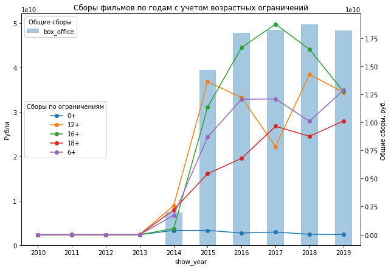

```python
#ax = plt.subplots()
ax = data.query('box_office != -1').pivot_table(index='show_year', values='box_office', aggfunc=sum).reset_index().plot(kind='bar', x='show_year', y='box_office',ylabel='Рубли', alpha=0.4)
pvt.plot(x='show_year', ax=ax,y=['0+', '12+', '16+', '18+', '6+'],figsize=(10,7),title='Сборы фильмов по годам с учетом возрастных ограничений', xlabel='Годы выпуска фильмов', style='o-', use_index=False,secondary_y=True);
ax.legend(title='Общие сборы',loc='upper left');
ax.right_ax.legend(title='Сборы по ограничениям',loc='center left')
ax.right_ax.set_ylabel('Общие сборы, руб.');
```

На графике видно, что наибольшие сборы получали фильмы с ограничением возраста "16+", при этом фильмы с ограничением "18+" одни из самых не популярных по сборам, ниже сборы только у фильмов с граничением "0+". Это наталкивает на мысль посмотреть удельные сборы(сборы на 1 фильм) по ограничениям и годам:

```python
pvt_count = data.query('box_office != -1').pivot_table(index='show_year', columns='age_restriction', values='box_office', aggfunc=['sum','count']).reset_index().fillna(0)
pvt_count
```

| age_restriction | show_year | sum «0+» - для любой зрительской аудитории | sum «12+» - для детей старше 12 лет | sum «16+» - для детей старше 16 лет | sum «18+» - запрещено для детей | sum «6+» - для детей старше 6 лет | count «0+» - для любой зрительской аудитории | count «12+» - для детей старше 12 лет | count «16+» - для детей старше 16 лет | count «18+» - запрещено для детей | count «6+» - для детей старше 6 лет |
| --- | --- | --- | --- | --- | --- | --- | --- | --- | --- | --- | --- |
| 0 | 2010 | 1887611.0 | 1.201460e+05 | 3.665120e+05 | 5.438500e+04 | 0.000000e+00 | 22.0 | 17.0 | 58.0 | 8.0 | 0.0 |
| 1 | 2011 | 13499871.0 | 2.198910e+05 | 3.815130e+05 | 1.040000e+03 | 4.500000e+02 | 30.0 | 22.0 | 54.0 | 2.0 | 1.0 |
| 2 | 2012 | 2266483.0 | 1.087340e+05 | 3.254216e+06 | 1.825800e+05 | 1.143410e+06 | 30.0 | 16.0 | 49.0 | 17.0 | 16.0 |
| 3 | 2013 | 2710302.0 | 2.091034e+07 | 6.580690e+05 | 5.161245e+06 | 3.597520e+05 | 37.0 | 60.0 | 45.0 | 16.0 | 26.0 |
| 4 | 2014 | 375562257.0 | 2.584782e+09 | 5.442801e+08 | 2.209713e+09 | 1.730614e+09 | 38.0 | 84.0 | 82.0 | 45.0 | 30.0 |
| 5 | 2015 | 379054567.0 | 1.361608e+10 | 1.136812e+10 | 5.432308e+09 | 8.701799e+09 | 39.0 | 73.0 | 168.0 | 132.0 | 53.0 |
| 6 | 2016 | 150228839.0 | 1.220445e+10 | 1.666455e+10 | 6.793930e+09 | 1.205315e+10 | 41.0 | 82.0 | 182.0 | 151.0 | 70.0 |
| 7 | 2017 | 229598930.0 | 7.851428e+09 | 1.874504e+10 | 9.651496e+09 | 1.208614e+10 | 3.0 | 41.0 | 121.0 | 147.0 | 45.0 |
| 8 | 2018 | 32449001.0 | 1.426729e+10 | 1.650360e+10 | 8.760085e+09 | 1.010497e+10 | 5.0 | 67.0 | 156.0 | 179.0 | 68.0 |
| 9 | 2019 | 17746066.0 | 1.268020e+10 | 1.275342e+10 | 1.012180e+10 | 1.285255e+10 | 3.0 | 85.0 | 178.0 | 183.0 | 81.0 |

Установим индекс ввиде года выпуска фильма, для удобства дальнейших вычислений:

```python
pvt_count.set_index('show_year', inplace=True)
```

Переименуем стольбцы, также для удобства:

```python
pvt_count.columns = ['sum_0+','sum_12+','sum_16+','sum_18+','sum_6+','count_0+','count_12+','count_16+','count_18+','count_6+']
```

Посмотрим, что получилось:

```python
pvt_count
```

| show_year | sum_0+ | sum_12+ | sum_16+ | sum_18+ | sum_6+ | count_0+ | count_12+ | count_16+ | count_18+ | count_6+ |
| --- | --- | --- | --- | --- | --- | --- | --- | --- | --- | --- |
| 2010 | 1887611.0 | 1.201460e+05 | 3.665120e+05 | 5.438500e+04 | 0.000000e+00 | 22.0 | 17.0 | 58.0 | 8.0 | 0.0 |
| 2011 | 13499871.0 | 2.198910e+05 | 3.815130e+05 | 1.040000e+03 | 4.500000e+02 | 30.0 | 22.0 | 54.0 | 2.0 | 1.0 |
| 2012 | 2266483.0 | 1.087340e+05 | 3.254216e+06 | 1.825800e+05 | 1.143410e+06 | 30.0 | 16.0 | 49.0 | 17.0 | 16.0 |
| 2013 | 2710302.0 | 2.091034e+07 | 6.580690e+05 | 5.161245e+06 | 3.597520e+05 | 37.0 | 60.0 | 45.0 | 16.0 | 26.0 |
| 2014 | 375562257.0 | 2.584782e+09 | 5.442801e+08 | 2.209713e+09 | 1.730614e+09 | 38.0 | 84.0 | 82.0 | 45.0 | 30.0 |
| 2015 | 379054567.0 | 1.361608e+10 | 1.136812e+10 | 5.432308e+09 | 8.701799e+09 | 39.0 | 73.0 | 168.0 | 132.0 | 53.0 |
| 2016 | 150228839.0 | 1.220445e+10 | 1.666455e+10 | 6.793930e+09 | 1.205315e+10 | 41.0 | 82.0 | 182.0 | 151.0 | 70.0 |
| 2017 | 229598930.0 | 7.851428e+09 | 1.874504e+10 | 9.651496e+09 | 1.208614e+10 | 3.0 | 41.0 | 121.0 | 147.0 | 45.0 |
| 2018 | 32449001.0 | 1.426729e+10 | 1.650360e+10 | 8.760085e+09 | 1.010497e+10 | 5.0 | 67.0 | 156.0 | 179.0 | 68.0 |
| 2019 | 17746066.0 | 1.268020e+10 | 1.275342e+10 | 1.012180e+10 | 1.285255e+10 | 3.0 | 85.0 | 178.0 | 183.0 | 81.0 |

Добавим в таблицу новые столбцы со значением удельных сборов(сборы на 1 фильм) по возратным ограничениям и годам:

```python
arl = ['spec_0+','spec_12+','spec_16+','spec_18+','spec_6+']
for i in range(5):
    pvt_count[arl[i]] = round(pvt_count.iloc[:,i] / pvt_count.iloc[:,i+5],1)
```

Если появились пропуски заполним их 0:

```python
pvt_count = pvt_count.reset_index().fillna(0)
```

```python
pvt_count
```

|  | show_year | sum_0+ | sum_12+ | sum_16+ | sum_18+ | sum_6+ | count_0+ | count_12+ | count_16+ | count_18+ | count_6+ | spec_0+ | spec_12+ | spec_16+ | spec_18+ | spec_6+ |
| --- | --- | --- | --- | --- | --- | --- | --- | --- | --- | --- | --- | --- | --- | --- | --- | --- |
| 0 | 2010 | 1887611.0 | 1.201460e+05 | 3.665120e+05 | 5.438500e+04 | 0.000000e+00 | 22.0 | 17.0 | 58.0 | 8.0 | 0.0 | 85800.5 | 7067.4 | 6319.2 | 6798.1 | 0.0 |
| 1 | 2011 | 13499871.0 | 2.198910e+05 | 3.815130e+05 | 1.040000e+03 | 4.500000e+02 | 30.0 | 22.0 | 54.0 | 2.0 | 1.0 | 449995.7 | 9995.0 | 7065.1 | 520.0 | 450.0 |
| 2 | 2012 | 2266483.0 | 1.087340e+05 | 3.254216e+06 | 1.825800e+05 | 1.143410e+06 | 30.0 | 16.0 | 49.0 | 17.0 | 16.0 | 75549.4 | 6795.9 | 66412.6 | 10740.0 | 71463.1 |
| 3 | 2013 | 2710302.0 | 2.091034e+07 | 6.580690e+05 | 5.161245e+06 | 3.597520e+05 | 37.0 | 60.0 | 45.0 | 16.0 | 26.0 | 73251.4 | 348505.6 | 14623.8 | 322577.8 | 13836.6 |
| 4 | 2014 | 375562257.0 | 2.584782e+09 | 5.442801e+08 | 2.209713e+09 | 1.730614e+09 | 38.0 | 84.0 | 82.0 | 45.0 | 30.0 | 9883217.3 | 30771218.1 | 6637562.0 | 49104727.6 | 57687148.0 |
| 5 | 2015 | 379054567.0 | 1.361608e+10 | 1.136812e+10 | 5.432308e+09 | 8.701799e+09 | 39.0 | 73.0 | 168.0 | 132.0 | 53.0 | 9719347.9 | 186521671.1 | 67667385.9 | 41153851.0 | 164184893.5 |
| 6 | 2016 | 150228839.0 | 1.220445e+10 | 1.666455e+10 | 6.793930e+09 | 1.205315e+10 | 41.0 | 82.0 | 182.0 | 151.0 | 70.0 | 3664118.0 | 148834713.5 | 91563453.3 | 44992912.4 | 172187799.9 |
| 7 | 2017 | 229598930.0 | 7.851428e+09 | 1.874504e+10 | 9.651496e+09 | 1.208614e+10 | 3.0 | 41.0 | 121.0 | 147.0 | 45.0 | 76532976.7 | 191498235.6 | 154917709.9 | 65656432.5 | 268580936.6 |
| 8 | 2018 | 32449001.0 | 1.426729e+10 | 1.650360e+10 | 8.760085e+09 | 1.010497e+10 | 5.0 | 67.0 | 156.0 | 179.0 | 68.0 | 6489800.2 | 212944651.3 | 105792322.3 | 48939024.8 | 148602567.5 |
| 9 | 2019 | 17746066.0 | 1.268020e+10 | 1.275342e+10 | 1.012180e+10 | 1.285255e+10 | 3.0 | 85.0 | 178.0 | 183.0 | 81.0 | 5915355.3 | 149178808.7 | 71648420.9 | 55310362.0 | 158673439.7 |

Построим график изменений удельных сборов по возрастным категориям и годам:

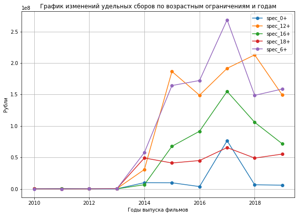

```python
pvt_count.plot(x='show_year', y=['spec_0+','spec_12+','spec_16+',	'spec_18+',	'spec_6+'],figsize=(10,7),title='График изменений удельных сборов по возрастным ограничениям и годам', xlabel='Годы выпуска фильмов', style='o-', grid=True, ylabel='Рубли');
```

По графику мы видим, что картина изменилась и теперь наиболее популярные по удельным сборам фильмы с возрастными ограничениями "6+" и "12+", но по графику сложно поныть кто из них лидер нашего исследования, посчитаем общие удельные сборы за все годы и узнаем победителя:

```python
for i in range(11,16):
    su = round(sum(pvt_count.iloc[:,i]),0)
    print(f'Удельная сумма сборов по возрастным ограничениям {pvt_count.columns[i]} за все годы равна {su}')
```

```
Удельная сумма сборов по возрастным ограничениям spec_0+ за все годы равна 112889412.0
Удельная сумма сборов по возрастным ограничениям spec_12+ за все годы равна 920121662.0
Удельная сумма сборов по возрастным ограничениям spec_16+ за все годы равна 498321275.0
Удельная сумма сборов по возрастным ограничениям spec_18+ за все годы равна 305497946.0
Удельная сумма сборов по возрастным ограничениям spec_6+ за все годы равна 970002535.0
```

## 4. Анализ фильмов с государственной поддержкой

Вынесем фильмы с гос поддержкой в отдельный дата фрейм:

```python
data_st_sup = data.query('(refundable_support + nonrefundable_support) > 0')
```

Заменим значение в столбце бюджет в строке 7113 на 0 (был большой минус, чего быть не может):

```python
data_st_sup.loc[7113,'budget'] = 0
```

```python
data_st_sup[data_st_sup['state_support_share'] < 0]
```

|  | title | puNumber | show_start_date | type | film_studio | production_country | director | producer | age_restriction | refundable_support | nonrefundable_support | budget | financing_source | ratings | genres | box_office | show_year | movie_director | movie_genre | state_support_share |
| --- | --- | --- | --- | --- | --- | --- | --- | --- | --- | --- | --- | --- | --- | --- | --- | --- | --- | --- | --- | --- |
| 2052 | 14+ | 111023614 | 2014-12-19 12:00:00+00:00 | Художественный | ООО Киностудия "Сентябрь" | Россия | А.Зайцев | А.Зайцев, О.Гранина | «16+» - для детей старше 16 лет | 0 | 23000000 | 0 | Министерство культуры, Фонд кино | 6.6 | мелодрама | 10234016 | 2014 | А.Зайцев | мелодрама | -1.0 |
| 2057 | Дуxless 2 | 111000415 | 2015-01-26 12:00:00+00:00 | Художественный | ООО "Арт Пикчерс Студия", ООО "Киностудия "Слово" | Россия | Р.Прыгунов | Д.Рудовский, Ф.Бондарчук, П.Ануров | «16+» - для детей старше 16 лет | 0 | 75000000 | 0 | Фонд кино | 6.6 | драма | 446163511 | 2015 | Р.Прыгунов | драма | -1.0 |
| 2471 | Воин (2015) | 111017315 | 2015-09-28 12:00:00+00:00 | Художественный | ООО "Арт Пикчерс Студия", ООО "Форпост Продакшн" | Россия | А.Андрианов | О."Арт | «12+» - для детей старше 12 лет | 10000000 | 70000000 | 0 | Фонд кино | 7.8 | боевик, драма, криминал | 196572438 | 2015 | А.Андрианов | боевик | -1.0 |
| 2531 | Бармен | 111009615 | 2015-05-26 12:00:00+00:00 | Художественный | ООО "Арт Пикчерс Студия", АО "ВайТ Медиа" | Россия | Д.Штурманова | Т.Вайнштейн | «16+» - для детей старше 16 лет | 20000000 | 0 | 0 | Фонд кино | 6.2 | комедия, фэнтези | 67418974 | 2015 | Д.Штурманова | комедия | -1.0 |
| 2614 | Савва. Сердце воина | 114001715 | 2015-07-21 12:00:00+00:00 | Анимационный | ООО "Арт Пикчерс Студия", ООО "Глюкоза Продакшн" | Россия | М.Фадеев | А.Чистяков | «6+» - для детей старше 6 лет | 60000000 | 100000000 | 0 | Фонд кино | 4.6 | мультфильм, приключения, фэнтези | 184487551 | 2015 | М.Фадеев | мультфильм | -1.0 |
| 2683 | Тряпичный союз | 111010215 | 2015-06-08 12:00:00+00:00 | Художественный | ООО "Кинокомпания "КОКТЕБЕЛЬ" | Россия | М.Местецкий | А.Кушаев, Р.Борисевич | «18+» - запрещено для детей | 0 | 59000000 | 0 | Фонд кино | 6.3 | драма, комедия | 1957738 | 2015 | М.Местецкий | драма | -1.0 |
| 2787 | Срочно выйду замуж | 111017115 | 2015-09-30 12:00:00+00:00 | Художественный | ООО "Арт Пикчерс Студия", АО "ВайТ Медиа" | Россия | С.Чекалов | Д.Рудовский, Т.Вайнштейн, Ф.Бондарчук | «16+» - для детей старше 16 лет | 0 | 35000000 | 0 | Фонд кино | 5.1 | комедия, мелодрама | 72937783 | 2015 | С.Чекалов | комедия | -1.0 |
| 2873 | Помню - не помню! | 111004916 | 2016-03-01 12:00:00+00:00 | Художественный | ООО "КиноФирма" | Россия | В.Ровенский | О."КиноФирма" | «12+» - для детей старше 12 лет | 0 | 6000000 | 0 | Министерство культуры | 4.3 | комедия | 15362931 | 2016 | В.Ровенский | комедия | -1.0 |
| 3046 | Любовь с ограничениями | 111008216 | 2016-04-29 12:00:00+00:00 | Художественный | ООО "Арт Пикчерс Студия", АО "ВайТ Медиа" | Россия | Д.Тюрин | Д.Рудовский, Т.Вайнштейн, Ф.Бондарчук | «16+» - для детей старше 16 лет | 19000000 | 51000000 | 0 | Фонд кино | 6.3 | комедия, мелодрама | 70299052 | 2016 | Д.Тюрин | комедия | -1.0 |
| 3564 | Притяжение (2016) | 111018116 | 2016-12-16 12:00:00+00:00 | Художественный | ООО "Арт Пикчерс Студия", ООО "Водород 2011" | Россия | Ф.Бондарчук | О."Арт | «12+» - для детей старше 12 лет | 0 | 250000000 | 0 | Фонд кино | 5.6 | фантастика | 1038321489 | 2016 | Ф.Бондарчук | фантастика | -1.0 |
| 3674 | Чудо-юдо | 114001817 | 2017-06-27 12:00:00+00:00 | Анимационный | ООО "КиноФирма" | Россия | А.Лукичев | О."КиноФирма" | «6+» - для детей старше 6 лет | 20000000 | 20000000 | 0 | Фонд кино | 5.2 | мультфильм, семейный, фэнтези | 55108014 | 2017 | А.Лукичев | мультфильм | -1.0 |
| 3738 | Мифы | 111004317 | 2017-06-07 12:00:00+00:00 | Художественный | ООО "Арт Пикчерс Студия", ООО "ХАЙПФИЛМ" | Россия | А.Молочников | Д.Рудовский, И.Стюарт, М.Османн, Ю.Козырев, Ф.... | «16+» - для детей старше 16 лет | 25000000 | 20000000 | 0 | Фонд кино | 4.8 | комедия | 50451949 | 2017 | А.Молочников | комедия | -1.0 |
| 5672 | Селфи | 111012117 | 2018-02-01 12:00:00+00:00 | Художественный | ООО "Арт Пикчерс Студия", ООО "Киностудия "Слово" | Россия | Н.Хомерики | Д.Рудовский, Ф.Бондарчук, П.Ануров | «16+» - для детей старше 16 лет | 20000000 | 40000000 | 0 | Фонд кино | 5.8 | драма, триллер | 225196400 | 2018 | Н.Хомерики | драма | -1.0 |
| 5805 | Два хвоста | 114001018 | 2018-05-31 12:00:00+00:00 | Анимационный | ООО "ЛИЦЕНЗИОННЫЕ БРЕНДЫ" | Россия | Н.Лопато, В.Ровенский, В.Азеев | О."ЛИЦЕНЗИОННЫЕ | «6+» - для детей старше 6 лет | 10000000 | 60000000 | 0 | Фонд кино | 5.0 | детский, мультфильм | 106514301 | 2018 | Н.Лопато | детский | -1.0 |
| 6007 | Принцесса и дракон | 114003018 | 2018-08-23 12:00:00+00:00 | Анимационный | ООО "ЛИЦЕНЗИОННЫЕ БРЕНДЫ" | Россия | М.Нефедова | О."ЛИЦЕНЗИОННЫЕ | «6+» - для детей старше 6 лет | 40000000 | 40000000 | 0 | Фонд кино | 5.2 | детский, мультфильм, фэнтези | 83366328 | 2018 | М.Нефедова | детский | -1.0 |
| 6322 | Баба Яга | 114006518 | 2018-11-08 12:00:00+00:00 | Анимационный | ООО "Арт Пикчерс Студия" | Россия | В.Саков | О."КРИЭЙТИВ, О."Система-А", О."Арт | «6+» - для детей старше 6 лет | 0 | 138969465 | 0 | Фонд кино | 0.0 | драма | 1334699 | 2018 | В.Саков | драма | -1.0 |
| 6822 | Большое путешествие | 114002419 | 2019-04-20 12:00:00+00:00 | Анимационный | ООО "ЛИЦЕНЗИОННЫЕ БРЕНДЫ" | Россия | Н.Лопато, В.Ровенский | О."ЛИЦЕНЗИОННЫЕ | «6+» - для детей старше 6 лет | 60000000 | 120000000 | 0 | Фонд кино | 6.2 | комедия, мультфильм, приключения | 147606826 | 2019 | Н.Лопато | комедия | -1.0 |

По фильмам у которых 'state_support_share' равно 0 или -1 мы ничего сказать не сможем, потому уберем их из анализа:

```python
data_st_sup = data_st_sup[data_st_sup['state_support_share'] > 0]
```

Попробуем найти какие-то взаимосвязи между столбцами дата фрейма и господдержкой 'state_support_share'. Будем рассуждат логически, может ли быть какая-то связь между:

1. называнием фильма и 'state_support_share' ? Скорее всего они никак не связаны. Выбор название фильма это случайный процесс.
2. тоже самое относится и к номеру прокатного удостоверения (выдается случайным образом, ну или по порядку, что в нашем случае тоже будет случайным)
3. дата начала проката также никак не связана с финансированием со стороны государства (если бы мы жили в СССР, то такая связь могла бы существовать, многие выходы фильмов обычно приурочивались к каким-лиюо датам и праздникам, хотя в то время все фильмы выходили только благодаря финансированию государства)
4. тип фильма может быть связан с поддержкой государства - нужно рассмотреть
5. студия, которая занималась производством фильма - можно поискать зависимости
6. страна - все фильмы поддерживаемые государством производятся в этом государстве, так что поддерка в этом случае 100%
7. режисер - связь вполне может быть, так как господдерка скорее всего будет предоставлена известному режисеру, чем неизвестному. Посмотрим есть ли связь в этом случае?
8. продюсер - связь также может быть, как и в случае с режисером. Посмотрим.
9. возрастные ограничения, связь не очень очевидна, но попробуем поискать
10. рейтинг - посмотрим на наличие связи
11. жанр - постморим на наличие связи
12. сборы - посмотрим наличие связи  
    Итак план мы набрасали, в бой:

### 4.1. Связь типа фильма и господдержки

Тип фильма является категориальным столбцов и самое главное строковым. Невозможно искать связь между строковым значением и числовым. Для этого нужно перевести строковое значение в числовое, или другими словами закодировать столбец 'type'

Закодирем тип фильма кол-вом появлений в дата фрейме:

```python
data_st_sup['type'].value_counts()
```

```
Художественный    289
Анимационный       25
Документальный      1
Name: type, dtype: int64
```

```python
data_st_sup.type.unique()[::-1]
```

```
array(['Документальный', 'Анимационный', 'Художественный'], dtype=object)
```

Создадим категориальные столбец 'cat_type', который будет состоять из кодов типов фильмов, причем они будут отражать кол-во появления каждого типа в дата фрейме:

```python
data_st_sup['cat_type'] = pd.Categorical(data_st_sup['type'], data_st_sup.type.unique()[::-1]).codes
data_st_sup['cat_type'] = data_st_sup['cat_type'].astype('category')
data_st_sup['cat_type'] = data_st_sup['cat_type'].cat.as_ordered()
```

Посмотим на наличие зависмость на грфике:

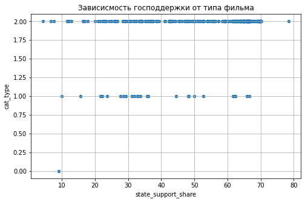

```python
data_st_sup.plot(kind='scatter', x='state_support_share', y='cat_type', grid=True, title='Зависисмость господдержки от типа фильма', figsize=(8,5));
```

Расчитаем коэффициент корреляции:

```python
data_st_sup['cat_type'].corr(data_st_sup['state_support_share'])
```

```
0.25897290613068386
```

Связь очень слабая

Посмотрим зависимость от года выпуска в прокат:

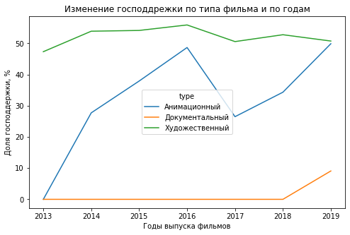

```python
pd.pivot_table(data_st_sup, columns='type', values='state_support_share', index='show_year').fillna(0).reset_index().plot(x='show_year',
y=['Анимационный','Документальный','Художественный'], title='Изменение господдрежки по типа фильма и по годам',figsize=(8,5), xlabel='Годы выпуска фильмов', ylabel='Доля господдержки, %');
```

Несмотря на низкую корреляцию - 0.26, мы видим, что и по кол-ву и по доле господдержки лидирует "художественный фильм", затем идет "анимационный" и с минимальной поддержкой идет "документальный". Таким образом прослеживается явная зависимость господдержки от того какой фильм собираются снимать. Это наверно достаточно логично, ведь художественные фильмы гораздо популярнее, чем анимаионные и тем более документальные.

### 4.2. Связь студии, создавшей фильм, и господдержки

Посмотрим сколько раз та или иная студия выпускала фильмы в прокат, с господдержкой:

```python
data_st_sup['film_studio'].value_counts()
```

```
ООО "Студия анимационного кино "Мельница"                                         7
ООО "ТаББаК"                                                                      7
ООО "Кинокомпания "СТВ"                                                           6
ООО "ВИЗАРТ ФИЛЬМ"                                                                5
ООО "Каро Продакшн"                                                               4
                                                                                 ..
ООО "Муха", ООО "Анимационная студия "Сказка"                                     1
ООО "ЦЕНТРОКИНО", ООО "КИНОДАНЦ"                                                  1
ООО "Муравей Продакшн", ООО "Продюсерский центр "Новое Время"                     1
ФГУП "Киноконцерн "Мосфильм", ООО "Продюсерская компания Александра Литвинова"    1
ООО "Студия Третий Рим", ООО "ТаББаК"                                             1
Name: film_studio, Length: 247, dtype: int64
```

Здесь уже наблюдается небольшая зависимость, какие-то студии выпускали фильмы с господдержкой несколько раз, а какие-то только единожды  
продолжим наш анализ дальше:

Найдем уникальные значения столбца студия фильма:

```python
data_st_sup['film_studio'].unique()
```

```
array(['ООО "Кинокомпания Отражение", АНО содействия развитию кинематографии "Ангел-Фильм"',
       'ООО "Компания "АТК-Студио"', 'ООО "Компания "РЕАЛ-ДАКОТА"',
       'ООО "Студия "Пассажир"', 'ООО "Студия "Мастер-Фильм"',
       'ООО "Компания "Реал-Дакота"',
       'Jura Podnieka Studija, Rezo Productions, ООО "Продюсерский Центр "Хорошо Продакшн"',
       'ООО "Водород 2011"', 'ООО "Кинокомпания "Ракурс"', 'ООО "ТаББаК"',
       'ООО "Продюсерская кинокомпания "Киномир"',
       'ООО "Пиманов и партнеры"', 'ООО "ВИЗАРТ ФИЛЬМ"', 'ООО "Пендулум"',
       'ФГУП "Киноконцерн "Мосфильм", ООО "Продюсерская компания Александра Литвинова"',
       'ООО "Арт Пикчерс Студия", ООО "Корнер Ворк"',
       'ООО "АМАЛЬГАМА ПРОДАКШН"', 'ООО "Амкарт"', 'ООО "Каро Продакшн"',
       'ООО "Студия "Кинодел", ООО "Кинокомпания "Новые люди"',
       'ООО "Группа компаний "Андреевский флаг", ООО "Творческое объединение "Кинокомпания "Андреевский флаг"',
       'ООО "Ультра стори", ООО "Энджой мувиз"',
       'ООО "Киностудия "МАСТЕР"', 'ООО "Артлайт"',
       'ООО "Кинокомпания "Фигаро"', 'ООО "Валдай"',
       'ООО "Смарт ТВ Продакшн"',
       'ООО "Центр Юпитер ФМ", ООО Кинокомпания "Фортуна Фильм"',
       'ООО "Магнум-фильм" по заказу ООО "ММЕ"',
       'ООО "Инвестмент Бизнес Консалтинг", ООО "Пролайн-медиа", ООО "Киностудия "Никола-фильм"',
       'ООО "Нон-Стоп Продакшн"', 'ООО "29 февраля"',
       'ООО Продюсерский центр "Всё хорошо"',
       'АНО "Творческая студия "Стелла"', 'ООО "Кинокомпания "СТВ"',
       'ООО "Магнум-фильм"',
       'НП "Интерфест", ООО "Компания "РЕАЛ-ДАКОТА"',
       'ООО "Кинокомпания "Ладья"', 'ООО "ТАН Фильм"',
       'ООО "Росмедиа Продакшн" по заказу ООО "МАРС МЕДИА ЭНТЕРТЕЙНМЕНТ"',
       'ООО "Первое творческое объединение"',
       'ООО "Студия анимационного кино "Мельница"', 'ООО "АРТЛАЙТ"',
       'ООО "Кинокомпания "ТАЛАН"', 'ООО "Киностудия "ВЕРТИКАЛЬ"',
       'ООО "Продюсерская компания Николая Расторгуева"',
       'ООО "Кинопрограмма XXI век"', 'ООО "ЛИГА ПРОДАКШН"',
       'ООО "Студия "РОЙ", Культурный фонд "Кино-телекомпания "Православная энциклопедия"',
       'ООО "Аристократ", ООО "Революция Фильм", ООО "Пропеллер продакшн"',
       'ООО "СТН-фильм"', 'ООО "Продюсерский центр "Ленфильм"',
       'ООО "ЭН-ДЖИ ПРОДАКШН"',
       'ООО "Кинокомпания МАРС-фильм" по заказу ООО "МАРС МЕДИА ЭНТЕРТЕЙНМЕНТ"',
       'ООО "Смешарики"',
       'ООО "ЛИНКЕД ФИЛМС", ООО "Эппл Фильм Продакшн", ООО "Метрафильмс"',
       'ООО "Студия "ТРЕТИЙ РИМ"', 'ООО "Продюсерский центр "ВГИК-Дебют"',
```

[output cut: 125 more lines]

```
       'ООО "Студия "Рой"',
       'ООО "Кинокомпания "СТВ", 5 Продакшн", ООО "58',
       'Лтд., Лтд., Лтд.; Чайна Интернэшнл Филм & Медиа Корп., Спаркл Ролл Медиа Корпорейшн, ООО "Кинокомпания "СТВ"; ООО "РФГ Корп"; ООО "РФГ"; АО "Маринс Групп Интертеймент"; ООО "Фетисов Иллюзион"; ИП Петрухин; Чайна Филм Ко.',
       'ООО "КиТ фильм", ООО "2Д Целлулоид"',
       'ООО "Продюсерский центр "Молодежные инициативы"',
       'ООО "Кей Ди Студиос"',
       'ООО "Жан Виго Италия" (Jean Vigo Italia S.R.L.), НО Фонд Андрея Кончаловского по поддержке кино и сценических искусств',
       'ООО "Продюсерский центр "Новое Время"',
       'ООО "Муравей Продакшн", ООО "Продюсерский центр "Новое Время"',
       'ООО "Медиа Юниверсал"', 'ООО "Карго"', 'ООО "Лаборатория Кино"',
       'ООО "ВитЭл"', 'ООО "Кремлин Филмз"',
       '"Артемис", "Гринлит", ООО "Зебра"', 'ООО "СОК"', 'АО "Аэроплан"',
       'ООО "МЕМ-МЕДИА" по заказу АО "ВБД Груп"', 'ЗАО "Дирекция кино"',
       'ООО "Водород 2011", ООО "Арт Пикчерс Студия"',
       'АО "ТПО "Киностудия им. М.Горького"'], dtype=object)
```

```python
len(data_st_sup['film_studio'].unique())
```

```
247
```

Создадим категориальный столбец для студии фильма:

```python
data_st_sup['cat_film_studio'] = pd.Categorical(data_st_sup['film_studio'], data_st_sup['film_studio'].unique()).codes
data_st_sup['cat_film_studio'] = data_st_sup['cat_film_studio'].astype('category')
```

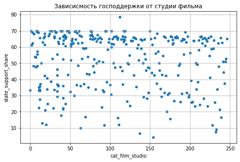

```python
data_st_sup.plot(kind='scatter', y='state_support_share', x='cat_film_studio', grid=True, title='Зависисмость господдержки от студии фильма', figsize=(8,5));
```

```python
data_st_sup['cat_film_studio'].corr(data_st_sup['state_support_share'])
```

```
-0.10310434375720631
```

Значения корреляции говорят, что связи практически никакой нет.

```python
uniq = data_st_sup['film_studio'].unique()
```

Сгруппируем данные по студии и расчитаем кол-во фильмов выпущенное студией с гос поддержкой и среднюю господдержку для этой студии  
Отсортируем результат по убыванию кол-ва выпущенных фильмов и ограничим вывод кол-вом более 1 выпущенного фильма:

```python
pt = pd.pivot_table(data_st_sup, index='film_studio', values=['state_support_share', 'ratings'], aggfunc={'state_support_share':['count', 'mean'], 'ratings':'mean'}).reset_index()
pt.columns = ['film_studio','ratings_ss','count_ss', 'mean_ss']
pt.sort_values('count_ss' , ascending=False)
pt[pt['count_ss'] > 1].sort_values('count_ss' , ascending=False)
```

|  | film_studio | ratings_ss | count_ss | mean_ss |
| --- | --- | --- | --- | --- |
| 215 | ООО "ТаББаК" | 5.000000 | 7 | 62.827143 |
| 212 | ООО "Студия анимационного кино "Мельница" | 6.314286 | 7 | 41.451429 |
| 96 | ООО "Кинокомпания "СТВ" | 6.183333 | 6 | 40.595000 |
| 58 | ООО "ВИЗАРТ ФИЛЬМ" | 6.300000 | 5 | 39.200000 |
| 153 | ООО "Нон-Стоп Продакшн" | 5.950000 | 4 | 58.040000 |
| 170 | ООО "Продюсерский центр "Ленфильм" | 5.800000 | 4 | 58.970000 |
| 83 | ООО "Каро Продакшн" | 5.375000 | 4 | 59.702500 |
| 112 | ООО "Киностудия "ВЕРТИКАЛЬ" | 5.825000 | 4 | 54.367500 |
| 203 | ООО "Студия "СЛОН" | 5.833333 | 3 | 56.640000 |
| 141 | ООО "Магнум-фильм" | 6.466667 | 3 | 45.123333 |
| 125 | ООО "Компания "Новые люди" | 5.666667 | 3 | 63.993333 |
| 159 | ООО "Пиманов и партнеры" | 5.000000 | 3 | 30.376667 |
| 55 | ООО "ВВП Альянс" | 3.866667 | 3 | 66.056667 |
| 165 | ООО "Продюсерский Центр "Хорошо Продакшн" | 6.000000 | 2 | 65.725000 |
| 200 | ООО "Студия "Пассажир" | 5.300000 | 2 | 65.745000 |
| 186 | ООО "Русские Золотые Серии" | 2.900000 | 2 | 56.800000 |
| 205 | ООО "Студия "ТРИТЭ" Никиты Михалкова" | 7.550000 | 2 | 68.680000 |
| 173 | ООО "Продюсерский центр "Парадиз" | 5.000000 | 2 | 56.645000 |
| 214 | ООО "ТПО "РОК" | 5.200000 | 2 | 66.460000 |
| 218 | ООО "Ультра стори", ООО "Энджой мувиз" | 4.450000 | 2 | 37.525000 |
| 220 | ООО "Форс Медиа" | 6.000000 | 2 | 55.870000 |
| 168 | ООО "Продюсерский центр "ВГИК-Дебют" | 6.450000 | 2 | 67.470000 |
| 17 | АО "ТПО "Киностудия им.М.Горького" | 6.100000 | 2 | 60.435000 |
| 149 | ООО "Медиа Юниверсал Ивент" | 6.700000 | 2 | 61.330000 |
| 164 | ООО "Продюсерская фирма Игоря Толстунова" | 6.150000 | 2 | 68.095000 |
| 154 | ООО "Ол Медиа Компани" | 6.100000 | 2 | 57.655000 |
| 25 | ЗАО "Мотор фильм студия" | 6.300000 | 2 | 63.130000 |
| 124 | ООО "Компания "АТК-Студио" | 2.350000 | 2 | 70.000000 |
| 108 | ООО "Кинокомпания Флагман" по заказу ООО "ММЕ" | 6.350000 | 2 | 64.745000 |
| 104 | ООО "Кинокомпания МАРС-фильм" по заказу ООО "М... | 5.850000 | 2 | 63.610000 |
| 92 | ООО "Кинокомпания "Небо" | 6.400000 | 2 | 55.395000 |
| 90 | ООО "Кинодом" | 6.800000 | 2 | 42.080000 |
| 82 | ООО "Каргофильм" | 5.250000 | 2 | 66.075000 |
| 66 | ООО "ДжемСтудия" | 6.250000 | 2 | 41.090000 |
| 63 | ООО "Водород 2011" | 6.250000 | 2 | 50.720000 |
| 46 | ООО "Анимационная студия РИМ" | 4.300000 | 2 | 23.060000 |
| 43 | ООО "АРТЛАЙТ" | 5.650000 | 2 | 65.185000 |
| 228 | ООО "Энджой мувиз" | 6.400000 | 2 | 48.490000 |

Есть подозрения, что господдерка убывает с ростом выпущенных выпущенных одной студией фильмов. Проверим, гипотезу:

```python
pt1 = pd.pivot_table(pt, index='count_ss', values='mean_ss').reset_index()
```

```python
pt1['count_ss'].corr(pt1['mean_ss'])
```

```
-0.4355003246394049
```

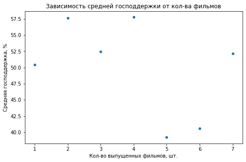

```python
pt1.plot(kind='scatter', x='count_ss', y='mean_ss', figsize=(8,5), xlabel='Кол-во выпущенных фильмов, шт.', ylabel='Средняя господдержка, %', title='Зависимость средней господдержки от кол-ва фильмов');
```

Есть не очень сильная отрицательная зависимость - снижение господдержки с ростом кол-ва выпущенных фильмов с поддержкой

В целом мы видим, что есть компании, которые снимают фильмов с господдеркой больше чем остальные. Проверим сколько сняли эти же компании без господдержки:

Выберем данные, в которых отсутствует информация по господдержке и посчитаем кол-во выпущенных ими фильмов с 2010 по 2019 (весь период) и средний рейтинг:

```python
pt1 = data[data['state_support_share'] < 0].pivot_table(index='film_studio', values=['title','ratings'], aggfunc={'title':'count', 'ratings':'mean'}).reset_index().sort_values('title', ascending=False)
pt1.columns = ['film_studio','ratings',	'q-ty']
pt1
```

|  | film_studio | ratings | q-ty |
| --- | --- | --- | --- |
| 2555 | Киностудия "Мосфильм" | 6.924348 | 345 |
| 3737 | ООО "Мульт в кино" | 0.572000 | 75 |
| 433 | Анимаккорд Лтд | 1.578261 | 23 |
| 5299 | нет данных | 1.788889 | 18 |
| 4945 | ФГУП "ТПО "Киностудия "Союзмультфильм" | 2.313333 | 15 |
| ... | ... | ... | ... |
| 1885 | Дор Филм, Жордан Филмз, Интернэшнл Традерс, Ка... | 7.400000 | 1 |
| 1884 | Дор Филм Продукционгесселшафт, Бавария Пикчерз | 6.600000 | 1 |
| 1883 | ДоплоДок | 0.000000 | 1 |
| 1882 | Доорз Проперти, Игл Рок Интертейнмент, МортуСкрин | 8.400000 | 1 |
| 2650 | Коррино Медиа Корпорейшн, Стаккато Филмз, Тулч... | 7.100000 | 1 |

5300 rows × 3 columns

объеденим два дата фрейма в один и получин информацию по каждой студии - рейтинг фильма с господдержкой, кол-во фильмов с господдержкой, средняя доля господдержки и средний рейтинг фильмов без господдержки, кол-во фильмов без господдержкис 2010 по 2019:

```python
pt.merge(pt1, how='left', on='film_studio').sort_values('count_ss', ascending=False).fillna(0).round(2).head(38)
```

|  | film_studio | ratings_ss | count_ss | mean_ss | ratings | q-ty |
| --- | --- | --- | --- | --- | --- | --- |
| 212 | ООО "Студия анимационного кино "Мельница" | 6.31 | 7 | 41.45 | 5.93 | 7.0 |
| 215 | ООО "ТаББаК" | 5.00 | 7 | 62.83 | 4.98 | 11.0 |
| 96 | ООО "Кинокомпания "СТВ" | 6.18 | 6 | 40.60 | 4.83 | 7.0 |
| 58 | ООО "ВИЗАРТ ФИЛЬМ" | 6.30 | 5 | 39.20 | 7.90 | 1.0 |
| 153 | ООО "Нон-Стоп Продакшн" | 5.95 | 4 | 58.04 | 6.48 | 4.0 |
| 83 | ООО "Каро Продакшн" | 5.38 | 4 | 59.70 | 4.80 | 1.0 |
| 112 | ООО "Киностудия "ВЕРТИКАЛЬ" | 5.83 | 4 | 54.37 | 6.78 | 5.0 |
| 170 | ООО "Продюсерский центр "Ленфильм" | 5.80 | 4 | 58.97 | 3.20 | 4.0 |
| 159 | ООО "Пиманов и партнеры" | 5.00 | 3 | 30.38 | 0.00 | 0.0 |
| 125 | ООО "Компания "Новые люди" | 5.67 | 3 | 63.99 | 0.00 | 2.0 |
| 203 | ООО "Студия "СЛОН" | 5.83 | 3 | 56.64 | 5.97 | 3.0 |
| 141 | ООО "Магнум-фильм" | 6.47 | 3 | 45.12 | 0.00 | 0.0 |
| 55 | ООО "ВВП Альянс" | 3.87 | 3 | 66.06 | 2.10 | 2.0 |
| 214 | ООО "ТПО "РОК" | 5.20 | 2 | 66.46 | 6.60 | 6.0 |
| 43 | ООО "АРТЛАЙТ" | 5.65 | 2 | 65.18 | 5.40 | 2.0 |
| 205 | ООО "Студия "ТРИТЭ" Никиты Михалкова" | 7.55 | 2 | 68.68 | 0.00 | 0.0 |
| 46 | ООО "Анимационная студия РИМ" | 4.30 | 2 | 23.06 | 2.40 | 1.0 |
| 92 | ООО "Кинокомпания "Небо" | 6.40 | 2 | 55.40 | 0.00 | 0.0 |
| 164 | ООО "Продюсерская фирма Игоря Толстунова" | 6.15 | 2 | 68.10 | 5.42 | 5.0 |
| 165 | ООО "Продюсерский Центр "Хорошо Продакшн" | 6.00 | 2 | 65.72 | 0.00 | 0.0 |
| 200 | ООО "Студия "Пассажир" | 5.30 | 2 | 65.74 | 6.70 | 1.0 |
| 218 | ООО "Ультра стори", ООО "Энджой мувиз" | 4.45 | 2 | 37.52 | 0.00 | 0.0 |
| 90 | ООО "Кинодом" | 6.80 | 2 | 42.08 | 6.80 | 1.0 |
| 168 | ООО "Продюсерский центр "ВГИК-Дебют" | 6.45 | 2 | 67.47 | 0.00 | 0.0 |
| 63 | ООО "Водород 2011" | 6.25 | 2 | 50.72 | 0.00 | 1.0 |
| 173 | ООО "Продюсерский центр "Парадиз" | 5.00 | 2 | 56.64 | 0.00 | 0.0 |
| 82 | ООО "Каргофильм" | 5.25 | 2 | 66.08 | 6.10 | 1.0 |
| 186 | ООО "Русские Золотые Серии" | 2.90 | 2 | 56.80 | 0.00 | 0.0 |
| 104 | ООО "Кинокомпания МАРС-фильм" по заказу ООО "М... | 5.85 | 2 | 63.61 | 0.00 | 0.0 |
| 66 | ООО "ДжемСтудия" | 6.25 | 2 | 41.09 | 0.00 | 0.0 |
| 154 | ООО "Ол Медиа Компани" | 6.10 | 2 | 57.66 | 0.00 | 0.0 |
| 108 | ООО "Кинокомпания Флагман" по заказу ООО "ММЕ" | 6.35 | 2 | 64.74 | 0.00 | 0.0 |
| 25 | ЗАО "Мотор фильм студия" | 6.30 | 2 | 63.13 | 0.00 | 0.0 |
| 220 | ООО "Форс Медиа" | 6.00 | 2 | 55.87 | 0.00 | 0.0 |
| 124 | ООО "Компания "АТК-Студио" | 2.35 | 2 | 70.00 | 0.00 | 0.0 |
| 17 | АО "ТПО "Киностудия им.М.Горького" | 6.10 | 2 | 60.44 | 7.70 | 1.0 |
| 149 | ООО "Медиа Юниверсал Ивент" | 6.70 | 2 | 61.33 | 0.00 | 0.0 |
| 228 | ООО "Энджой мувиз" | 6.40 | 2 | 48.49 | 4.61 | 8.0 |

Мы видим, что только не более 20% от всех команий снимают без господдержки фильмов больше, чем с господдержкой. Это может означать. что многие студии создаются под конкретные проекты, с господдержкой. Мы также можем видеть, что у фильмов с господдержкой рейтинг выше: 5.68(с господдержкой) против 4.59(без господдержки).

### 4.3. Связь режисера фильма и господдержки

Посмотрим сколько раз тот или иной режисер снимал фильмы, с господдержкой:

```python
data_st_sup['director'].value_counts()
```

```
Р.Давлетьяров                  4
С.Андреасян                    4
Д.Дьяченко                     4
Е.(псевдоним                   3
А.Аксененко                    3
                              ..
А.Красовский                   1
Р.(псев.С.Васильев)            1
Т.Цоцория, Я.Поляруш, К.при    1
А.Пинхасов                     1
Е.Яцкина, А.Рубинштейн         1
Name: director, Length: 268, dtype: int64
```

Здесь уже наблюдается небольшая зависимость, какие-то режисеры снимали фильмы с господдержкой несколько раз, а какие-то только единожды  
продолжим наш анализ дальше:

Найдем уникальные значения столбца режисера фильма и их кол-во:

```python
data_st_sup['director'].unique()
```

```
array(['А.Атанесян', 'А.Якимчук', 'Р.Давлетьяров, С.Комаров',
       'Е.(псевдоним', 'М.Угаров', 'С.Серегин', 'Р.Давлетьяров',
       'В.Глаголева', 'А.Войтинский', 'Д.Федоров', 'М.Свешников',
       'Т.Аленикова', 'А.Пиманов', 'А.Цицилин', 'А.Стриженов', 'С.Попов',
       'Д.Месхиев', 'В.Щегольков', 'А.Прошкин', 'П.Санаев, Ф.Коршунов',
       'С.Мокрицкий', 'А.Мельник', 'А.Аксененко', 'Ю.Кара', 'К.Сухарьков',
       'В.Демент', 'Ф.Абрютин', 'М.Бальчюнас',
       'Э.Архангельская, М.Пандурски', 'К.Шипенко', 'Д.Елеонский',
       'А.Звягинцев', 'Е.Татаров', 'А.Федорченко', 'Ю.Фетинг',
       'В.Харченко, А.Волков', 'И.Чижиков, А.Чижиков', 'А.Меликян',
       'Э.Манжеева', 'А.Калинкин', 'Н.Джорджадзе, В.Игнатьев',
       'Ф.Дмитриев', 'Р.Каримов', 'А.Аравин, А.Прошкин', 'С.Говорухин',
       'К.Ангелина', 'А.Карпиловский', 'С.Лоренци', 'В.Хотиненко',
       'В.при', 'С.Комаров, О.Асадулин', 'И.Северов',
       'А.Ананикян, В.Рейнгеверц', 'К.Белевич', 'Д.Чернов', 'А.Герман',
       'А.Темников', 'Р.Ильясов', 'С.Пускепалис', 'Н.Кудряшова',
       'Е.Хазанова', 'Э.Оганесян',
       'Р.Прыгунов, Р.Гигинеишвили, К.Оганисян', 'И.Джендубаев',
       'А.(псевдоним', 'Ю.Попович', 'К.Кузин', 'И.Вырыпаев', 'Д.Дьяченко',
       'Э.Бордуков', 'А.Миндадзе', 'А.Нужный', 'Ш.Кромер', 'А.Галибин',
       'И.Кордзаия', 'Е.Баранов', 'Г.(Ю.Куценко)',
       'К.Дружинин, А.Шальопа', 'И.Волкова',
       'В.Николаев, М.Волков, А.Галат', 'Т.Воронецкая, Д.Сергин',
       'Н.Лебедев', 'А.Амиров', 'К.Геворкян', 'Т.Мамедов', 'Р.Артемьев',
       'А.Матисон', 'В.Сторожева', 'А.Чернакова', 'А.Котт', 'А.Китайцев',
       'О.Лопато', 'Т.Игуменцева', 'В.Лакисов', 'О.Беляева', 'Ю.Белюсева',
       'И.Угольников', 'А.Коваленко', 'М.Кравченко', 'А.Томашевский',
       'Д.Шмидт', 'А.Михалков', 'П.Руминов', 'Н.при', 'Н.Бондарчук',
       'А.Майовер, Д.Крылова', 'А.Соколов', 'М.Михайлова', 'Ю.Васильев',
       'М.мл', 'И.Болотников', 'А.Федотов', 'И.Твердовский',
       'С.Подгаевский', 'П.Лунгин', 'Д.Киселев', 'И.Шахназаров',
       'И.Учитель', 'Д.Светозаров', 'Н.Меркулова', 'А.Сурикова',
       'А.Мизгирев', 'А.Кончаловский', 'В.Бортко', 'А.Хант', 'Р.Шульман',
       'П.Чухрай', 'С.Гинзбург', 'М.Демченко', 'Н.Хомерики', 'В.Барбэ',
       'С.Андреасян',
       'А.Смирнова, Н.Кудряшова, Н.Назарова, О.Бычкова, Р.Литвинова, А.Пармас, А.Гогленкова',
       'А.Лукьянчиков, С.Ушаков',
       'Б.Хлебников, В.Котт, А.Котт, А.Карпиловский', 'Ю.Кулаков',
       'И.Перин', 'Е.Борисова', 'С.Андреасян, Л.Марголин, М.Жерневский',
       'А.Шавкеро, В.Перельман, И.Джендубаев, М.Лихачева, Р.Непомнящий, Т.Бекмамбетов, А.Котт',
```

[output cut: 25 more lines]

```
       'А.Сидоров', 'А.Цицилин, Р.Ленс', 'В.Потапов, А.Карелин',
       'А.Велединский', 'В.Николаев, М.Бабенко', 'А.Сахелашвили',
       'А.Баршак', 'Д.Панченко', 'П.Сидоров', 'М.(псевдоним',
       'С.Дворцевой', 'И.Зайцев, О.Урушев', 'А.Золотухин', 'А.Домогаров',
       'В.Фанасютина', 'Р.Гигинеишвили', 'Е.Бедарев', 'Ф.Попов',
       'Р.Прыгунов', 'С.Саркисов', 'М.Агранович', 'Т.Тания', 'Н.Назарова',
       'В.Гай', 'А.Якимчук, В.Лагунов', 'Е.Яцкина, А.Рубинштейн',
       'А.Лунгин', 'Ю.Разыков', 'Н.Сайфуллаева', 'Р.Паушу', 'Б.Акопов',
       'А.Пармас', 'Ю.Быков', 'П.Левченко', 'С.Проскурина',
       'Р.(псев.С.Васильев)', 'А.Красовский', 'О.Степченко',
       'М.Зыков, Ф.Абрютин', 'А.Аббасов', 'А.Попова',
       'А.Богатырев, А.Камачо', 'Е.Михалков-Кончаловский', 'М.Морсков',
       'К.Оганисян', 'А.Пинхасов', 'В.Чигинский', 'Н.Джорджадзе',
       'О.Городецкая', 'И.Пшонкин, О.Ужинов, В.Бедошвили, Д.Цыбулькин',
       'А.Кравчук', 'Д.Шмидт, К.Феоктистов', 'Ф.Бондарчук'], dtype=object)
```

```python
len(data_st_sup['director'].unique())
```

```
268
```

Создадим категориальный столбец для режисера фильма:

```python
data_st_sup['cat_director'] = pd.Categorical(data_st_sup['director'], data_st_sup['director'].unique()).codes
data_st_sup['cat_director'] = data_st_sup['cat_director'].astype('category')
```

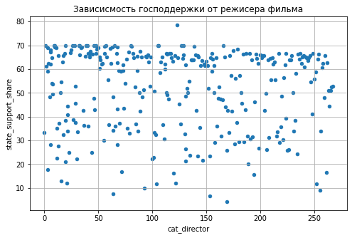

```python
data_st_sup.plot(kind='scatter', y='state_support_share', x='cat_director', grid=True, title='Зависисмость господдержки от режисера фильма', figsize=(8,5));
```

```python
data_st_sup['cat_director'].corr(data_st_sup['state_support_share'])
```

```
-0.05583167359759007
```

Значения корреляции говорят, что связи практически никакой нет.

```python
uniq = data_st_sup['director'].unique()
```

Сгруппируем данные по режисеру и расчитаем кол-во фильмов снятое режисером с гос поддержкой и среднюю господдержку по этому режисера  
Отсортируем результат по убыванию кол-ва снятых фильмов и ограничим вывод кол-вом более 1 снятого фильма:

```python
pt = pd.pivot_table(data_st_sup, index='director', values=['state_support_share', 'ratings'], aggfunc={'state_support_share':['count', 'mean'], 'ratings':'mean'}).reset_index().round(2)
pt.columns = ['director','ratings_ss','count_ss', 'mean_ss']
pt.sort_values('count_ss' , ascending=False)
pt[pt['count_ss'] > 1].sort_values('count_ss' , ascending=False)
```

|  | director | ratings_ss | count_ss | mean_ss |
| --- | --- | --- | --- | --- |
| 209 | Р.Давлетьяров | 7.15 | 4 | 56.38 |
| 96 | Д.Дьяченко | 5.65 | 4 | 50.94 |
| 218 | С.Андреасян | 6.02 | 4 | 39.59 |
| 1 | А.(псевдоним | 6.17 | 3 | 30.05 |
| 159 | К.Шипенко | 6.83 | 3 | 45.27 |
| 109 | Е.(псевдоним | 5.17 | 3 | 48.60 |
| 3 | А.Аксененко | 5.30 | 3 | 39.79 |
| 225 | С.Мокрицкий | 6.60 | 3 | 43.15 |
| 201 | П.Руминов | 6.80 | 2 | 42.08 |
| 200 | П.Лунгин | 6.30 | 2 | 57.71 |
| 212 | Р.Каримов | 5.80 | 2 | 65.63 |
| 173 | М.Свешников | 3.00 | 2 | 69.70 |
| 172 | М.Расходников | 6.20 | 2 | 55.82 |
| 161 | М.(псевдоним | 4.90 | 2 | 53.01 |
| 158 | К.Худяков | 6.70 | 2 | 62.81 |
| 132 | И.Твердовский | 6.05 | 2 | 61.00 |
| 131 | И.Северов | 5.60 | 2 | 62.62 |
| 226 | С.Подгаевский | 4.65 | 2 | 58.34 |
| 188 | Н.Хомерики | 6.15 | 2 | 67.94 |
| 100 | Д.Месхиев | 6.80 | 2 | 33.75 |
| 89 | В.Хотиненко | 5.75 | 2 | 68.31 |
| 86 | В.Тодоровский | 7.45 | 2 | 44.48 |
| 77 | В.Глаголева | 6.25 | 2 | 59.44 |
| 63 | А.Цицилин | 6.30 | 2 | 46.76 |
| 60 | А.Федорченко | 6.65 | 2 | 68.03 |
| 57 | А.Темников | 6.75 | 2 | 68.05 |
| 48 | А.Прошкин | 5.55 | 2 | 49.06 |
| 45 | А.Пиманов | 4.75 | 2 | 28.90 |
| 35 | А.Матисон | 5.90 | 2 | 62.40 |
| 28 | А.Котт | 6.30 | 2 | 55.02 |
| 23 | А.Карпиловский | 6.85 | 2 | 58.81 |
| 15 | А.Галибин | 7.00 | 2 | 60.64 |
| 14 | А.Волгин | 5.65 | 2 | 14.99 |
| 13 | А.Войтинский | 5.75 | 2 | 51.56 |
| 11 | А.Богуславский | 5.20 | 2 | 15.10 |
| 246 | Ф.Дмитриев | 6.80 | 2 | 51.41 |

Посмотрим есть ли какая-то связь между кол-вом снятых фильмов и господдержкой:

```python
pt1 = pd.pivot_table(pt, index='count_ss', values='mean_ss').reset_index()
```

```python
pt1['count_ss'].corr(pt1['mean_ss'])
```

```
-0.5167052835857882
```

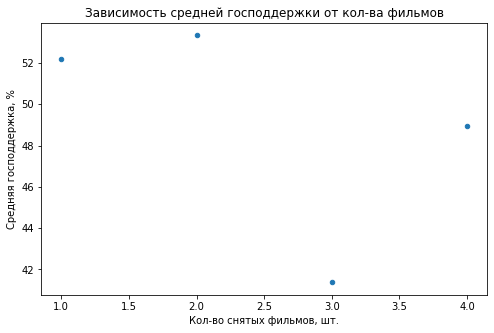

```python
pt1.plot(kind='scatter', x='count_ss', y='mean_ss', figsize=(8,5), xlabel='Кол-во снятых фильмов, шт.', ylabel='Средняя господдержка, %', title='Зависимость средней господдержки от кол-ва фильмов');
```

Есть не очень сильная отрицательная зависимость - снижение господдержки с ростом кол-ва снятых фильмов с поддержкой

В целом мы видим, что есть компании, которые снимают фильмов с господдеркой больше чем остальные. Проверим сколько сняли эти же компании без господдержки:

Выберем данные, в которых отсутствует информация по господдержке и посчитаем кол-во выпущенных ими фильмов с 2010 по 2019 (весь период) и средний рейтинг:

```python
pt1 = data[data['state_support_share'] < 0].pivot_table(index='director', values=['title','ratings'], aggfunc={'title':'count', 'ratings':'mean'}).reset_index().round(2).sort_values('title', ascending=False)
pt1.columns = ['director','ratings','q-ty']
pt1
```

|  | director | ratings | q-ty |
| --- | --- | --- | --- |
| 3015 | О.Семёнова | 0.68 | 63 |
| 1665 | Д.Червяцов | 1.33 | 18 |
| 3649 | С.Содерберг | 7.11 | 17 |
| 3374 | Р.Скотт | 7.09 | 16 |
| 3674 | С.Уайт | 5.70 | 15 |
| ... | ... | ... | ... |
| 1740 | Е.Гроховская | 6.30 | 1 |
| 1741 | Е.Гусева | 7.10 | 1 |
| 1742 | Е.Данченко | 0.00 | 1 |
| 1743 | Е.Дербез | 7.60 | 1 |
| 2229 | К.Статский, Е.Соломина, А.Баршак | 1.40 | 1 |

4459 rows × 3 columns

объеденим два дата фрейма в один и получин информацию по каждому режисеру - рейтинг фильма с господдержкой, кол-во фильмов с господдержкой, средняя доля господдержки и средний рейтинг фильмов без господдержки, кол-во фильмов без господдержкис 2010 по 2019:

```python
pt.merge(pt1, how='left', on='director').sort_values('count_ss', ascending=False).fillna(0).round(2).head(36)
```

|  | director | ratings_ss | count_ss | mean_ss | ratings | q-ty |
| --- | --- | --- | --- | --- | --- | --- |
| 209 | Р.Давлетьяров | 7.15 | 4 | 56.38 | 4.60 | 3.0 |
| 96 | Д.Дьяченко | 5.65 | 4 | 50.94 | 6.88 | 4.0 |
| 218 | С.Андреасян | 6.02 | 4 | 39.59 | 3.50 | 7.0 |
| 225 | С.Мокрицкий | 6.60 | 3 | 43.15 | 5.10 | 1.0 |
| 3 | А.Аксененко | 5.30 | 3 | 39.79 | 5.80 | 4.0 |
| 159 | К.Шипенко | 6.83 | 3 | 45.27 | 7.07 | 3.0 |
| 109 | Е.(псевдоним | 5.17 | 3 | 48.60 | 4.48 | 5.0 |
| 1 | А.(псевдоним | 6.17 | 3 | 30.05 | 4.09 | 9.0 |
| 35 | А.Матисон | 5.90 | 2 | 62.40 | 6.45 | 2.0 |
| 172 | М.Расходников | 6.20 | 2 | 55.82 | 6.00 | 1.0 |
| 173 | М.Свешников | 3.00 | 2 | 69.70 | 0.00 | 0.0 |
| 45 | А.Пиманов | 4.75 | 2 | 28.90 | 0.00 | 0.0 |
| 48 | А.Прошкин | 5.55 | 2 | 49.06 | 7.00 | 2.0 |
| 226 | С.Подгаевский | 4.65 | 2 | 58.34 | 4.65 | 2.0 |
| 100 | Д.Месхиев | 6.80 | 2 | 33.75 | 7.20 | 1.0 |
| 57 | А.Темников | 6.75 | 2 | 68.05 | 0.00 | 0.0 |
| 28 | А.Котт | 6.30 | 2 | 55.02 | 5.48 | 4.0 |
| 60 | А.Федорченко | 6.65 | 2 | 68.03 | 3.08 | 4.0 |
| 63 | А.Цицилин | 6.30 | 2 | 46.76 | 0.00 | 0.0 |
| 188 | Н.Хомерики | 6.15 | 2 | 67.94 | 6.27 | 3.0 |
| 212 | Р.Каримов | 5.80 | 2 | 65.63 | 6.85 | 4.0 |
| 89 | В.Хотиненко | 5.75 | 2 | 68.31 | 0.00 | 1.0 |
| 77 | В.Глаголева | 6.25 | 2 | 59.44 | 0.00 | 0.0 |
| 86 | В.Тодоровский | 7.45 | 2 | 44.48 | 6.70 | 2.0 |
| 201 | П.Руминов | 6.80 | 2 | 42.08 | 4.10 | 2.0 |
| 246 | Ф.Дмитриев | 6.80 | 2 | 51.41 | 0.00 | 0.0 |
| 200 | П.Лунгин | 6.30 | 2 | 57.71 | 6.70 | 1.0 |
| 14 | А.Волгин | 5.65 | 2 | 14.99 | 0.00 | 1.0 |
| 15 | А.Галибин | 7.00 | 2 | 60.64 | 0.00 | 0.0 |
| 13 | А.Войтинский | 5.75 | 2 | 51.56 | 6.80 | 1.0 |
| 158 | К.Худяков | 6.70 | 2 | 62.81 | 7.20 | 2.0 |
| 23 | А.Карпиловский | 6.85 | 2 | 58.81 | 7.20 | 1.0 |
| 132 | И.Твердовский | 6.05 | 2 | 61.00 | 6.80 | 1.0 |
| 131 | И.Северов | 5.60 | 2 | 62.62 | 0.00 | 0.0 |
| 11 | А.Богуславский | 5.20 | 2 | 15.10 | 0.00 | 0.0 |
| 161 | М.(псевдоним | 4.90 | 2 | 53.01 | 0.00 | 2.0 |

Мы видим, что в отличии от студий режисеры снимают и фильмы с господдержкой и без поддержки. Мы также можем видеть, что у фильмов с господдержкой рейтинг такой же, как и фильмов без господдержки: 5.62(с господдержкой) против - 5.21(без господдержки). Это может говорить, что наличие и отсутствие господдержки не оказывает влияния на съемки фильма режисером. Что достаточно логично - режисер заботиться о своем имидже.

### 4.4. Связь продюсера фильма и господдержки

Посмотрим сколько раз тот или иной продюсер снимал фильмы, с господдержкой:

```python
data_st_sup['producer'].value_counts()
```

```
С.Сельянов                                         8
А.Боярский, С.Сельянов                             7
А.Рязанцев, Ю.Обухов                               4
Е.Маскина, С.Говорухин                             4
Е.Мелентьев, В.Денисюк                             3
                                                  ..
А.Рязанцев, В.Поляков, Г.Андреасян, С.Андреасян    1
О."ВИЗАРТ                                          1
В.Поляков, Г.Малков                                1
Д.Литвинов, В.Хотиненко                            1
А.Войтинский, В.Поляков, Л.Карасев, Г.Малков       1
Name: producer, Length: 256, dtype: int64
```

Здесь уже наблюдается небольшая зависимость, какие-то продюсеры снимали фильмы с господдержкой несколько раз, а какие-то только единожды  
продолжим наш анализ дальше:

Найдем уникальные значения столбца продюсер фильма и их кол-во:

```python
data_st_sup['producer'].unique()
```

```
array(['М.Бабаханов, Р.Бутко, А.Атанесян', 'А.Тютрюмов',
       'А.Котелевский, А.Олейников, Р.Давлетьяров', 'Л.Антонова',
       'Л.Антонова, А.Миндадзе', 'А.Герасимов', 'нет данных', 'Н.Иванова',
       'С.Сельянов', 'В.Сидоренко', 'Е.Аронова, Т.Бекмамбетов',
       'Т.Яковенко', 'О.Погодина, А.Пиманов', 'О."ТаББаК", О."ВИЗАРТ',
       'А.Стриженов, Л.Лищинская, Л.Якубович', 'К.Шахназаров, А.Литвинов',
       'И.Угольников', 'С.Новиков, А.Феофанов', 'Д.Пиркулов',
       'А.Рязанцев, Ю.Обухов', 'Е.Олесов, Н.Мокрицкая', 'А.Мельник',
       'В.Муругов, В.Поляков, И.Капитонов, Г.Малков', 'Ю.Кара',
       'А.Новиков', 'Н.Будкина', 'С.Зернов, С.Кучмаева', 'О."ПЦ, О."Грин',
       'А.Пискунова, Ю.Арабов, Э.Архангельская', 'О."ММЕ", Р.Дишдишян',
       'И.Каленов', 'С.Мелькумов, А.Роднянский',
       'А.Федорченко, Л.Лебедев, Д.Воробьев', 'И.Плиско', 'Ф.Попов',
       'А.Меликян', 'А.Котелевский, Р.Давлетьяров', 'Я.Живов, Е.Гликман',
       'В.Пономаренко, Д.Ефремов', 'И.Букреев, П.Поляков',
       'А.Боярский, С.Сельянов', 'А.Котелевский, А.Новиков',
       'Е.Маскина, С.Говорухин', 'Н.Расторгуев, И.Николенко', 'В.Есинов',
       'К.Гечмен-Вальдек, Н.Горшкова, Ж.Пиччоли', 'В.Хотиненко, С.Кравец',
       'А.Алькема, А.Бельская, А.Виткин, В.Малый, Г.Подземельный, К.Виткин, Р.Давлетьяров',
       'Н.Гостюшина, И.Мишин', 'Э.Пичугин', 'А.Ананикян',
       'О."Беркана", О."ММЕ", Р.Дишдишян',
       'Д.Рудовский, Ф.Бондарчук, И.Попов', 'А.Васильев',
       'А.Новин, А.Темникова, Е.Бренькова, Е.Миронов',
       'Ф.Попов, В.Малышев',
       'А.Качко, А.Новин, А.Темникова, Д.Аронин, Е.Бренькова, И.Гаврилов, Е.Миронов',
       'М.Затуловская, Т.Бекмамбетов',
       'Д.Жалинский, Р.Гигинеишвили, Э.Родоная, Э.Илоян', 'Т.Бекмамбетов',
       'А.Казаков, А.(псевдоним, С.Корнихин, Т.Бекмамбетов',
       'В.Щербин, О.Степанцова, А.Сафронов', 'Р.Давлетьяров',
       'В.Зорин, Р.Атоян', 'С.Кучмаева, С.Зернов',
       'Р.Татаринцев, Э.Илоян, Г.Шабанов',
       'М.Дегтярь, Я.Живов, Е.Гликман',
       'А.Анненский, В.Харьков, Л.Антонова, Л.Блаватник, Х.Декерт, А.Миндадзе',
       'Р.Сорокин, А.Цекало', 'А.Шютте, Ш.Арндт, А.Гуськов', 'Б.Токарев',
       'Е.Мелентьев', 'Г.Палагаев, И.Охлобыстин, Л.Калинский',
       'А.Шальопа',
       'А.Рубцов, А.Троцюк, В.Шляппо, Д.Дьяченко, Д.Жалинский, М.Ткаченко, Э.Илоян',
       'А.Готлиб', 'О."Кинокомпания, О."ВИЗАРТ', 'Е.Белова',
       'А.Златопольский, Н.Михалков, О."Студия, Л.Верещагин',
       'М.Ксинопуло, Н.Иванова',
```

[output cut: 100 more lines]

```
       'А.Пескова, Д.Тульчинский, С.Квашилава, Ю.Храпов, В.Соловьев',
       'Д.Якунин, О.Лахно, Ф.Абрютин', 'К.Саксаганская, А.Учитель',
       'Н.Фонд', 'А.Разуваева, Ю.Перкуль, И.Добровольский',
       'А.Леонтьев, И.Добровольский, Ю.Перкуль, О.Ледяева',
       'В.Маслов, И.Магомедов, Б.Анисимов', 'К.Оганисян',
       'А.Камынин, А.Седых, В.Галыгин, В.Колесник, Г.Атаев, Е.Михайлова',
       'В.Поляков, Г.Малков, М.Кучмент, С.Бобза', 'О.Капанец',
       'Ю.Соболевская',
       'В.Ряшин, И.Бурец, М.Абрамов, Н.Трынкин, О.Филипук, Ф.Ламшин, П.Зарукин',
       'И.Попов, С.Саркисов, Г.Васильев',
       'А.Кушаев, А.Троцюк, В.Верещагин, В.Дусмухаметов, В.Шляппо, Д.Жалинский, Р.Минасбекян, Т.Бадзиев, Э.Илоян',
       'К.Эрнст, А.Максимов',
       'А.Андрющенко, Д.Рудовский, М.Врубель, Ф.Бондарчук',
       'А.Роднянский, М.Вайсберг, Р.Минасбекян, С.Мелькумов'],
      dtype=object)
```

```python
len(data_st_sup['producer'].unique())
```

```
256
```

Создадим категориальный столбец для режисера фильма:

```python
data_st_sup['cat_producer'] = pd.Categorical(data_st_sup['producer'], data_st_sup['producer'].unique()).codes
data_st_sup['cat_producer'] = data_st_sup['cat_producer'].astype('category')
```

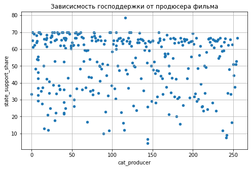

```python
data_st_sup.plot(kind='scatter', y='state_support_share', x='cat_producer', grid=True, title='Зависисмость господдержки от продюсера фильма', figsize=(8,5));
```

```python
data_st_sup['cat_producer'].corr(data_st_sup['state_support_share'])
```

```
-0.0780924105619028
```

Значения корреляции говорят, что связи практически никакой нет.

```python
uniq = data_st_sup['producer'].unique()
```

Сгруппируем данные по продюсеру и расчитаем кол-во фильмов снятое продюсером с гос поддержкой и среднюю господдержку по этому продюсеру  
Отсортируем результат по убыванию кол-ва снятых фильмов и ограничим вывод кол-вом более 1 снятого фильма:

```python
pt = pd.pivot_table(data_st_sup, index='producer', values=['state_support_share', 'ratings'], aggfunc={'state_support_share':['count', 'mean'], 'ratings':'mean'}).reset_index().round(2)
pt.columns = ['producer','ratings_ss','count_ss', 'mean_ss']
pt.sort_values('count_ss' , ascending=False)
pt[pt['count_ss'] > 1].sort_values('count_ss' , ascending=False)
```

|  | producer | ratings_ss | count_ss | mean_ss |
| --- | --- | --- | --- | --- |
| 234 | С.Сельянов | 6.15 | 8 | 40.83 |
| 11 | А.Боярский, С.Сельянов | 6.31 | 7 | 41.45 |
| 70 | А.Рязанцев, Ю.Обухов | 5.38 | 4 | 59.70 |
| 144 | Е.Маскина, С.Говорухин | 5.83 | 4 | 54.37 |
| 246 | Э.Пичугин | 5.67 | 3 | 61.35 |
| 223 | С.Еремеева | 5.83 | 3 | 56.64 |
| 204 | О."ММЕ", Р.Дишдишян | 5.87 | 3 | 45.16 |
| 192 | Н.Мокрицкая | 5.67 | 3 | 63.99 |
| 146 | Е.Мелентьев, В.Денисюк | 4.80 | 3 | 12.29 |
| 81 | А.Тютрюмов | 1.57 | 3 | 68.33 |
| 151 | Е.Филиппова | 6.00 | 3 | 52.85 |
| 57 | А.Петрухин | 6.60 | 2 | 47.72 |
| 102 | В.Муругов, В.Поляков, И.Капитонов, Г.Малков | 4.45 | 2 | 37.52 |
| 18 | А.Голутва | 6.25 | 2 | 41.09 |
| 244 | Ф.Попов, В.Малышев | 7.05 | 2 | 68.37 |
| 242 | Ф.Попов | 3.10 | 2 | 53.88 |
| 237 | Т.Бекмамбетов | 3.90 | 2 | 69.42 |
| 19 | А.Готлиб | 5.25 | 2 | 66.08 |
| 232 | С.Мелькумов, А.Роднянский | 6.75 | 2 | 49.72 |
| 224 | С.Зернов | 5.30 | 2 | 64.97 |
| 28 | А.Златопольский, Н.Михалков, О."Студия, Л.Вере... | 7.55 | 2 | 68.68 |
| 218 | Р.Татаринцев, Э.Илоян, Г.Шабанов | 6.10 | 2 | 57.66 |
| 47 | А.Меликян | 6.60 | 2 | 36.08 |
| 200 | О."Кинокомпания, О."ВИЗАРТ | 6.25 | 2 | 34.40 |
| 195 | Н.Янкин | 6.60 | 2 | 65.60 |
| 50 | А.Новиков | 3.10 | 2 | 65.50 |
| 191 | Н.Иванова | 6.25 | 2 | 59.44 |
| 187 | Н.Будкина | 6.15 | 2 | 67.76 |
| 162 | К.Буслов | 5.35 | 2 | 55.46 |
| 161 | И.Угольников | 3.55 | 2 | 39.42 |
| 12 | А.Васильев | 6.25 | 2 | 27.96 |
| 53 | А.Новин, А.Темникова, Е.Бренькова, Е.Миронов | 6.75 | 2 | 68.05 |
| 54 | А.Остапко, Е.Борисова | 5.45 | 2 | 64.00 |
| 143 | Е.Гордецкая, А.Радько | 3.80 | 2 | 66.62 |
| 122 | Г.Стрижевская, Т.Бекмамбетов | 6.35 | 2 | 56.50 |
| 117 | Г.Андреасян, С.Андреасян, А.Ананикян | 5.75 | 2 | 35.71 |
| 255 | нет данных | 7.30 | 2 | 65.96 |

Посмотрим есть ли какая-то связь между кол-вом снятых фильмов и господдержкой:

```python
pt1 = pd.pivot_table(pt, index='count_ss', values='mean_ss').reset_index()
```

```python
pt1['count_ss'].corr(pt1['mean_ss'])
```

```
-0.8155463738020683
```

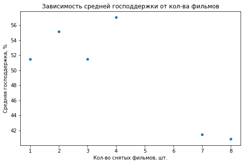

```python
pt1.plot(kind='scatter', x='count_ss', y='mean_ss', figsize=(8,5), xlabel='Кол-во снятых фильмов, шт.', ylabel='Средняя господдержка, %', title='Зависимость средней господдержки от кол-ва фильмов');
```

Есть отрицательная зависимость - снижение господдержки с ростом кол-ва снятых фильмов с поддержкой

В целом мы видим, что есть продюсеры, которые снимают фильмов с господдеркой больше чем остальные. Проверим сколько сняли эти же продюсеры без господдержки:

Выберем данные, в которых отсутствует информация по господдержке и посчитаем кол-во снятых ими фильмов с 2010 по 2019 (весь период) и средний рейтинг:

```python
pt1 = data[data['state_support_share'] < 0].pivot_table(index='producer', values=['title','ratings'], aggfunc={'title':'count', 'ratings':'mean'}).reset_index().round(2).sort_values('title', ascending=False)
pt1.columns = ['producer','ratings',	'q-ty']
pt1
```

|  | producer | ratings | q-ty |
| --- | --- | --- | --- |
| 5084 | нет данных | 5.89 | 566 |
| 4126 | П.Смирнов | 0.62 | 69 |
| 1902 | Д.Ловейко, М.Ратина, О.Кузовков | 1.30 | 28 |
| 3986 | О.Кузовков, Д.Ловейко | 0.93 | 17 |
| 604 | А.Тельнов | 3.32 | 12 |
| ... | ... | ... | ... |
| 1810 | Д.Клифтон, П.Сафран, Д.Блум | 4.30 | 1 |
| 1809 | Д.Клифтон, Д.Брукс | 5.30 | 1 |
| 1807 | Д.Клейкенс | 6.40 | 1 |
| 1806 | Д.Клацкевич, Б.Брайн | 7.80 | 1 |
| 5085 | с.Дональд, Т.Ковент-Гарден | 0.00 | 1 |

5086 rows × 3 columns

объеденим два дата фрейма в один и получин информацию по каждому прдюсеру - рейтинг фильма с господдержкой, кол-во фильмов с господдержкой, средняя доля господдержки и средний рейтинг фильмов без господдержки, кол-во фильмов без господдержкис 2010 по 2019:

```python
pt.merge(pt1, how='left', on='producer').sort_values('count_ss', ascending=False).fillna(0).round(2).head(36)
```

|  | producer | ratings_ss | count_ss | mean_ss | ratings | q-ty |
| --- | --- | --- | --- | --- | --- | --- |
| 234 | С.Сельянов | 6.15 | 8 | 40.83 | 5.92 | 10.0 |
| 11 | А.Боярский, С.Сельянов | 6.31 | 7 | 41.45 | 7.35 | 2.0 |
| 144 | Е.Маскина, С.Говорухин | 5.83 | 4 | 54.37 | 6.78 | 5.0 |
| 70 | А.Рязанцев, Ю.Обухов | 5.38 | 4 | 59.70 | 4.80 | 1.0 |
| 151 | Е.Филиппова | 6.00 | 3 | 52.85 | 0.00 | 0.0 |
| 223 | С.Еремеева | 5.83 | 3 | 56.64 | 6.47 | 3.0 |
| 246 | Э.Пичугин | 5.67 | 3 | 61.35 | 4.25 | 6.0 |
| 81 | А.Тютрюмов | 1.57 | 3 | 68.33 | 4.00 | 3.0 |
| 204 | О."ММЕ", Р.Дишдишян | 5.87 | 3 | 45.16 | 6.57 | 3.0 |
| 192 | Н.Мокрицкая | 5.67 | 3 | 63.99 | 4.27 | 6.0 |
| 146 | Е.Мелентьев, В.Денисюк | 4.80 | 3 | 12.29 | 6.20 | 3.0 |
| 195 | Н.Янкин | 6.60 | 2 | 65.60 | 6.70 | 1.0 |
| 54 | А.Остапко, Е.Борисова | 5.45 | 2 | 64.00 | 6.50 | 3.0 |
| 117 | Г.Андреасян, С.Андреасян, А.Ананикян | 5.75 | 2 | 35.71 | 0.00 | 0.0 |
| 53 | А.Новин, А.Темникова, Е.Бренькова, Е.Миронов | 6.75 | 2 | 68.05 | 0.00 | 1.0 |
| 50 | А.Новиков | 3.10 | 2 | 65.50 | 5.75 | 2.0 |
| 102 | В.Муругов, В.Поляков, И.Капитонов, Г.Малков | 4.45 | 2 | 37.52 | 0.00 | 0.0 |
| 57 | А.Петрухин | 6.60 | 2 | 47.72 | 5.80 | 1.0 |
| 218 | Р.Татаринцев, Э.Илоян, Г.Шабанов | 6.10 | 2 | 57.66 | 0.00 | 0.0 |
| 162 | К.Буслов | 5.35 | 2 | 55.46 | 6.50 | 1.0 |
| 187 | Н.Будкина | 6.15 | 2 | 67.76 | 0.00 | 0.0 |
| 200 | О."Кинокомпания, О."ВИЗАРТ | 6.25 | 2 | 34.40 | 0.00 | 0.0 |
| 224 | С.Зернов | 5.30 | 2 | 64.97 | 3.85 | 2.0 |
| 232 | С.Мелькумов, А.Роднянский | 6.75 | 2 | 49.72 | 7.10 | 2.0 |
| 191 | Н.Иванова | 6.25 | 2 | 59.44 | 6.75 | 2.0 |
| 28 | А.Златопольский, Н.Михалков, О."Студия, Л.Вере... | 7.55 | 2 | 68.68 | 0.00 | 0.0 |
| 47 | А.Меликян | 6.60 | 2 | 36.08 | 0.00 | 0.0 |
| 255 | нет данных | 7.30 | 2 | 65.96 | 5.89 | 566.0 |
| 12 | А.Васильев | 6.25 | 2 | 27.96 | 0.00 | 0.0 |
| 122 | Г.Стрижевская, Т.Бекмамбетов | 6.35 | 2 | 56.50 | 0.00 | 0.0 |
| 143 | Е.Гордецкая, А.Радько | 3.80 | 2 | 66.62 | 0.00 | 0.0 |
| 237 | Т.Бекмамбетов | 3.90 | 2 | 69.42 | 6.28 | 4.0 |
| 244 | Ф.Попов, В.Малышев | 7.05 | 2 | 68.37 | 0.00 | 0.0 |
| 242 | Ф.Попов | 3.10 | 2 | 53.88 | 6.65 | 4.0 |
| 18 | А.Голутва | 6.25 | 2 | 41.09 | 7.00 | 1.0 |
| 19 | А.Готлиб | 5.25 | 2 | 66.08 | 4.90 | 4.0 |

Мы видим, что в отличии от студий продюсеры снимают и фильмы с господдержкой и без поддержки. Мы также можем видеть, что у фильмов с господдержкой рейтинг такой же, как и фильмов без господдержки: 5.70(с господдержкой) против - 5.40(без господдержки). Это может говорить, что наличие и отсутствие господдержки не оказывает влияния на съемки фильма продюсером. Что достаточно логично - продюсер заботиться о своем имидже.

### 4.5. Связь возрастных ограничений и господдержки

Посмотрим сколько фильмов с различными возрастными ограничениями было снято с господдержкой:

```python
data_st_sup['age_restriction'].value_counts()
```

```
«16+» - для детей старше 16 лет           118
«12+» - для детей старше 12 лет           103
«6+» - для детей старше 6 лет              59
«18+» - запрещено для детей                27
«0+» - для любой зрительской аудитории      8
Name: age_restriction, dtype: int64
```

Здесь мы видим что максимальные значения по кол-ву выпущенных в прокат фильмов имеют категории "16+" и "12+"  
продолжим наш анализ дальше:

Найдем уникальные значения столбца возрастные ограничения и их кол-во:

```python
data_st_sup['age_restriction'].unique()
```

```
array(['«16+» - для детей старше 16 лет',
       '«12+» - для детей старше 12 лет', '«6+» - для детей старше 6 лет',
       '«0+» - для любой зрительской аудитории',
       '«18+» - запрещено для детей'], dtype=object)
```

```python
len(data_st_sup['age_restriction'].unique())
```

```
5
```

Создадим категориальный столбец для возрастных ограничений фильма:

```python
data_st_sup['cat_age_restriction'] = pd.Categorical(data_st_sup['age_restriction'], data_st_sup['age_restriction'].unique()).codes
data_st_sup['cat_age_restriction'] = data_st_sup['cat_age_restriction'].astype('category')
```

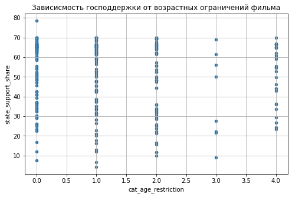

```python
data_st_sup.plot(kind='scatter', y='state_support_share', x='cat_age_restriction', grid=True, title='Зависисмость господдержки от возрастных ограничений фильма', figsize=(8,5));
```

```python
data_st_sup['cat_age_restriction'].corr(data_st_sup['state_support_share'])
```

```
-0.11742178982342626
```

Значения корреляции говорят, что связи практически никакой нет.

```python
uniq = data_st_sup['age_restriction'].unique()
```

Сгруппируем данные по возрастным ограничениям и расчитаем кол-во фильмов снятое с тем или иным возрастным огрничением с гос поддержкой и среднюю господдержку по этому возрастному ограничению  
Отсортируем результат по убыванию кол-ва снятых фильмов и ограничим вывод кол-вом более 1 снятого фильма:

```python
pt = pd.pivot_table(data_st_sup, index='age_restriction', values=['state_support_share', 'ratings'], aggfunc={'state_support_share':['count', 'mean'], 'ratings':'mean'}).reset_index().round(2)
pt.columns = ['age_restriction','ratings_ss','count_ss', 'mean_ss']
pt.sort_values('count_ss' , ascending=False)
pt[pt['count_ss'] > 1].sort_values('count_ss' , ascending=False)
```

|  | age_restriction | ratings_ss | count_ss | mean_ss |
| --- | --- | --- | --- | --- |
| 2 | «16+» - для детей старше 16 лет | 5.68 | 118 | 54.47 |
| 1 | «12+» - для детей старше 12 лет | 5.64 | 103 | 51.54 |
| 4 | «6+» - для детей старше 6 лет | 5.77 | 59 | 48.48 |
| 3 | «18+» - запрещено для детей | 5.80 | 27 | 51.24 |
| 0 | «0+» - для любой зрительской аудитории | 5.61 | 8 | 39.68 |

Посмотрим есть ли какая-то связь между кол-вом снятых фильмов с учетом возрастных ограничений и господдержкой:

```python
pt1 = pd.pivot_table(pt, index='count_ss', values='mean_ss').reset_index()
```

```python
pt1['count_ss'].corr(pt1['mean_ss'])
```

```
0.7795156449002477
```

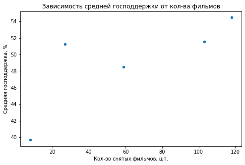

```python
pt1.plot(kind='scatter', x='count_ss', y='mean_ss', figsize=(8,5), xlabel='Кол-во снятых фильмов, шт.', ylabel='Средняя господдержка, %', title='Зависимость средней господдержки от кол-ва фильмов');
```

Есть сильная прямая зависимость - рост доли господдержки с ростом кол-ва снятых фильмов

Посмотрим, какой рейтинг имеют фильмы без господдержки по возрастным ограничениям:

Выберем данные, в которых отсутствует информация по господдержке и посчитаем кол-во выпущенных ими фильмов с 2010 по 2019 (весь период) и средний рейтинг:

```python
pt1 = data[data['state_support_share'] < 0].pivot_table(index='age_restriction', values=['title','ratings'], aggfunc={'title':'count', 'ratings':'mean'}).reset_index().round(2).sort_values('title', ascending=False)
pt1.columns = ['age_restriction','ratings',	'q-ty']
pt1
```

|  | age_restriction | ratings | q-ty |
| --- | --- | --- | --- |
| 2 | «16+» - для детей старше 16 лет | 6.04 | 2733 |
| 3 | «18+» - запрещено для детей | 5.90 | 1578 |
| 1 | «12+» - для детей старше 12 лет | 5.62 | 1489 |
| 0 | «0+» - для любой зрительской аудитории | 3.73 | 803 |
| 4 | «6+» - для детей старше 6 лет | 5.42 | 567 |

объеденим два дата фрейма в один и получин информацию по каждому режисеру - рейтинг фильма с господдержкой, кол-во фильмов с господдержкой, средняя доля господдержки и средний рейтинг фильмов без господдержки, кол-во фильмов без господдержкис 2010 по 2019:

```python
pt.merge(pt1, how='left', on='age_restriction').sort_values('count_ss', ascending=False)
```

|  | age_restriction | ratings_ss | count_ss | mean_ss | ratings | q-ty |
| --- | --- | --- | --- | --- | --- | --- |
| 2 | «16+» - для детей старше 16 лет | 5.68 | 118 | 54.47 | 6.04 | 2733 |
| 1 | «12+» - для детей старше 12 лет | 5.64 | 103 | 51.54 | 5.62 | 1489 |
| 4 | «6+» - для детей старше 6 лет | 5.77 | 59 | 48.48 | 5.42 | 567 |
| 3 | «18+» - запрещено для детей | 5.80 | 27 | 51.24 | 5.90 | 1578 |
| 0 | «0+» - для любой зрительской аудитории | 5.61 | 8 | 39.68 | 3.73 | 803 |

Мы видим, что возрастные ограничения фильмов с господдержкой и без поддержки практически одинаковы. Есть пара моментов: первый - фильмы "18+" с гос поддержкой снимаются реже (4 место в списке) чем без господдержки(занимает 2 место по кол-ву фильмов). Это может говорить о том, что господдержка направлена на фильмы с широкой аудиторией(для детей и взрослых). Второй момент - фильмы для "0+" с господдержкой имеют более высокий средний рейтинг, чем фильмы без господдержки. Возникает гипотеза, что есть определенные требования к фильмам с гос поддержкой по качеству материала и всем прочим моментам съемок, ниже которых финансирование не осуществляется. В целом у фильмов с господдержкой рейтинг такой же, как и фильмов без господдержки: 5.7(с господдержкой) против - 5.34(без господдержки).

### 4.6. Связь рейтинга фильма и господдержки

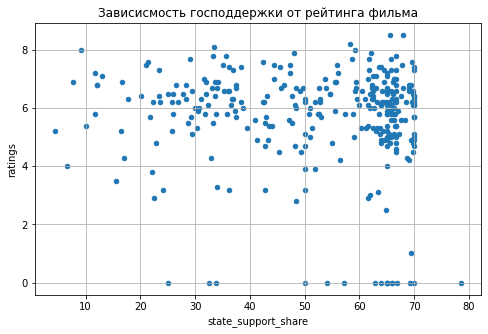

```python
data_st_sup.plot(kind='scatter', x='state_support_share', y='ratings', grid=True, title='Зависисмость господдержки от рейтинга фильма', figsize=(8,5));
```

```python
data_st_sup['ratings'].corr(data_st_sup['state_support_share'])
```

```
-0.08551210671245976
```

Согласно результату связь отсутствует

Посмотрим зависимость рейтинга от года выпуска в прокат:

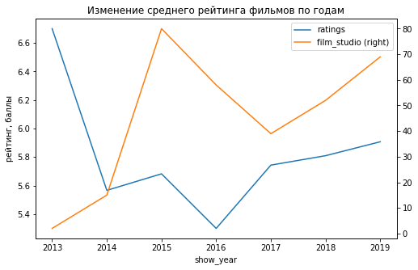

```python
ax = pd.pivot_table(data_st_sup, values='ratings', index='show_year').fillna(0).reset_index().plot(x='show_year',
y='ratings', title='Изменение среднего рейтинга фильмов по годам',figsize=(8,5), xlabel='Годы выпуска фильмов', ylabel='рейтинг, баллы', grid=True);
pd.pivot_table(data_st_sup, index='show_year', values='film_studio', aggfunc='count').reset_index().plot(
    x='show_year', y='film_studio',secondary_y=True, ax=ax
)
```

Средний рейтинг фильмов в 2013 году был достаточно высоким, затем 2014 произошло снижение, с падением до нижнего значения в 2016.Скорее всего в 2016 году государственными органами были приняты по прекращению финансирования студий выпускающих фильмы с низким рейтингом, после чего кол-во студий временно упало и с 2017 начало рости вместе со средним рейтингом фильмов.

Посмотрим на рейтинг фильмов с господдержкой и без господдержки

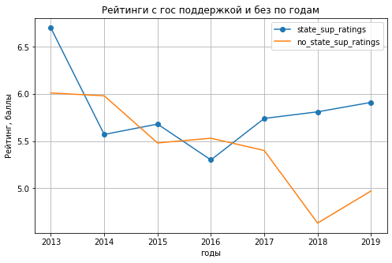

```python
s1 = pd.pivot_table(data_st_sup, index='show_year', values='ratings', aggfunc='mean').reset_index().round(2)
s1.columns = ['show_year','state_sup_ratings']
ax = s1.plot(x='show_year',y='state_sup_ratings', style='o-', grid=True, figsize=(8,5))
s2 = data.query('state_support_share < 0').pivot_table(index='show_year', values='ratings', aggfunc='mean').reset_index().tail(7).round(2)
s2.columns = ['show_year','no_state_sup_ratings']
s2.plot(x='show_year',y='no_state_sup_ratings', ax=ax, title='Рейтинги с гос поддержкой и без по годам', xlabel='годы', ylabel='Рейтинг, баллы', grid=True);
```

### 4.7. Связь жанра фильма и господдержки

Жанр фильма является категориальным столбцов и самое главное строковым. Невозможно искать связь между строковым значением и числовым. Для этого нужно перевести строковое значение в числовое, или другими словами закодировать столбец 'genres'

Закодирем тип фильма кол-вом появлений в дата фрейме:

```python
data_st_sup['movie_genre'].value_counts()
```

```
драма          99
комедия        90
боевик         25
военный        22
детектив       14
биография      11
мультфильм      9
детский         7
триллер         7
приключения     6
мелодрама       6
ужасы           5
криминал        4
фантастика      2
семейный        2
история         2
вестерн         1
мюзикл          1
реальное ТВ     1
фэнтези         1
Name: movie_genre, dtype: int64
```

```python
len(data_st_sup['movie_genre'].unique())
```

```
20
```

Мы видим, что на 5 первые жанров прходится почти 80% выпуска всех фильмов с господдеркой. Для удобства анализа оставим первые 5 категорий остальные поместим в категорию 'другой'

```python
genres_list = ['драма', 'комедия', 'боевик', 'военный', 'детектив']
data_st_sup['movie_genre_new'] = data_st_sup['movie_genre'].apply(lambda x: x if x in genres_list else 'другой')
```

Создадим категориальные столбец 'cat_type', который будет состоять из кодов типов фильмов, причем они будут отражать кол-во появления каждого типа в дата фрейме:

```python
data_st_sup['cat_movie_genre'] = pd.Categorical(data_st_sup['movie_genre_new'], data_st_sup['movie_genre_new'].unique()).codes
data_st_sup['cat_movie_genre'] = data_st_sup['cat_movie_genre'].astype('category')
```

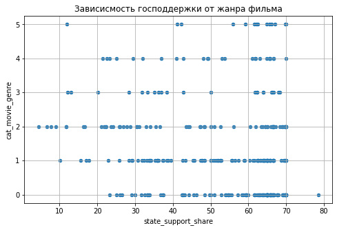

```python
data_st_sup.plot(kind='scatter', x='state_support_share', y='cat_movie_genre', grid=True, title='Зависисмость господдержки от жанра фильма', figsize=(8,5));
```

```python
data_st_sup['cat_movie_genre'].corr(data_st_sup['state_support_share'])
```

```
-0.1338895999866057
```

Посмотрим зависимость от года выпуска в прокат:

```python
pd.pivot_table(data_st_sup, columns='movie_genre_new', values='state_support_share', index='show_year').fillna(0).reset_index()
```

| movie_genre_new | show_year | боевик | военный | детектив | драма | другой | комедия |
| --- | --- | --- | --- | --- | --- | --- | --- |
| 0 | 2013 | 0.000000 | 0.000000 | 0.000 | 33.370000 | 0.000000 | 61.270000 |
| 1 | 2014 | 0.000000 | 0.000000 | 70.000 | 58.834286 | 39.620000 | 45.352500 |
| 2 | 2015 | 39.906667 | 49.311667 | 54.032 | 57.821429 | 50.879286 | 50.664583 |
| 3 | 2016 | 53.770000 | 37.035000 | 63.540 | 62.207500 | 52.136923 | 54.974118 |
| 4 | 2017 | 55.287500 | 62.220000 | 0.000 | 58.805556 | 32.150000 | 48.346875 |
| 5 | 2018 | 48.390000 | 43.768333 | 53.625 | 55.430000 | 49.294444 | 49.734615 |
| 6 | 2019 | 47.920000 | 51.832000 | 56.440 | 54.321500 | 42.881176 | 51.458667 |

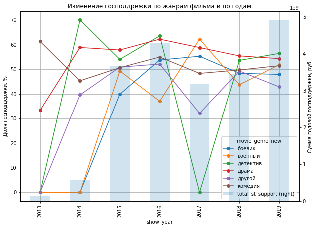

```python
ax = pd.pivot_table(data_st_sup, columns='movie_genre_new', values='state_support_share', index='show_year').fillna(0).reset_index().plot(x='show_year',
y=['боевик','военный', 'детектив',	'драма', 'другой', 'комедия'], title='Изменение господдрежки по жанрам фильма и по годам',figsize=(10,7), xlabel='Годы выпуска фильмов', ylabel='Доля господдержки, %',style='o-',use_index=False)
data['total_st_support'] = data['refundable_support'] + data['nonrefundable_support']
pd.pivot_table(data, index='show_year', values='total_st_support', aggfunc=sum).reset_index().tail(7).plot(kind='bar', ax=ax, x='show_year', y='total_st_support', secondary_y=True, alpha=0.2, grid=True)
ax.right_ax.set_ylabel('Сумма годовой господдержки, руб.');
```

Коэффициент корряляции показывает отсутствие связи между жанром фильма и господдержкой, что подтверждает график изменения доли поддержки по годам - видно, что все жанры имеют господдержку в районе 40% - 60%. Видно, что в 2017 году произошел провал в поддержке всех жаноров, за исключением военных фильмов и боевиков - в 2017 сумма господдержки была снижена(на графике столбцы светло-голубого цвета). До 2019 был разброс в поддержке того или инрго жанра, но к 2019 все жанры стали поддерживаться примерно в одних пропорциях в районе 50%.

### 4.8. Связь сборов от показа и господдержки

Посмотрим, какие связи могут быть у сборов от показа фильмов и господдержки:

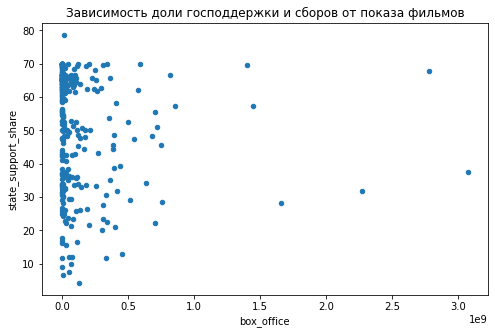

```python
data_st_sup.plot(kind='scatter', x='box_office', y='state_support_share', figsize=(8,5), title='Зависимость доли господдержки и сборов от показа фильмов');
```

```python
data_st_sup['box_office'].corr(data['state_support_share'])
```

```
-0.11559813665948603
```

Связи нет

Посмотрим, окупаются ли фильмы с господдержкой:

```python
round(data_st_sup['box_office'].mean() - data_st_sup['budget'].mean(), 2)
```

```
-1888940.22
```

Мы видим, что в среднем сборы фильмов меньше, чем вложенный бюджет, т.е фильмы с господдрежкой не окупаются

Сравним фильмы с господдержкой и без господдержки:

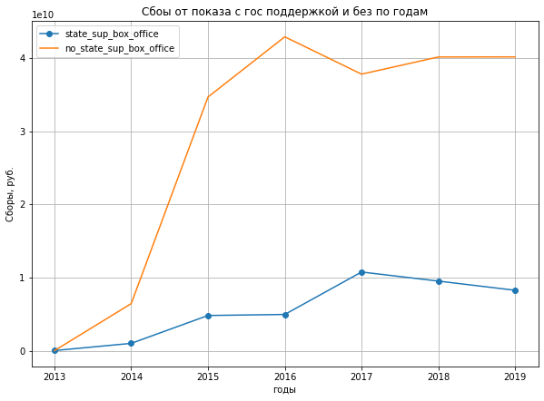

```python
s1 = pd.pivot_table(data_st_sup, index='show_year', values='box_office', aggfunc='sum').reset_index()
s1.columns = ['show_year','state_sup_box_office']
ax = s1.plot(x='show_year',y='state_sup_box_office', style='o-', grid=True, figsize=(10,7))
s2 = data.query('state_support_share < 0').pivot_table(index='show_year', values='box_office', aggfunc='sum').reset_index().tail(7)
s2.columns = ['show_year','no_state_sup_box_office']
s2.plot(x='show_year',y='no_state_sup_box_office', ax=ax, title='Сбоы от показа с гос поддержкой и без по годам', xlabel='годы', ylabel='Сборы, руб.', grid=True);
```

### 4.9. Связь года выпуска в прокат и господдержки

Закодируем год выпуска:

```python
data_st_sup['cat_show_year'] = pd.Categorical(data_st_sup['show_year'], data_st_sup['show_year'].unique()).codes
data_st_sup['cat_show_year'] = data_st_sup['cat_show_year'].astype('category').cat.as_ordered()
```

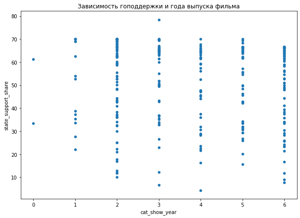

```python
data_st_sup.plot(kind='scatter', x='cat_show_year', y='state_support_share', title='Зависимость гоподдержки и года выпуска фильма', figsize=(10,7));
```

```python
data_st_sup['cat_show_year'].corr(data_st_sup['state_support_share'])
```

```
-0.07310684682641214
```

Корреляция показывает отсутствие связи

Посмотрим как распределялась господдержка по годам:

```python
data_st_sup['total_st_support'] = data_st_sup['refundable_support'] + data_st_sup['nonrefundable_support']
```

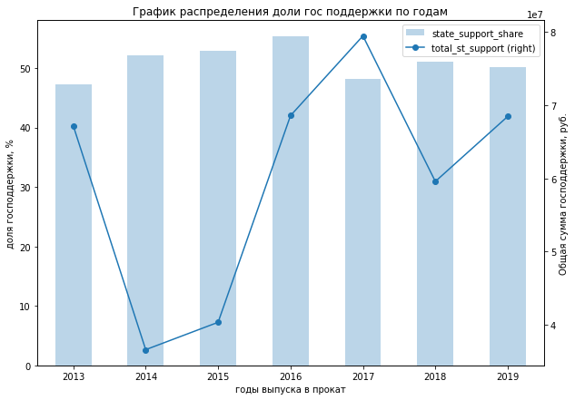

```python
ax =data_st_sup.pivot_table(index='show_year', values='state_support_share').reset_index().plot(kind='bar', x='show_year', y='state_support_share',figsize=(10,7),
xlabel='годы выпуска в прокат', ylabel='доля господдержки, %', title='График распределения доли гос поддержки по годам', alpha=0.3);
data_st_sup.pivot_table(index='show_year', values='total_st_support').reset_index().plot(ax=ax, x='show_year', y='total_st_support', secondary_y=True, use_index=False,style='o-')
ax.right_ax.set_ylabel('Общая сумма господдержки, руб.');
```

На графике мы видим, что колебания суммы господдержки по годам имеют место, особенно это было в начале периода(2013-2016), когда колебания были значительными. В последующие годы колебания, сократились. Если говорить про уровень поддержки втечение всего периода, то она сильно не изменялась и была примерно на уровне 50%, что и отразилось в коэффициенте корреляции (выше).

### 4.10. Связь страны производства фильма и господдержки

```python
data_st_sup['production_country'].unique()
```

```
array(['Россия', 'Латвия, Россия, Франция', 'Россия, Украина',
       'Италия, Россия', 'Польша, Россия, Украина',
       'Великобритания, Россия, ФРГ', 'Россия, ФРГ', 'Армения, Россия',
       'Россия, Словакия, Чехия', 'Латвия, Россия, Чехия',
       'Казахстан, Китай, Польша, Россия, ФРГ', 'Россия, Сербия',
       'Грузия, Россия', 'Китай, Россия', 'Бельгия, Россия, Финляндия'],
      dtype=object)
```

```python
len(data_st_sup['production_country'].unique())
```

```
15
```

```python
data_st_sup['production_country'].value_counts()
```

```
Россия                                   299
Италия, Россия                             2
Россия, ФРГ                                2
Россия, Украина                            1
Казахстан, Китай, Польша, Россия, ФРГ      1
Китай, Россия                              1
Бельгия, Россия, Финляндия                 1
Россия, Сербия                             1
Латвия, Россия, Франция                    1
Латвия, Россия, Чехия                      1
Польша, Россия, Украина                    1
Армения, Россия                            1
Грузия, Россия                             1
Великобритания, Россия, ФРГ                1
Россия, Словакия, Чехия                    1
Name: production_country, dtype: int64
```

### 4.11. Связь источника финансирования и господдержки

Посмотрим какой источник финансирования больше участвовал в господдержке:

```python
data_st_sup['financing_source'].value_counts()
```

```
Министерство культуры               163
Фонд кино                           131
Министерство культуры, Фонд кино     21
Name: financing_source, dtype: int64
```

Лидер по кол-ву поддержанных фильмов - Министерство культуры. Посмотрим, что по суммам поддержки.

```python
pt1 = pd.pivot_table(data_st_sup, index='financing_source', values=['state_support_share', 'total_st_support', 'title','ratings'], aggfunc={'state_support_share':'mean', 'total_st_support':'mean', 'title':'count','ratings':'mean'})
pt1.columns = ['mean_ratings','mean_state_support_share','movie_qty','mean_total_st_support']
pt1
```

| financing_source | mean_ratings | mean_state_support_share | movie_qty | mean_total_st_support |
| --- | --- | --- | --- | --- |
| Министерство культуры | 5.636196 | 52.965276 | 163 | 2.963596e+07 |
| Министерство культуры, Фонд кино | 6.123810 | 54.128095 | 21 | 5.535387e+07 |
| Фонд кино | 5.689313 | 49.829618 | 131 | 9.782921e+07 |

Построим pie chart для визуализации долей участия каждого источника финансирования в господдержке:

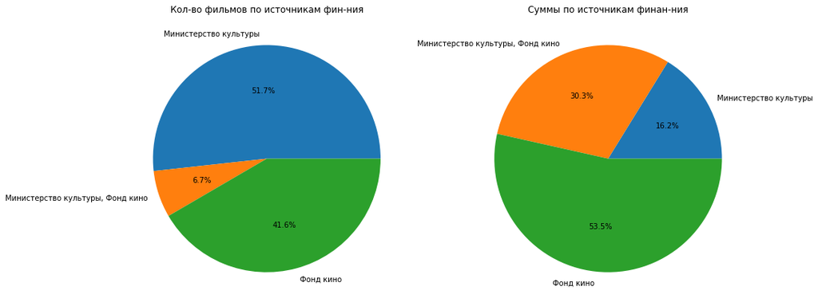

```python
ax = plt.subplot(121)
pt1.plot(kind='pie', y='movie_qty',ax=ax, autopct='%1.1f%%', figsize=(15,10), legend=False, title='Кол-во фильмов по источникам фин-ния', label='');
ax = plt.subplot(122)
pt1.plot(kind='pie', y='mean_total_st_support',ax=ax, autopct='%1.1f%%', legend=False, title='Суммы по источникам финан-ния',label='');
```

## 5.Общие выводы

В процессе работы были проведены следующие мероприятия:

1. Объеденены два дата фрейма в один
2. Новый дата фрейм проверен на дубликаты
3. Обработаны столбцы дата фрейма на предмет пропущенных значений, дубликатов в столбцах, форматирование данных в столбцах
4. Конвертирование столбцов в соответствующий сущности столбца формат данных
5. Добавлены необходимык для дальнейшего анализа данных столбцы
6. Проанализированы следующие свзи:
   - выход фильмов по годам
   - доля фильмов со сборами от проката больше нуля к общему кол-ву вышедших фильмов
   - доля фильмов со сборами от проката больше нуля к общему кол-ву вышедших фимльмов по годам
   - сборы от показа фильмов - среднее, медиана, изменения по годам
   - влияние возрастных ограничений на сборы от показа фильмов
7. Проанализированы фильмы с господдержкой на предмет наличия связи господдержки и:
   - тип фильма
   - студия производства фильма
   - режисер фильма
   - продюсер
   - рейтинг фильма
   - возрастные ограничения
   - жанр фильма
   - сборы от показов
   - год выпуска фильма
   - страны производства
   - источника финансирования

В ходе анализа были выявлены следующие тенденции:

1. начиная с 2012 года кол-во фильмов выходящих в прокат постоянно увеличивалось, исключение 2017 год (провал)
2. доля фильмов с указание данных о сборах за прокат составляет 42%
3. эта доля в периодс 2010 по 2014 была очень низкой - 22%, с 2015 по 2019 доля выросла и стала 62 %
4. Максиммальные сборы с учетом возрастных ограничений получали фильмы "16+", но при оценке удельных сборов (сборы на 1 фильм) оказалось, что более популярными оказались две возрастных категории: "6+" и "12+", что вполне логично, т.к. вместе с детьми на фильмы идут их родители, что увеличивает сборы от проката в разы(кол-во родителей) При анализе фильмов с господдержкой получили следующие результаты:
5. Тип фильмом пользующийся наибольшей господдержкой - художественный
6. Студии снимающие много фильмов с господдержкой получают ретинги за снятые фильмы выше, чем за фильмы без господдержки. Студии снимающие много фильмов с господдержкой также много снимают и без гос поддержки, что говорит об уверенной, многолетней работе этих студий, в то время как студии снимающие по 1 -2 фильма с господдержкой могут неснять больше ни одного фильма - студии однодневки.
7. В случае с режисером здесь средний рейтинг фмльмов с господдеркой приктически такой же как и без господдержки, что говорит о том, что режисеры заботятся о своей репутации
8. Такая же ситуация и с продюсерами, уровень их работы с господдержкой также высок , как и без господдержки
9. С точки зрения возрастных ограничений наибольшей господдержкой ползуютяс фильмы с ограничениями "12+" и "16+", это показывает на желание привлечь к просмотру максимальнй объем активной аудитории зрителей и их родителей.
10. Средний ретинг фильмов с господдержкой с 2017 года значительно выше среднего рейнга фильмов без господдержки, видно определенное влияние госорганов устаналивающих определнные требования при финансировании фильмов
11. С точки зрения жанра, наиболее популярными при госфинансироы=вании являются 5 категорий: драма, комедия, боевик, военный, детектив, которые имеют в среднем по 50% господдержки от общего бюджета фильма
12. Сборы от показа фильмов с господдержкой в целом низкие и не позволяют фильмам окупиться. В целом сравнивая сборы от проката фильмов с гос поддержкой и без господдержки мы обнаружили значительной отставание сборов от фильмов с господдержкой более чем в 4 раза в сравнении со сбрами от фильмов без господдержки. Фильмы с господдержкой не пользуются большой популярностью у зрителей, хотя те кто их посмотрел оценивают их высоко.
13. В годовом распределении господдержка в период с 2013 по 2019 годы, имела провал в 2014-2015 годах, с последующим аосстановлением в 2016 и далее.
14. При анализе стран, которые участвовали в производстве фильмов с господдержкой, было выявлено, что преимущественно поддержку получали фильмы произведенные в России - 95% и с небольшим добавлением фильмов снятых совместно с другими странами - 5%
15. Источниками финансирования являются Министерство культуры и Фонд кино, также естьфильмы с их взаимным участием. Больше всего фильмов было профинансировано Фондом кино (по суммам финансирования), а по кол-ву Минестерством культуры.

В ходе исследования наша гипотеза о популярности фильмов снимаемых с участием государства не подтвердилась - фильмы без господдержки более популярны среди зрителей